# Total solved problems with problems before starting github

```cpp

{ %raw % }

[1. n! 끝자리 0의 개수]

- n!을 할 때 인수 5가 몇 개 들어가는지 세면됨

ex) n=30 : 5, 10, 15 20, 25=(5x5), 30 이므로 6개.

[2. 인접하지 않은 인덱스만 골라서 원소 합 최대 구하기 – House robber]

- DP로 푸는 거임. 배열하나 설정하고, 해당 배열에 max(현재인덱스 + 2번째 전 인덱스, 1번째 전인덱스)를 하면서, 계속 더해나가면 됨.

int rob(vector<int>& nums) {

if(nums.empty() || nums.size()==0) return 0;

if(nums.size()==1) return nums[0];

int prev_1=nums[1];

int prev_2=nums[0];

int cur;

for(int i=2;i<nums.size();i++){

if(nums[i]+prev_2>prev_1){

cur=prev_1;

prev_1=nums[i]+prev_2;

prev_2=max(cur,prev_2);

}

else

prev_2=prev_1;

}

return max(prev_1,prev_2);

}

[3. 이진수 스트링의 합]

- 스트링을 인트로 변환하려면 atoi(s.c_str); 을 사용하면 됨.

- 인트를 바이너리 스트링으로 출력하려면 biset 라이브러리를 이용하면 됨.

ex) biset<셋의 크기>(인트 변수).to_string();

- 또는 answer = sum%2; sum/=2 를 한후 얻은 문자열을 reverse하면 됨.

- 이 문제는 각 스트링의 오른쪽 끝부터 시작하여 carry값을 유지하며 진행함.

즉, 둘다 1이었을 경우 합은 2 인데, 2%2==0 이므로, 해당 위치에는 0을 대입하고 캐리 값은 2 /1 = 1을 가지고 올라감. 그럼으로써, 캐리가 될 수 있도록 함.

string addBinary(string a, string b) {

int i=a.size()-1;

int j=b.size()-1;

int cur=0;

string answer;

while(i>=0 || j>=0|| cur!=0){

if(i>=0){

cur+=a[i]=='0'?0:1;

i--;

}

if(j>=0){

cur+=b[j]=='0'?0:1;

j--;

}

answer+=((cur%2)==0?'0':'1');

cur/=2;

}

reverse(answer.begin(),answer.end()); //이렇게 해주는 것이 O(n)으로 풀수있는 방법임.

return answer;

}

[4. 배열의 각 원소들을 연이어서 수를 만들 때, 그 수의 +1을 리턴하는 문제 – Plus One]

- 즉, [4,3,2,1] 이면 [4,3,2,2]를 리턴하는 문제, 왜냐하면 4321+1=4322

수의 범위가 크지 않다면 아래 방법처럼 간단한 덧셈과 인트 -> 스트링 -> 벡터변환으로 풀 수 있음.

vector<int> plusOne(vector<int>& digits) {

int answer=digits[0];

for(int i=1;i<digits.size();i++){

answer=answer*10+digits[i];

}

answer++;

string temp=to_string(answer);

vector<int> ret;

for(int i=0;i<temp.size();i++){

ret.push_back(temp[i]-48);

}

return ret;

}

그러나 수의 범위가 크다면, 덧셈을 이용할 수 없음. 아래 방법을 이용하면 됨.

vector<int> plusOne(vector<int>& digits) {

vector<int>::reverse_iterator iter=digits.rbegin();

//rbegin 하려면 reverse_iterator 라고 명시해줘야한다.

vector<int> answer;

int carry=1;

for(;iter!=digits.rend();iter++){

if(carry+*iter>=10){

carry=1;

answer.push_back(0);

}

else{

answer.push_back(*iter+carry);

carry=0;

}

}

// 인풋이 9 였을 때, answer에 10 이 들어가야되는데 0 만들어감.

// 이런 경우른 대비해서 끝났을 때 carry가 1이면 1을 한번더 push 해줌

if(carry==1)

answer.push_back(1);

reverse(answer.begin(),answer.end());

return answer;

}

[4. 해당 수가 power of prime인지 확인하는 문제]

- 사실 power of three 문제였는데, 3도 소수이므로 동일하게 풀 수 있다.

- 3의 제곱들 중 최댓 값을 안다면(1162261467, Math.log(0x7fffffff)) 해당 수가 3으로 나누어지면 power of three이다.

- 마찬가지로 다른 소수의 제곱들 중 최댓 값을 알면 풀 수 있다.

[5. 옆 사람과 가장 멀리 떨어져 앉는 문제]

- 모든 인덱스에 대해서 나의 오른쪽 사람과의 거리를 right 배열에 저장하고, 왼쪽 사람과의 거리를 left에 저장한다. 그 후 두 배열의 같은 인덱스에 대해서 min값을 구하고, 최종적으로 구해진 배열의 max값을 리턴하면 된다.

- 이때 양쪽 끝에는 사람이 없는 것으로 간주한다. 이것 때문에 나의 알고리즘이 속도가 많이 느려졌다. 이것을 처리하려고 count를 사용했는데, 이때 마지막 자리와 끝 자리와의 거리가 구해진다면, 그 사이의 거리는 min처리에서 제대로 처리되므로 상관 없다.

-90.24%의 속도가 나왔다.

int alloc_right(int* cur, vector<int>& seats,int index,int count){

if(index>=seats.size()) return count+1;

if(seats[index]==1) return 1;

cur[index]=alloc_right(cur,seats,index+1,count+1);

return cur[index]+1;

}

int alloc_left(int* cur, vector<int>& seats,int index,int count){

if(index<0) return count+1;

if(seats[index]==1) return 1;

cur[index]=alloc_left(cur,seats,index-1,count+1);

return cur[index]+1;

}

int maxDistToClosest(vector<int>& seats) {

int* left=new int[seats.size()]{0,};

int* right=new int[seats.size()]{0,};

for(int i=0, j=0;i<seats.size();i++){

if(seats[i]==1) continue;

j=i;

i=i+alloc_right(right,seats,j,0)-1;

}

for(int i=seats.size()-1,j=i;i>=0;i--){

if(seats[i]==1) continue;

j=i;

i=i-alloc_left(left,seats,j,0)+1;

}

vector<int> answer;

for(int i=0;i<seats.size();i++){

answer.push_back(min(left[i],right[i]));

}

int maximum=INT_MIN;

for(int i=0;i<answer.size();i++)

maximum=max(maximum,answer[i]);

> return maximum;

}

[6. 큐로 스택 구현하기]

- 큐는 항상 front에서 pop하기 때문에, stack처럼 LIFO로 pop 하려면, pop할 때 queue.size()-1만큼 큐 앞에 원소를 지워서 뒤에 붙여준 후, 마지막에 pop을 해야 됨. 이때 C++ 에서는 pop을 하면 원소가 지워지기만 하고 void 가 return 되므로, queue.front() 로 먼저 해당 원소를 저장해 주어야 함.

queue<int> Que;

/** Push element x onto stack. */

void push(int x) {

Que.push(x);

}

/** Removes the element on top of the stack and returns that element. */

int pop() {

int a;

for(int i=0;i<Que.size()-1;i++){

Que.push(Que.front());

Que.pop();

}

a=Que.front();

Que.pop();

return a;

}

/** Get the top element. */

int top() {

return Que.back();

}

/** Returns whether the stack is empty. */

bool empty() {

return Que.empty();

}

[7. 균형트리인지 확인하기]

-postOrder로 트리를 탐색하는 데, 이때 재귀로 각 트리의 왼쪽 서브트리와 오른쪽 서브트리의 높이 중 큰 값을 취하여 리턴해주고, 만약 왼쪽, 오른쪽 서브트리의 높이차가 1이상이면 flag=false로 하고, 아니면 falg=true인 상태로 놔둠.

bool flag=true;

int postOrder(TreeNode* root){

if(!root) return 0;

int left=0,right=0;

left+=postOrder(root->left);

right+=postOrder(root->right);

if(abs(left-right)>1)

flag=false;

return max(left,right)+1;

}

bool isBalanced(TreeNode* root) {

postOrder(root);

return flag;

}

[8. License key Formatting – 주어진 K에 대해서 dash 사이에 K개의 문자를 배치하는 문제]

- 문자열 전체를 대문자로 바꾸기 위해서는 std::transform(S.begin(),S.end(),S.begin(), ::toupper)를 하면 된다.

- 문자열 끝에서부터 시작하여 dash를 제외한 alphanumeric의 개수를 count로 세주고, given K만큼 세어졌을 때, dash를 추가한다.

- 또한 문자열 맨 처음의 연속된 dash를 방지하기 위하여, dash가 아닌 제일 첫번째 문자의 인덱스를 문자열 시작점으로 한다.

string licenseKeyFormatting(string S, int K) {

string answer;

int count=1;

int begin=0;

while(S[begin]=='-') begin++; // 맨 앞에 연이은 dash를 방지함.

for(int i=S.size()-1;i>=begin;i--){

if(count%(K+1)==0){

answer+='-';

count=1;

i++; // K개 만큼 센후 dash추가하려는 데, 그 원소가 dash가 아닐 경우를 대비.

continue;

}

if(S[i]!='-'){

answer+=S[i];

count++;

}

}

std::transform(answer.begin(),answer.end(),answer.begin(),::toupper);

reverse(answer.begin(),answer.end());

return answer;

}

[9. Find Pivot Index – 인덱스를 기준으로 왼쪽과 오른쪽 원소들의 합이 같은 인덱스(pivot)을 찾는문제]

int pivotIndex(vector<int>& nums) {

nums.push_back(0);

int pivot=0;

int left=0;

int right=0;

for(int i=1;i<nums.size();i++)

right+=nums[i];

while(pivot<nums.size()-1){

if(left==right)

break;

left+=nums[pivot];

right-=nums[pivot+1];

pivot++;

}

return pivot==nums.size()-1? -1 : pivot;

}

[10. power of two – 주어진 수가 2의 제곱 꼴인지 확인하는 문제]

- 비트연산을 이용하여 푼다. 2의 제곱들은 1000, 0100, 0010, 0001 등 비트형태에서 1을 하나 가지고 있다. 이때 2의 제곱들 -1은 0111, 0011, 0001, 0000 등 2의 제곱들보다 한자리 낮은 수부터 1로 가득 차있다.

-그러므로 n&(n-1)==0 이면 2의 제곱이다.

bool isPowerOfTwo(int n) {

return n>0 && (n&(n-1))==0 ;

}

[11. Reverse Vowels of a String – 모음 위치를 반대 순서로 바꾸는 문제]

- 한번 훑으면서 모음을 벡터에 저장하고, 그 모음의 인덱스를 다른 벡터에 저장한 후, 인덱스의 역순에 따라서 모음을 넣어주면 됨.

-주의할 점은 vector가 비었을 때, vec.back()을 호출하면 heap overflow 에러가 발생한다는 것임.

if(s.size()<2)

return s;

vector<char> table;

vector<int> index;

for(int i=0; i<s.size();i++){

if(s[i]=='a'||s[i]=='e'||s[i]=='i'||s[i]=='o'||s[i]=='u'||

s[i]=='A'||s[i]=='E'||s[i]=='I'||s[i]=='O'||s[i]=='U'){

table.push_back(s[i]);

index.push_back(i);

}

}

reverse(index.begin(),index.end());

string answer;

int i=0;

while(i<s.size()){

if(!index.empty()&&i==index.back()){

answer+=table.back();

table.pop_back();

index.pop_back();

}

else{

answer+=s[i];

}

i++;

}

return answer;

[12. **Second Minimum Node In a Binary Tree – 두개의 자식 중 최소 값이 부모가 되는 이진트리에서 두번째 최소값 찾는 문제]**

- 전부 순회를 하되, 두번째 값을 LONG_MAX로 초기화 해놓고, 순회할때마다 해당 노드의 value가 최소값(루트값) 보다 크고, 현재의 second값보다 작은지 확인하여, 조건이 만족하면 second=value를 하면 됨.

int first;

long second;

void search(TreeNode* root){

if(!root) return;

if(first<root->val && root->val<second)

second=root->val;

search(root->left);

search(root->right);

}

int findSecondMinimumValue(TreeNode* root) {

first=root->val;

second=LONG_MAX;

search(root);

return second==LONG_MAX? -1: second;

}

[13. **Convert a Number to Hexadecimal – 십진수를 16진수 스트링으로 바꾸는 문제]**

- 스트링하나에 0부터 f까지 지정해 준 후, 주어진 십진수를 16으로 % 연산을 하여 해당 인덱스의 값을 결과 값에 더해나간다.

- 마지막에 해당 값을 reverse해주면 된다.

- 이때 -를 다루기 위해서는 unsigned int 로 인풋값을 재 지정해준다. 그럴경우 -1이 unsigned int의 최대값이 된다.

string toHex(int num) {

unsigned int n=num;

string table="0123456789abcdef";

string answer;

do{

answer+=table[n%16];

n/=16;

}while(n);

return {answer.rbegin(),answer.rend()};

}

[14 **Quad Tree Intersection - 4개의 자식이 있는 두개의 트리에 대하여 각 자식끼리의 OR연산을 하는 문제]**

**-** 난 아래처럼 최종 모습이 4개의 자식을 가진 노드를 만드는 건줄 알았는 데, 아닌 듯?

bool search(Node* root){

if(root->isLeaf) return root->val;

return search(root->topLeft)||search(root->topRight)||search(root->bottomLeft)||search(root->bottomRight);

}

Node* intersect(Node* quadTree1, Node* quadTree2) {

bool one=search(quadTree1->topLeft)||search(quadTree2->topLeft);

bool two=search(quadTree1->topRight)||search(quadTree2->topRight);

bool three=search(quadTree1->bottomLeft)||search(quadTree2->bottomLeft);

bool four=search(quadTree1->bottomRight)||search(quadTree2->bottomRight);

Node* answer=new Node();

answer->val = true;

answer-> isLeaf = false;

answer->topLeft = new Node(one,true,nullptr,nullptr,nullptr,nullptr);

answer->topRight = new Node(two,true,nullptr,nullptr,nullptr,nullptr);

answer->bottomLeft = new Node(three,true,nullptr,nullptr,nullptr,nullptr);

answer->bottomRight = new Node(four,true,nullptr,nullptr,nullptr,nullptr);

return answer;

}

- 마지막에 4개의 자식이 모두 같은 boolean 값을 가지면 하나로 합쳐줘야함.

- 아래 2개의 방법은 다른 사람들이 푼 것으로, 읽으니까 이해할 수 있었음.

Node* intersect(Node* quadTree1, Node* quadTree2) {

if(quadTree1->isLeaf && quadTree1->val) return quadTree1;

if(quadTree2->isLeaf && quadTree2->val) return quadTree2;

if(quadTree1->isLeaf && !quadTree1->val) return quadTree2;

if(quadTree2->isLeaf && !quadTree2->val) return quadTree1;

auto tl = intersect(quadTree1->topLeft, quadTree2->topLeft);

auto tr = intersect(quadTree1->topRight, quadTree2->topRight);

auto bl = intersect(quadTree1->bottomLeft, quadTree2->bottomLeft);

auto br = intersect(quadTree1->bottomRight, quadTree2->bottomRight);

if(tl->val == tr->val && tl->val == bl->val && tl->val == br->val && tl->isLeaf && tr->isLeaf && bl->isLeaf && br->isLeaf)

return new Node(tl->val, true, nullptr, nullptr, nullptr, nullptr);

else

return new Node(false, false, tl, tr, bl, br);

}

Node* intersect(Node* quadTree1, Node* quadTree2)

{

// if a is leaf+true, choose a.

// if b is leaf+false, choose a.

if (quadTree1->isLeaf && quadTree1->val == true ||

quadTree2->isLeaf && quadTree2->val == false)

return quadTree1;

// if b is leaf+true, choose b.

// if a is leaf+false, choose b;

if (quadTree2->isLeaf && quadTree2->val == true ||

quadTree1->isLeaf && quadTree1->val == false)

return quadTree2;

// intersect.

Node* ret = new Node (false, false,

intersect (quadTree1->topLeft, quadTree2->topLeft),

intersect (quadTree1->topRight, quadTree2->topRight),

intersect (quadTree1->bottomLeft, quadTree2->bottomLeft),

intersect (quadTree1->bottomRight, quadTree2->bottomRight));

// merge if all children are leaves and have the same value.

if (ret->topLeft->val == ret->topRight->val && ret->topLeft->val == ret->bottomLeft->val &&

ret->topLeft->val == ret->bottomRight->val &&

ret->topLeft->isLeaf && ret->topRight->isLeaf && ret->bottomLeft->isLeaf && ret->bottomRight->isLeaf)

{

ret->val = ret->topLeft->val;

ret->isLeaf = true;

ret->topLeft = ret->topRight = ret->bottomLeft = ret->bottomRight = NULL;

}

// done.

return ret;

}

[15. **Most Common Word – 문자열에서 금지된 단어를 제외하고 가장 많이 등장하는 단어를 찾아내는 문제]**

- map을 이용해서 각 단어마다 등장횟수를 센 후, map을 순회하면서 해당 단어가 banned되어 있지 않고, 현재의 단어보다 많이 등장하였다면 answer를 바꾸어 줌.

- 문자열을 소문자로 바꾸기 위해서는 transfrom(s.begin(),s.end(),s.begin(),::tolower)를 하면 됨.

- vector안에서 해당 아이템, 또는 문자열을 찾기 위해서는 find(vec.begin(),vec.end(),item)을 하면 해당 item의 iterator가 반환됨. 그러므로 !=vec.end() 를 조건으로 주면 해당 아이템이 없으면 false, 있으면 true가 됨.

std::transform(paragraph.begin(),paragraph.end(),paragraph.begin(),::tolower);

unordered_map<string,int> table;

string temp;

for(int i=0;i<paragraph.size();i++){

if('a'<=paragraph[i] && paragraph[i]<='z')

temp+=paragraph[i];

else{

table[temp]++;

temp="";

}

}

table[temp]++; //마지막에 고려되지 못한 단어를 위해서

unordered_map<string,int>::iterator iter=table.begin();

string answer="";

int count=0;

for(;iter!=table.end();iter++){

if(std::find(banned.begin(),banned.end(),iter->first)==banned.end()&&iter->second>count

&& 'a'<=iter->first[0] && iter->first[0]<='z'){// 해당 문자열이 banned이고, iter가 구두점이나 공백이 아니라면

answer=iter->first;

count=iter->second;

}

}

return answer;

}

[16. **Subtree of Another Tree – 트리 s가 트리 t를 서브트리로 가지고 있는지 확인하는 문제]**

**-** 이렇게 푸는게 맞는지 모르겠는데, 일단 오래걸렸음.

- 먼저 트리 t의 shape을 vector에 담고, 트리 s에서 트리 t의 root를 찾은 순간, 그때부터 트리 t와 같은 subtree구조를 가졌는지 확인하는 방식임.

bool answer=false;

vector<int> t_table;

int i;

int first;

void t_search(TreeNode* root){ //4, 1, min, min, 2, min, min

if(!root){

t_table.push_back(INT_MIN);

return;

}

t_table.push_back(root->val);

t_search(root->left);

t_search(root->right);

}

void s_search(TreeNode* root){

if(!root) return;

if(root->val==first){ //if tree t's root is found, then check whether the subtree is same with t

check(root);

}

if(answer==true)

return;

s_search(root->left);

s_search(root->right);

}

void check(TreeNode* root){

if(!root && t_table[i]==INT_MIN){

if(i==t_table.size()-1){

answer=true;

return;

}

i++;

return;

}

if((!root && t_table[i]!=INT_MIN) || ( root &&root->val !=t_table[i])){

i=0;

return;

}

i++;

check(root->left);

check(root->right);

}

bool isSubtree(TreeNode* s, TreeNode* t) {

t_search(t);

first=t->val;

i=0;

s_search(s);

return answer;

}

- 그리고 훨씬 좋은 solution을 봐버렸다.

class Solution {

public:

bool isSubtree(TreeNode* s, TreeNode* t) {

if(!s) return false;

if (isSame(s,t)) return true;

return isSubtree(s->left,t) || isSubtree(s->right,t);

}

bool isSame(TreeNode *s, TreeNode *t)

{

if (!s && !t) return true;

if (!s || !t) return false;

if (s->val != t->val) return false;

return isSame(s->left, t->left) && isSame(s->right, t->right);

}

};

[17. **Remove Duplicates from Sorted List – 링크드리스트에서 중복 원소 제거하는 문제]**

- Discussion 찾아보니까 new로 생성한거 아니면 dlete할 필요 없다는 거 같은데 잘 모르겠음.

- 일단 같은 원소가 아닐때까지 loop돌고 다른원소 발견하면 이전 원소의 맨 앞에거랑 연결해주는 방식으로 했음. 이것이 속도가 좀 빠름.

ListNode* deleteDuplicates(ListNode* head) {

ListNode* answer= head;

ListNode* temp;

int value;

while(head){

value=head->val;

temp=head;

while(temp->next && value==temp->next->val) temp=temp->next;

if(!temp->next){

head->next=nullptr;

head=head->next;

break;

}

else{

head->next=temp->next;

head=head->next;

}

}

return answer;

}

[18. **Add to Array-Form of Intege – 벡터로 정수가 주어지고, 또 다른 정수 K가 주어져서 두개를 더한 후 벡터모양을 리턴하는 문제]**

- 벡터를 일단 정수로 바꿔서 더할려고 했는데, 정수 값을 엄청 크게 줘서 안됨.

- 그래서 carry를 사용해서 풀었는 데, 내가봤는데도 너무 느린 효율을 가짐

- 참고로 K%10 은 마지막 숫자를 리턴해줌. K/10은 마지막 숫자를 제외한 숫자를 리턴함.

vector<int> addToArrayForm(vector<int>& A, int K) {

int cur=0;

int carry=0;

vector<int> answer;

for(int i=A.size()-1;i>=0;i--){

cur=A[i]+K%10+carry;

if(cur>=10) {

carry=1;

cur%=10;

}

else carry=0;

K/=10;

answer.push_back(cur);

}

while(K){ //A의 자릿수가 K보다 작은 경우를 cover함.

cur=K%10+carry;

if(cur>=10){

carry=1;

cur%=10;

}

else carry=0;

answer.push_back(cur);

K/=10;

}

if(carry==1) answer.push_back(1); //답이 1082 막 이런데 벡터에 082 이런거 까지만 들어가는 경우 cover함

return {answer.rbegin(),answer.rend()};

}

- 이거는 나랑 같은 방식인데 설명을 더 잘해놓음.

/* An important observation ---

1) num%10 gives us the last digit of a number

2) num = num/10 cuts off the last digit of the number

3) numVector.back() gives us the last digit of the number in vector form

4) numVector.pop_back() cuts off the last digit of the number in vector form

5) The extra space required can be reduced by overwriting the first vector.

*/

class Solution

{

public:

vector<int> addToArrayForm(vector<int>& a, int k);

};

/* Returns the sum of 2 numbers in vector form */

vector<int> Solution :: addToArrayForm(vector<int>& a, int k)

{

// Get the length of the first number

int n = a.size();

// Vector to store the answer

vector<int> answer;

/* Start adding both the numbers from the end */

int carry = 0;

// As long as one of the number exists, keep adding them

while(!a.empty() || k!=0)

{

// Get the last digits of both the numbers. If a vector has finished off, the last digit is zero

int lastDigit_1 = a.empty() ? 0 : a.back();

int lastDigit_2 = k%10;

// Sum up the digits and add the carry

int sum = lastDigit_1 + lastDigit_2 + carry;

answer.push_back(sum%10);

carry = sum/10;

// Remove the last digits of both the numbers

if(!a.empty()) a.pop_back();

k = k/10;

}

// If the carry is remaining, add it

if(carry!=0) answer.push_back(carry);

// Reverse the answer, since we were summing up from the end

reverse(answer.begin(), answer.end());

// Return the answer in vector format

return answer;

}

[19. **Long Pressed Name – 중복적으로 눌린 키보드 문자로 원래의 이름을 만들 수 있는지 확인하는 문제.]**

- 문제 설명하기가 힘들어서 원본을 붙여 넣음.

Your friend is typing his name into a keyboard. Sometimes, when typing a character c, the key might get *long pressed*, and the character will be typed 1 or more times.

You examine the typed characters of the keyboard. Return True if it is possible that it was your friends name, with some characters (possibly none) being long pressed.

- 두 문자열이 match 되면 pass, 아니면 long pressed인지 확인하여 그만큼 string typed를 진행시키고, 아니면 return false.

- while 문이 종료되었을 때, i가 name.size()보다 작으면, string typed의 character의 숫자가 모자른 것이므로 false.

bool isLongPressedName(string name, string typed) {

int i=0,j=0;

char prev=name[0];

while(j<typed.size()){

// if the two strings is matched.

if(name[i]==typed[j]){

prev=name[i];

i++;j++;

continue;

}

//if typed has been long pressed.

if(prev!=name[i] && prev==typed[j]){

while(prev==typed[j]) j++;

continue;

}

return false;

}

//if the type has not enough character.

return i>=name.size()? true : false;

}

[20. **Path Sum III – 주어진 트리의 노드들을 더하여 주어진 sum을 만들 수 있는 path가 몇 개인지 구하는 문제]**

- 두개의 재귀를 생각해야해서 어려운 문제임. 덕분에 좋은 공부가 되었음.

- 전수조사 밖에 답이없는 것 같음.

int search(TreeNode* root, int sum, int pre){

if(!root) return 0;

return (root->val+pre == sum) + search(root->left,sum,pre+root->val) + search(root->right,sum,pre+root->val);

}

int pathSum(TreeNode* root, int sum) {

if(!root) return 0;

return search(root,sum,0) + pathSum(root->left,sum)+pathSum(root->right,sum);

}

[21. **Find Smallest Letter Greater Than Target – 주어진 target보다 큰 가장 작은 character를 반환하는 문제]**

- 그냥 간단하게 target의 ascii code값 보다 큰 값이 나오면 return 해주는 것으로 했음, 끝날때까지 찾지 못하면, 첫번째 원소. 이거는 O(n)임.

char nextGreatestLetter(vector<char>& letters, char target) {

> if(letters[letters.size()-1]<=target) return letters[0];

> for(int i=0;i<letters.size();i++){

> if(target<letters[i])

> return letters[i];

> }

> return letters[0];

}

-이것을 이진탐색으로도 풀 수 있음.

char nextGreatestLetter(vector<char>& letters, char target) {

int left=0;

int right=letters.size()-1;

int mid;

while(left<=right){

mid=(right-left)/2+left; // to handle INT overflow.

if(mid==0){

if(letters[mid]>target) return letters[0];

else{

left=mid+1;

continue;

}

}

if(letters[mid-1]<=target && letters[mid]>target) return letters[mid];

else if(letters[mid]<=target)

left=mid+1;

else right=mid-1;

}

return letters[0];

}

- upper_bound를 사용한 풀이 방법도 있음. 이거 알아두자.

- upper_bound는 이진탐색 기반의 탐색 법임. 사용전 list가 정렬되어 있어야함.

- key값을 초과하는 가장 첫번째 원소의 반복자를 리턴함.

- upper_bound(vec.begin(),vec.end(),value)의 형식으로 사용함.

- lower_bound는 해당 value를 포함하여 이상인 값을 리턴함. 즉, lower는 이상, upper는 초과!

char nextGreatestLetter(vector<char>& letters, char target) {

vector<char>::iterator iter=upper_bound(letters.begin(),letters.end(),target);

return iter==letters.end() ? letters[0] : *iter;

}

p.s) 세상 많이 편해졌다.

[22. **Longest Harmonious Subsequence – max와 min의 차이가 정확히 1인 subsequence 찾는 문제]**

- 여기서 subsequence는 substring이 아니라, 조합될수 있는 모든 가지수임.

ex) apple의 subsequence는 a,ap,al,ae,app,apl,ape … 이런 식임.

- 이 문제는 map을 활용하여 2번의 for문을 쓰는게 관건이었음.

- 생각하기 쉽지 않아서 Discussion의 도움을 받음.

int findLHS(vector<int>& nums) {

unordered_map<int,int> table;

for(int i : nums){

table[i]++;

}

int answer=0;

unordered_map<int,int>::iterator iter=table.begin();

for(;iter!=table.end();iter++){

if(table.count(iter->first-1)>0)

answer=max(answer,iter->second+table[iter->first-1]);

}

return answer;

}

[23. **Longest Continuous Increasing Subsequence – 벡터 내 오름차순 부분배열 중 가장 긴 길이를 구하는 문제] 2020-01-26 7:30.**

- empty인 vector에 대해서 vec.empty()로 체크하는 것 보다 vec.size()==0 으로 체크하는 것이 훨씬 빠르다.

int findLengthOfLCIS(vector<int>& nums) {

if(nums.size()==0) return 0;

int count=1;

int answer=1;

int i=0;

while(i<nums.size()-1){

while(i+1<nums.size() && nums[i]<nums[i+1]){

count++;

i++;

}

answer=max(answer,count);

count=1;

i++;

}

return answer;

}

[24. **Symmetric Tree – 트리가 대칭 모양인지 구하는 문제]**

- 나는 left subtree와 right subtree를 preorder search를 통해서 vector에 각 value값을 저장하고, 마지막에 두개의 벡터가 같은 값을 가지는지 확인하였음.

- 이때 null node에 대해서는 INT_MIN을 대입함으로써, 모양을 기억함.

vector<int> left_tree;

vector<int> right_tree;

void leftSearch(TreeNode* root){

if(!root){

left_tree.push_back(INT_MIN);

return;

}

left_tree.push_back(root->val);

leftSearch(root->left);

leftSearch(root->right);

}

void rightSearch(TreeNode* root){

if(!root){

right_tree.push_back(INT_MIN);

return;

}

right_tree.push_back(root->val);

rightSearch(root->right);

rightSearch(root->left);

}

bool isSymmetric(TreeNode* root) {

if(!root) return true;

leftSearch(root->left);

rightSearch(root->right);

if(left_tree.size()!=right_tree.size())

return false;

for(int i=0;i<left_tree.size();i++)

if(left_tree[i]!=right_tree[i])

return false;

return true;

}

- Discussion의 방법인데, 좀 더 빠르고 간단함.

bool isSymmetric(TreeNode *root) {

if (!root) return true;

return helper(root->left, root->right);

}

bool helper(TreeNode* p, TreeNode* q) {

if (!p && !q) {

return true;

} else if (!p || !q) {

return false;

}

if (p->val != q->val) {

return false;

}

return helper(p->left,q->right) && helper(p->right, q->left);

}

[25. **Maximum Subarray – 최대부분배열문제] 2020-01-27 4:30 PM.**

- dp를 이용해서 푸는건데, dp 벡터에 현재 인덱스의 값과 바로 이전까지 구한 최대부분배열을 더하여 현재 인덱스 값보다 크면 그 값을 그 인덱스의 dp값으로 하는 방식임.

- O(n) solution인데, 떠올리기 쉽지 않음.  
int maxSubArray(vector<int>& nums) {

int maximum=nums[0];

vector<int> dp;

dp.push_back(nums[0]);

for(int i=1;i<nums.size();i++){

dp.push_back(max(nums[i],nums[i]+dp[i-1]));

maximum=max(maximum,dp[i]);

}

return maximum;

}

[26. **Base 7 – 주어진 수를 7진수 string으로 표현하는 문제]**

- 이게 인풋이 그냥 7이면 곱하기 10을 해도 7%7=0 이므로 자릿수가 올라가지 않아서, 처음부터 string으로 다루는 것이 포인트임.

string convertToBase7(int num) {

if(num==0)

return "0";

string base7;

int temp=num;

num=abs(num);

while(num){

base7+=to_string(num%7);

num/=7;

}

reverse(base7.begin(),base7.end());

return temp<0? '-'+base7 : base7;

}

[27. **Add Strings – 두개의 string으로 주어진 정수를 더하는 문제] 2020-01-27 5:45 PM**

- string 최대길이가 5100이므로 정수로 바꿔서 더할 수 없고, carry를 활용해야함.

- 더 짧게 짤 수 있을 것 같긴한데, 알고리즘은 대체로 나와 같을 것이라 예상됨.

string addStrings(string num1, string num2) {

int carry=0;

string answer;

int temp;

int i,j;

for(i=num1.size()-1,j=num2.size()-1;i>=0 && j>=0 ; i--,j--){

temp=(num1[i]-48)+(num2[j]-48)+carry;

answer+=to_string(temp%10);

if(temp>=10) carry=1;

else carry=0;

}

while(i>=0){

temp=(num1[i]-48+carry);

answer+=to_string(temp%10);

i--;

if(temp>=10) carry=1;

else carry=0;

}

while(j>=0){

temp=(num2[j]-48+carry);

answer+=to_string(temp%10);

j--;

if(temp>=10) carry=1;

else carry=0;

}

if(carry)

answer+=to_string(carry);

return {answer.rbegin(),answer.rend()};

}

[28. **Climbing Stairs – 계단을 한번에 1개나 2개씩 오를 수 있을 때, 특정 높이의 계단까지 가는 방법의 수를 구하는 문제] 2020-01-27 6:20**

**-** 간만에 DP를 풀어서 그런지, 피보나치임을 눈으로 보고도 알아채지 못 했음.

int climbStairs(int n) {

if(n<=2) return n;

int temp;

int prev=1;

int cur=2;

for(int i=3; i<=n;i++){

temp=cur;

cur=prev+cur;

prev=temp;

}

return cur;

}

[29. **Binary Watch – 손목시계에 들어온 LED의 개수로 표현할 수 있는 모든 시간을 구하는 문제] 2020-01-27 7:00**

- 이건 내가 못푸는 문제임. Discussion 보고도 한참 걸렸음.

- bitset을 이용하는 문제임. 어렵다.

- bitset<10> a으로 선언할 수 있는데, a에 자리수가 10개인 비트를 저장할 수 있다는 것이다.

이때 bitset<10>(3) a 로 선언하면, 10개의 비트에 대해서 십진수 3을 이진수로 표현하여 a에 저장해준다. 즉 0000 00011 이 된다.

- a.set() 을 하면 모든 bit이 1이되고, a.reset() 하면 0이 된다. a.set(3,true)로 하면 3+1인 4번 비트를 1로 설정한다.

- a.flip()을 하면 모든 비트를 반전하고, a.flip(3)을 하면 3+1인 4번 비트를 반전한다.

- a.to_string() 하면 전체 비트를 string화 시킨다.

- a[4], a.test[4] 처럼 배열처럼 접근할 수 있다.

- a.any()는 비트 중 하나라도 1이면 1을 반환하고, a.none()은 모두 0이어야만 1을 반환한다.

- a.test(n)은 n+1번째 비트가 1인지 0인지 검사한다.

vector<string> readBinaryWatch(int num) {

vector<string> answer;

for(int h=0;h<12;h++){

for(int m=0;m<60;m++){

if(bitset<10>(h).count()+bitset<10>(m).count()==num)

answer.push_back(to_string(h)+":"+(m<10? "0":"")+to_string(m));

}

}

return answer;

}

-이런걸 생각해 내는 사람들도 대단함.

[30. **Student Attendance Record I – 학생이 상을 받을 수 있는 출석률을 가졌는지 아닌지 판단하는 문제]**

- 간단한 문제임. if문을 여러 개 사용하면 됨.

- 결석이 2회이상이면 탈락이고, 3연속 지각을 하면 탈락임.

bool checkRecord(string s) {

bool absent=false;

int late=0;

for(int i=0;i<s.size();i++){

if(absent && s[i]=='A')

return false;

else if(s[i]=='A'){

absent=true;

late=0;

continue;

}

else if(late==2&&s[i]=='L')

return false;

else if(s[i]=='L'){

late++;

continue;

}

late=0;

}

return true;

}

**-** bit연산을 통해서 풀었음. 주어진 n과 1을 &연산을 하여 true면 count++를 함. 그 이후 n=n>>1을 하여 n==0일 때까지 loop를 돌림.

int hammingWeight(uint32_t n) {

int count=0;

while(n){

n&1? count++:count;

n=n>>1;

}

return count;

}

[32. **Pascal's Triangle II – 파스칼 트라이앵글의 특정 row의 원소를 구하는 문제]**

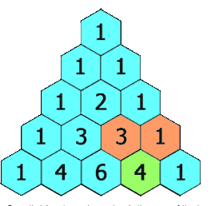

- 벡터 메모리 해제를 위해 vector<int>().swap(answer)를 이용하였다.

vector<int> getRow(int rowIndex) {

if(rowIndex==0) return {1};

vector<int> prev(2,1);

vector<int> answer;

vector<int> res=prev;

for(int i=0;i<rowIndex-1;i++){

answer.push_back(1);

for(int j=0;j<prev.size()-1;j++){

answer.push_back(prev[j]+prev[j+1]);

}

answer.push_back(1);

prev=answer;

res=answer;

answer.clear();

}

vector<int>().swap(prev); // deallocate prev

vector<int>().swap(answer);

return res;

}

- 다음 문장에 의거하여 더 빠르게 풀 수 있다.

*Based on math, the kth element for nth row is C(n, k) = n! / (k!*(n-k)!), then res[k] = res[n - k]*

*so the relationship between res[i] and res[i-1] is n! / (k!(n-k)!) / n! **/** ((k-1)!(n-k + 1)!) = (n - k + 1) / k;*

*Note that this solution is math derived from number of Combinations.*

*Each line of Pascal's Triangle is a full set of Combination number based on k .*

*comb(k,p) = k! /( p! *(k-p)!) = comb(k,k-p)*

*if p < k-p*

*comb(k,p) = comb(k,p-1) * (k-p+1) / p*

*Because :*

*comb(k,p) = [ k * (k-1) * (k-2) *... (k-p+1)] / [1 * 2 * 3 *...(p)]*

vector<int> getRow(int rowIndex) {

vector<int> answer(rowIndex+1,1);

for(int i=1;i<=(rowIndex+1)/2;i++){

answer[i]=answer[rowIndex-i]=(long)answer[i-1]*(long)(rowIndex-i+1)/i;

}

return answer;

}

[33. **Implement Queue using Stacks – 스택을 이용해 큐를 구현하는 문제] 2020-01-28 5:00**

- 스택을 2개 사용하여, push는 스택1에 push하고, pop이나 peek이 호출된 순간, 스택2가 비어있으면 스택1의 모든 원소를 pop하여 스택 2에 넣고, 스택 2의 top을 리턴한다. 스택2가 비어있지 않을 경우 그냥 스택 2의 탑을 리턴한다.

- 이때 pop 호출시 해당 top을 삭제하여 준다.

stack<int> stk1;

stack<int> stk2;

/** Push element x to the back of queue. */

void push(int x) {

stk1.push(x);

}

/** Removes the element from in front of queue and returns that element. */

int pop() {

if(!stk2.empty()){

int temp=stk2.top();

stk2.pop();

return temp;

}

while(!stk1.empty()){

stk2.push(stk1.top());

stk1.pop();

}

int temp=stk2.top();

stk2.pop();

return temp;

}

/** Get the front element. */

int peek() {

if(!stk2.empty())

return stk2.top();

while(!stk1.empty()){

stk2.push(stk1.top());

stk1.pop();

}

return stk2.top();

}

/** Returns whether the queue is empty. */

bool empty() {

if(stk1.empty() && stk2.empty())

return true;

return false;

}

[34. **Number of Equivalent Domino Pairs - 2차원 벡터에서 순서에 상관없이 동일한 원소를 가진 행벡터를 구하는 문제] 2020-01-28 5:20**

- 나는 일단 잘 안떠올라서 sort시키고 시작했음. sort 후 map의 키로서 pair<int,int>를 활용함.

- map의 키로서 pair를 사용할 경우 unordered_map은 사용 불가능함. 그래서 더 느린듯.

int numEquivDominoPairs(vector<vector<int>>& dominoes) {

for(int i=0;i<dominoes.size();i++)

sort(dominoes[i].begin(),dominoes[i].end());

map<pair<int,int>,int> table;

for(int i=0;i<dominoes.size();i++){

table[make_pair(dominoes[i][0],dominoes[i][1])]++;

}

map<pair<int,int>,int>::iterator iter=table.begin();

int answer=0;

for(;iter!=table.end();iter++)

answer+=(iter->second)*(iter->second -1)/2;

return answer;

}

- 다른 방법을 찾아봤는데, Discussion 에서 이런 신박한 방법이 있었음.

**Explanation**

You need to distinguish the different dominoes and count the same.

I did it in this way:  
f(domino) = min(d[0], d[1]) * 10 + max(d[0], d[1])  
For each domino d, calculate min(d[0], d[1]) * 10 + max(d[0], d[1])  
This will put the smaller number on the left and bigger one on the right (in decimal).  
So same number same domino, different number different domino.

Take the example from the problem:  
dominoes = [[1,2],[2,1],[3,4],[5,6]]  
now we transform it into [12,12,34,56].

int numEquivDominoPairs(vector<vector<int>>& dominoes) {

unordered_map<int, int> count;

int res = 0;

for (auto& d : dominoes) {

res += count[min(d[0], d[1]) * 10 + max(d[0], d[1])]++;

}

return res;

}

- 천재 xx들…

[35. **Maximum Product of Three Numbers – 벡터의 원소 중 3개를 골라 곱하였을 때의 최댓값을 구하는 문제] 2020-01-28 5:48**

- 최댓값은 벡터에 음수가 존재할 경우, 가장 작은 음수 2개와 가장 큰 양수 하나를 곱하거나, 가장 큰 양수 3개를 차례로 곱하는 2가지 방법만이 존재한다.

- 그러므로 가장 큰 양수 3개와, 가장 작은 음수 2개를 찾은 후 두개를 비교하면 된다.

int maximumProduct(vector<int>& nums) {

int max1=INT_MIN+2,max2=INT_MIN+1, max3=INT_MIN;

int min1=INT_MAX-1,min2=INT_MAX;

for(int i=0;i<nums.size();i++){

if(nums[i]>max1){

max3=max2;

max2=max1;

max1=nums[i];

}

else if(nums[i]>max2){

max3=max2;

max2=nums[i];

}

else if(nums[i]>max3) max3=nums[i];

if(nums[i]<min1){

min2=min1;

min1=nums[i];

}

else if(nums[i]<min2) min2=nums[i];

}

return max(max1*max2*max3,min1*min2*max1);

}

[36. **Pairs of Songs With Total Durations Divisible by 60 – 주어진 벡터에서 두 원소의 합이 60으로 나누어 떨어지는 원소 쌍의 개수를 구하는 문제] 2020-01-28 6:14**

- 일단 map을 이용하여, 60-원소값 즉, 해당 원소가 60으로 나누어떨어지기 위해서 더해져야 하는 값을 확인하고, 해당 값이 존재하면 answer에 더해준다.

- 이때 i<j인 쌍에서만 확인한다. 즉 중복된 두개의 원소쌍에 대해서는 한번만 연산한다는 것이 중요하다.

- table에는 key값으로 60을 가질 수 없기 때문에, time[i]==60일 경우 %60을 한번 더해줌으로써 table[0]을 검색하게 해준다.

int numPairsDivisibleBy60(vector<int>& time) {

unordered_map<int,int> table;

int answer=0;

for(int i=0;i<time.size();i++){

answer+=table[(60-(time[i]%60))%60]; // to handle when a time[i]==60, since there will be no value 60 in the table.

table[time[i]%60]++;

}

return answer;

}

[37. **Sum of Nodes with Even-Valued Grandparent – 현재 노드의 grandparent가 짝수인 모든 노드의 합을 구하는 문제] 2020-01-29 6:37**

**-** helper함수 하나와 재귀를 사용하여 풀었다.

int sum=0;

int search(TreeNode* root){

int temp=0;

if(!root) return 0;

if(root->left)

temp+=root->left->val;

if(root->right)

temp+=root->right->val;

return temp;

}

int sumEvenGrandparent(TreeNode* root) {

if(!root) return 0;

if(root->val%2==0){

sum+=search(root->left)+search(root->right);

}

sumEvenGrandparent(root->left);

sumEvenGrandparent(root->right);

return sum;

}

[38. **Deepest Leaves Sum – 가장 깊은 노드들의 value의 합을 구하는 문제] 2020-01-29 6:47**

- 첫번째로 max_depth를 구하기 위해 트리를 한번 돌고, 두번째로 max_depth인 노드들의 합을 구하기 위해 한번 돌고, 트리를 총 2번 도는 알고리즘임.

int max_depth=INT_MIN;

void findMaxDepth(TreeNode* root,int depth){

if(!root) return;

max_depth=max(max_depth,depth);

findMaxDepth(root->left,depth+1);

findMaxDepth(root->right,depth+1);

}

int sumOfDeepest(TreeNode* root,int depth){

if(!root) return 0;

if(depth==max_depth)

return root->val;

return sumOfDeepest(root->left,depth+1)+sumOfDeepest(root->right,depth+1);

}

int deepestLeavesSum(TreeNode* root) {

findMaxDepth(root,0);

return sumOfDeepest(root,0);

}

[39. **Group the People Given the Group Size They Belong To – 주어진 groupsize의 각 인덱스의 위치한 숫자가, 해당 인덱스가 포함될 그룹의 사이즈임]**

**-** 문제를 이해하는 것 자체가 힘듬. 일단 0번째 인덱스의 원소가 3이면, 0번 ID를 가진 사람의 그룹 사이즈가 3이어서, 사이즈가 3인 그룹에 해당 ID를 할당해야하는 것임.

- map에 벡터를 value로 사용하는 방법을 배웠음. 해당 key가 empty일때는 table[key]=vector<int>{value} 로 맨처음에 값을 넣어주고, 만약에 값이 존재하면 즉, table[key].count()>0 이 true이면 그냥 바로 table[key].push_back(value); 해주면 됨.  
vector<vector<int>> groupThePeople(vector<int>& groupSizes) {

unordered_map<int,vector<int>> table;

vector<vector<int>> answer;

for(int i=0;i<groupSizes.size();i++){

int key=groupSizes[i];

if(table.count(key)>0)

table[key].push_back(i);

else table[key]=vector<int>{i};

if(table.find(key)->second.size()>=key){

answer.push_back(table[key]);

table.erase(key);

}

}

return answer;

}

[40. **Max Increase to Keep City Skyline – 각 row, col에 대하여 해당 원소가 증가할 수 있는 최대치의 합을 구하는 문제]**

- 각 row와 column의 최대 값을 구한 벡터를 2개를 가진 후, 각 원소가 증가할 수 있는 최대치를 구하여 더해줌.

int maxIncreaseKeepingSkyline(vector<vector<int>>& grid) {

vector<int> row_height;

vector<int> col_height;

int temp_max=INT_MIN;

for(int i=0;i<grid.size();i++){

for(int j=0;j<grid[i].size();j++)

temp_max=max(temp_max,grid[i][j]);

row_height.push_back(temp_max);

temp_max=INT_MIN;

}

for(int i=0;i<grid[0].size();i++){

for(int j=0;j<grid.size();j++)

temp_max=max(temp_max,grid[j][i]);

col_height.push_back(temp_max);

temp_max=INT_MIN;

}

int sum=0;

for(int i=0;i<grid.size();i++){

for(int j=0;j<grid[i].size();j++){

sum+=min(row_height[i],col_height[j])-grid[i][j];

}

}

return sum;

}

[41. **Binary Search Tree to Greater Sum Tree – 이진탐색트리에서 자신보다 큰 노드의 값을 모두 합친 값이 자신의 값이 되도록 수정하는 문제]**

- 전역 변수를 사용하는게 포인트임. 사용안하고 풀어보려다가 시간 개오래 걸림.

int current_sum=0;

void modify(TreeNode* root){

if(!root) return;

modify(root->right);

root->val+=current_sum;

current_sum=root->val;

modify(root->left);

return;

}

TreeNode* bstToGst(TreeNode* root) {

modify(root);

return root;

}

[42. **Encode and Decode TinyURL – 내 마음대로 URL을 encode한 후 decode하는 문제]**

**-** 그냥 간단하게 각 문자에 3을 더한 ascii 코드값을 string에 저장하고, decode할 때 3을 빼줌.

string enc;

string dec;

// Encodes a URL to a shortened URL.

string encode(string longUrl) {

enc.clear();

for(int i=0;i<longUrl.size();i++)

enc+=longUrl[i]+3;

enc+='\0';

return enc;

}

// Decodes a shortened URL to its original URL.

string decode(string shortUrl) {

dec.clear();

for(int i=0;shortUrl[i]!='\0';i++)

dec+=shortUrl[i]-3;

return dec;

}

[43. **Insert into a Binary Search Tree – BST에 삽입하는 문제]**

- 자신 보다 큰 노드를 발견할때까지 오른쪽으로 가고, 자신 보다 큰 노드를 만났을 때, 왼쪽 자식이 비어있으면 거기에 넣고, 아니면 왼쪽으로 한칸가서 다시 자신보다 큰 노드를 발견할 때 까지 반복.

void search(TreeNode* root, int val){

if(root->val<val){

if(!root->right){

root->right=new TreeNode(val);

return;

}

search(root->right,val);

}

else if(!root->left){

root->left= new TreeNode(val);

return;

}

else search(root->left,val);

}

TreeNode* insertIntoBST(TreeNode* root, int val) {

search(root,val);

return root;

}

- 근데 이문제 iterative로 풀면 O(1) space만 쓰면 된다. recursive로 풀면 stack에 함수가 쌓여서 O(n) space가 필요하다.

[44. **Maximum Binary Tree – 주어진 벡터에 대해서 맥스 값을 root로 왼쪽 오른쪽을 나누고, 같은 방식으로 트리를 만드는 문제] 2020-01-30 4:20**

**-** 처음에는 iterator로 풀려고 했는데, 자꾸 bad_allocation 이라는 runtime error가 발생해서, 그냥 인덱스 가지고 for문 돌리는 것으로 바꿈

- 내생각에 이거는 O(n^2)에 푸는 건데, Discussion을 확인해 봐야겠음.

TreeNode* constructTree(vector<int>& nums){

int maximum=INT_MIN;

int max_index=0;

for(int i=0;i<nums.size();i++)

if(maximum<nums[i]){

maximum=nums[i];

max_index=i;

}

vector<int> left;

vector<int> right;

for(int i=0;i<max_index;i++)

left.push_back(nums[i]);

for(int i=max_index+1;i<nums.size();i++){

right.push_back(nums[i]);

}

TreeNode* root=new TreeNode(maximum);

if(max_index!=0) root->left=constructTree(left);

if(max_index!=nums.size()-1) root->right=constructTree(right);

return root;

}

TreeNode* constructMaximumBinaryTree(vector<int>& nums) {

return constructTree(nums);

}

- 다음 방법은 stack을 이용한 건데, 이해는 했는데, 이게 O(n)인지는 좀 확실치 않음, 스택에 다 넣었다가 빼는 과정도 있어서.. 그래도 O(2n)정도인듯.

TreeNode* constructMaximumBinaryTree(vector<int>& nums) {

vector<TreeNode*> stk;

for (int i = 0; i < nums.size(); ++i)

{

TreeNode* cur = new TreeNode(nums[i]);

while (!stk.empty() && stk.back()->val < nums[i])

{

cur->left = stk.back();

stk.pop_back();

}

if (!stk.empty())

stk.back()->right = cur;

stk.push_back(cur);

}

return stk.front();

}

[45. **Sort the Matrix Diagonally – 주어진 2차원 벡터에 대해서 모든 대각선을 오름차순으로 sort하는 문제] 2020-01-30 4:40**

**-** 쉽게 생각해서 O(n^2)에 풀었는데, 각 원소의 오른쪽 아래원소가 자신보다 작으면 두개를 스왑하는 방식으로, 그것을 주어진 2차원 벡터의 row수만큼 반복함.

vector<vector<int>> diagonalSort(vector<vector<int>>& mat) {

for(int k=0;k<mat.size();k++)

for(int i=0;i<mat.size()-1;i++)

for(int j=0;j<mat[i].size()-1;j++)

if(mat[i][j]>mat[i+1][j+1])

swap(mat[i][j],mat[i+1][j+1]);

return mat;

}

[46. **All Elements in Two Binary Search Trees – 주어진 두개의 BST의 원소들을 오름차순으로 벡터에 집어넣는 문제] 2020-01-30 5:03**

- BST이므로 중위순회를 하면 sort가 됨. 이것을 각각 벡터로 하나씩 가지고 있고, 두개의 벡터의 원소들을 비교해가면서 answer 벡터에 넣어줌.

-마지막에 빈 벡터와 위의 sort 벡터 2개를 swap함으로써 메모리 해제를 해줌.

- 이때 벡터 2개를 사용안하고 벡터 1개에 집어넣고 sort하는 방식도 있긴함. 근데 이러면 O(nlogn)이 걸림. 내 방법은 해봐야 O(4n)임.

void inOrder(TreeNode* root,vector<int>& bst){

if(!root) return;

inOrder(root->left,bst);

bst.push_back(root->val);

inOrder(root->right,bst);

}

vector<int> getAllElements(TreeNode* root1, TreeNode* root2) {

vector<int> bst1;

vector<int> bst2;

vector<int> answer;

inOrder(root1,bst1);

inOrder(root2,bst2);

vector<int>::iterator left=bst1.begin();

vector<int>::iterator right=bst2.begin();

while(left!=bst1.end()|right!=bst2.end()){

if(left==bst1.end()){

while(right!=bst2.end()){

answer.push_back(*right);

right++;

}

break;

}

if(right==bst2.end()){

while(left!=bst1.end()){

answer.push_back(*left);

left++;

}

break;

}

if(*left>*right){

answer.push_back(*right);

right++;

}

else{

answer.push_back(*left);

left++;

}

}

vector<int>().swap(bst1);

vector<int>().swap(bst2);

return answer;

}

[47. **Construct Binary Search Tree from Preorder Traversal – preorder로 주어진 벡터로 트리를 만드는 문제] 2020-01-30 5:34**

**-** 아 이거 학교에서 했던건데 알고리즘이 떠오르지 않아서 되게 과격한 방식으로 풀었음. Discussion을 좀 확인해봐야겠음.

- 일단 나의 알고리즘은, 벡터의 첫번째 원소가 항상 root이고 이제 벡터를 왼쪽 서브트리와 오른쪽 서브트리로 나눠야 하는데, 첫번째 원소보다 큰 값을 가진 첫번째 원소가 오른쪽 서브트리의 루트고, 왼쪽 서브트리의 루트는 두번째 원소임.

- 위와 같은 방식으로 벡터 2개를 구해서 각각 재귀해줌. 그런데 이거 iterator로 풀수 있을 것 같은 데 왜 안풀리냐 ㅡㅡ, 그래서 그냥 index로 품. 속도 보장 못함.

TreeNode* helper(vector<int> preorder){

if(preorder.size()==0) return nullptr;

TreeNode* root=new TreeNode(preorder[0]);

int next_index=preorder.size();

for(int i=1;i<preorder.size();i++)

if(preorder[i]>preorder[0]){

next_index=i;

break;

}

vector<int> left;

vector<int> right;

for(int i=1;i<next_index;i++)

left.push_back(preorder[i]);

for(int i=next_index;i<preorder.size();i++)

right.push_back(preorder[i]);

if(right.size()!=0)

root->right=helper(right);

if(left.size()!=0)

root->left=helper(left);

return root;

}

TreeNode* bstFromPreorder(vector<int>& preorder) {

return helper(preorder);

}

- 이런식으로 하면 iterator 쓸수 있을 듯.

TreeNode* bstFromPreorder(vector<int>& preorder) {

return helper(preorder.begin(), preorder.end());

}

TreeNode * helper(vector<int>::iterator begin, vector<int>::iterator end) {

if (begin == end) {

return nullptr;

}

auto node = new TreeNode(*begin);

auto right = upper_bound(begin + 1, end, *begin);

node->left = helper(begin + 1, right);

node->right = helper(right, end);

return node;

}

[48. **Letter Tile Possibilities – 주어진 string으로 만들 수 있는 모든 sequence의 개수를 출력하는 문제]**

**-** 이 문제 어렵다 ㄷㄷ.

- Discussion 보고 배껴서 풀긴 했는데, 아직도 이해가 잘 안감.

unordered_set<string> answer;

unordered_map<char,int> table;

void helper(string current,int length){

if(current!="")

answer.insert(current);

if(current.size()>=length)

return;

for(unordered_map<char,int>::iterator iter=table.begin();iter!=table.end();iter++){

if(iter->second>0){

iter->second--;

current+=iter->first;

helper(current,length);

current.pop_back();

iter->second++;

}

}

}

int numTilePossibilities(string tiles) {

for(int i=0;i<tiles.size();i++)

table[tiles[i]]++;

helper("",tiles.size());

return answer.size();

}

[49. **Delete Leaves With a Given Value – 주어진 target value와 동일한 값을 가지고 있는 leaf node를 삭제하는 문제] 2020-01-31 8:50**

- 리프노드를 삭제했을 때, 그 부모가 리프노드가 되고 또 리프노드가 된 그 노드가 target value를 가지고 있으면 또 지워줘야함.

- 또한 트리 전체의 root 까지 지워야 하는 경우를 대비하여, root를 가리키는 임의의 노드를 생성하여, 그것을 가상의 루트로 함. 여기서는 answer node임.

bool end=false;

void remove(TreeNode* root, int target){

if(!root) return;

if(root->left){

if(root->left->val==target && !root->left->left && !root->left->right){

root->left=nullptr;

end=false;

}

}

if(root->right){

if(root->right->val==target && !root->right->left && !root->right->right){

root->right=nullptr;

end=false;

}

}

remove(root->left,target);

remove(root->right,target);

}

TreeNode* removeLeafNodes(TreeNode* root, int target) {

TreeNode* answer=new TreeNode(target-1);

answer->left=root;

while(!end){

end=true;

remove(answer,target);

}

return answer->left;

}

[50. **Partition Labels – 주어진 string을 분할하는 문제인데, 각 문자는 하나의 partition에만 속할 수 있음. 이렇게 나눌 수 있는 최대의 파티션을 구하고, 각 파티션의 길이를 리턴하는 문제] 2020-01-31 9:20**

- 나는 brute force로 푼거 같음. 현재 고려하는 문자를 cur라고 하고 그 위치를 left로 함. 그 후 가장 오른쪽에 위치한 cur를 찾고 그위치를 right로 하고, left와 right 사이의 문자 중 right 보다 더 오른쪽에 존재하는 문자를 찾아봄. 있으면 그 문자가 right가 됨. 그후 right-left+1이 해당 partition의 길이임.

-위 과정을 주어진 string이 끝날때까지 하면됨.

- O(n^2) solution 인듯.

int rightEnd(string& S,char cur,int left){

int right=0;

for(int i=left;i<S.size();i++)

if(S[i]==cur) right=i;

return right;

}

vector<int> partitionLabels(string S) {

vector<int> answer;

char cur=S[0];

int left=0,right=0;

int i=0;

while(i<S.size()){

cur=S[i];

left=i;

right=rightEnd(S,cur,left);

for(int j=left+1;j<right;j++){

int temp_right=rightEnd(S,S[j],j);

if(right<temp_right){

right=temp_right;

}

}

answer.push_back(right-left+1);

i=right+1;

}

return answer;

}

-생각해보니 다르게 풀 수 있을 것 같음. map 써가지고 O(n)시간안에 푸는건데, O(n)이긴 한데 좀 오래걸리는 O(n)임.

vector<int> partitionLabels(string S) {

unordered_map<char,vector<int>> table;

for(int i=0;i<S.size();i++){

if(table.count(S[i])>0) table[S[i]][1]=i;

else table[S[i]]=vector<int>{i,i};

}

int i=0;

int left,right;

char cur;

vector<int> answer;

while(i<S.size()){

cur=S[i];

left=table.find(S[i])->second[0];

right=table.find(S[i])->second[1];

for(int j=left+1;j<right;j++){

if(table.find(S[j])->second[1]>right){

right=table.find(S[j])->second[1];

}

}

answer.push_back(right-left+1);

i=right+1;

}

return answer;

}

- void **swap**(a, b) : a와 b를 교환

- T **exchange**(T t, U u) : t에 u를 할당, 원래 t를 반환

- 이거는 O(n) solution 임. Discussion에서 봄. 확실히 간단함.

vector<int> partitionLabels(string S) {

vector<int> res, pos(26, 0);

for (auto i = 0; i < S.size(); ++i) pos[S[i] - 'a'] = i;

for (auto i = 0, idx = INT_MIN, last_i = 0; i < S.size(); ++i) {

idx = max(idx, pos[S[i] - 'a']);

if (idx == i) res.push_back(i - exchange(last_i, i + 1) + 1);

}

return res;

}

[51. **Reveal Cards In Increasing Order – 주어진 단계에 따랐을 때, 오름차순으로 카드가 정렬될 수 있도록 하는 문제. 설명을 봐야됨] 2020-01-31 10:09**

In a deck of cards, every card has a unique integer. You can order the deck in any order you want.

Initially, all the cards start face down (unrevealed) in one deck.

Now, you do the following steps repeatedly, until all cards are revealed:

1. Take the top card of the deck, reveal it, and take it out of the deck.
2. If there are still cards in the deck, put the next top card of the deck at the bottom of the deck.
3. If there are still unrevealed cards, go back to step 1. Otherwise, stop.

Return an ordering of the deck that would reveal the cards in **increasing order.**

The first entry in the answer is considered to be the top of the deck.

- 이 문제 처음에는 가늠도 안갔음. 어떻게 풀어야 하는지.

- Discussion을 참고했더니, 하는 단계를 역으로 하는 해법이 있었음. 세상의 천재는 많음. ㄹㅇ…

vector<int> deckRevealedIncreasing(vector<int>& deck) {

sort(deck.begin(),deck.end());

vector<int> answer;

while(deck.size()){

// second step

if(answer.size()){

answer.insert(answer.begin(),answer.back());

answer.pop_back();

}

//first step

answer.insert(answer.begin(),deck.back());

deck.pop_back();

}

return answer;

}

[52. **All Paths From Source to Target – 그래프의 모든 paths를 반환하는 문제] 2020-02-04 11:43**

**-** “from node 0 to node N-1”이 말이 키포인트 임. 문제를 잘 읽어야 함.

- dfs로 푸는건데 생각해내기 쉽지 않음.

- 와 코딩 열심히 해야겠따 ㄹㅇ...

void dfs(vector<vector<int>>& graph,vector<vector<int>>& answer,vector<int> table,int cur){

table.push_back(cur);

if(cur==graph.size()-1){

answer.push_back(table);

return;

}

for(int i=0;i<graph[cur].size();i++)

dfs(graph,answer,table,graph[cur][i]);

}

vector<vector<int>> allPathsSourceTarget(vector<vector<int>>& graph) {

vector<vector<int>> answer;

vector<int> table;

dfs(graph,answer,table,0);

return answer;

}

[53. **Binary Tree Pruning – 1을 포함하지 않는 모든 subtree를 제거하는 문제] 2020-02-04 11:51**

**-** 이 문제는 리프노드이면서 value가 0인 노드를 리프에서부터 제거해서 루트로 올라오면 된다.

- 조건에 부합하여 제거된 노드의 부모가 다시 조건에 부합하게 되면, 그역시 삭제해야 한다.

void helper(TreeNode* root){

if(!root) return;

helper(root->left);

helper(root->right);

if(root->left && !root->left->left && !root->left->right && root->left->val==0)

root->left=nullptr;

if(root->right&& !root->right->left && !root->right->right && root->right->val==0)

root->right=nullptr;

}

TreeNode* pruneTree(TreeNode* root) {

helper(root);

return root;

}

[54. **All Possible Full Binary Trees – 어려워서 못풀었음.]**

**-** DFS 랑 BFS로 풀라그랬는데 실패함. discussion봤는데 divide and conquer 길래 읽어봐도 뭔소린지 모르겠음. 그래서 youtube를 참고하려고 함.

- youtube에도 중국인 설명밖에 없음. 모르겠다 이문제 ㄷㄷ;

- 이해했다. 1개로 만들수 있는 트리, 3개로 만들 수 있는 트리를 계속저장해가면서 불러오는거 같다.

- 이게 정답인데, 이해할려면 시간 좀 걸릴 듯.

unordered_map<int, vector<TreeNode*>> cache;

vector<TreeNode*> allPossibleFBT(int N) {

vector<TreeNode*> res;

if(cache[N].size() != 0) return cache[N];

if(N == 1) {

res.push_back(new TreeNode(0));

} else {

for (int i = 1; i < N; i += 2) {

int l = i, r = N - i - 1;

for (TreeNode* left : allPossibleFBT(l)) {

for (TreeNode* right : allPossibleFBT(r)) {

TreeNode * root = new TreeNode(0);

root->left = left;

root->right = right;

res.push_back(root);

}

}

}

}

cache[N] = res;

return res;

}

[55. **Find and Replace Pattern – 주어진 pattern과 같은 순열을 가지는 word들을 반환하는 문제]**

- 나는 unordered_map을 이용해서, 주어진 string의 pattern을 숫자로 나타내었음. 그리고 word들을 숫자로 나타낸 것과 비교함.

vector<string> findAndReplacePattern(vector<string>& words, string pattern) {

vector<string> answer;

unordered_map<char,int> p_table;

int count=1;

for(int i=0;i<pattern.size();i++){

if(!p_table[pattern[i]]) p_table[pattern[i]]=count++;

}

string answer_pattern;

for(int i=0;i<pattern.size();i++){

answer_pattern+=p_table[pattern[i]]+48;

}

unordered_map<char,int> match;

count=1;

string temp;

for(string word:words){

for(int i=0;i<word.size();i++){

if(!match[word[i]]) match[word[i]]=count++;

}

for(int i=0;i<word.size();i++){

temp+=match[word[i]]+48;

}

if(temp.compare(answer_pattern)==0)

answer.push_back(word);

count=1;

temp="";

match.clear();

}

return answer;

}

[56. **Find Elements in a Contaminated Binary Tree – 오염된 트리를 재구성하고 target value를 찾는 문제]**

1. root.val == 0
2. If treeNode.val == x and treeNode.left != null, then treeNode.left.val == 2 * x + 1
3. If treeNode.val == x and treeNode.right != null, then treeNode.right.val == 2 * x + 2

- 위 공식대로 트리를 재구성한 후 target을 찾으면 된다.

- set을 이용하여 모든 노드 값을 저장하는 것이 target을 더 빨리 찾는 방법이다. 왜냐하면 순회를 하지 않아도 되기 때문이다.

TreeNode* answer;

unordered_set<int> value_set;

void recover(TreeNode* root){

if(!root) return;

if(root->left)

root->left->val=2*root->val+1;

if(root->right)

root->right->val=2*root->val+2;

value_set.insert(root->val);

recover(root->left);

recover(root->right);

}

FindElements(TreeNode* root) {

root->val=0;

answer=root;

recover(root);

}

bool helper(TreeNode* root,bool flag,int target){

if(!root) return flag;

if(root->val==target) return true;

flag=helper(root->left,flag,target);

flag=helper(root->right,flag,target);

return flag;

}

bool find(int target) {

//return helper(answer,false,target);

return value_set.count(target);

}

[57. **Matrix Block Sum – 주어진 조건에 맞는 모든 원소를 더해 벡터로 만드는 문제]**

**-** 일단 문제 이해하는데 좀 걸림.

- for문을 4개나 썼는데, 더 빨리 풀 수 있는방법이 있을 것 같음. 전에 합해놓은 값을 그대로 이용한다던가 하는…

vector<vector<int>> matrixBlockSum(vector<vector<int>>& mat, int k) {

vector<vector<int>> res;

vector<int> temp_answer;

int temp_sum=0;

for(int i=0;i<mat.size();i++){

for(int j=0;j<mat[i].size();j++){

for(int r=i-k;r<=i+k;r++){

if(r<0 || r>=mat.size())

continue;

for(int c=j-k;c<=j+k;c++){

if(c<0||c>=mat[i].size())

continue;

temp_sum+=mat[r][c];

}

}

temp_answer.push_back(temp_sum);

temp_sum=0;

}

res.push_back(temp_answer);

temp_answer.clear();

}

return res;

}

[58. **Minimum Add to Make Parentheses Valid – 주어진 string에서 괄호가 valid하게 되기위해 필요한 괄호의 개수를 반환하는 문제]**

**-** 그냥 각 케이스의 경우를 생각해서 풀었음.

int minAddToMakeValid(string S) {

int res=0;

int left=0,right=0;

bool left_first=false;

for(int i=0;i<S.size();i++){

if(S[i]=='('){

left++;

res++;

continue;

}

if(S[i]==')'){

if(left){

left--;

res--;

continue;

}

res++;

continue;

}

}

return res;

}

[59. **Score After Flipping Matrix – 주어진 matrix를 자유롭게 toggle 즉, 0과 1을 뒤바꾸어 이진수로 취급할 때의 최대 합을 구하는 문제]**

**-** 일단 맨 첫 비트가 1이되도록 각 row를 toggle해주고, 이후 모든 columns을 탐색하면서 0의 개수가 1의 개수보다 많으면 toggle한다.

int sumUp(vector<vector<int>> temp){

int sum=0;

int power=0;

for(int i=0;i<temp.size();i++){

for(int j=temp[i].size()-1;j>=0;j--,power++){

if(temp[i][j])

sum+=pow(2,power);

}

power=0;

}

return sum;

}

int matrixScore(vector<vector<int>>& A) {

//row toggle

for(int i=0;i<A.size();i++){

if(A[i][0]==0){// if leading bit is 1, then toggle it.

for(int j=0;j<A[i].size();j++)

A[i][j]^=1;

}

}

//col toggle when 0s are more than 1s in the current column.

int zeros=0;

int ones=0;

for(int i=0;i<A[0].size();i++){

for(int j=0;j<A.size();j++){

if(A[j][i]==0) zeros++;

else ones++;

}

if(zeros>ones){ // toggle the column.

for(int j=0;j<A.size();j++)

A[j][i]^=1;

}

ones=0;

zeros=0;

}

return sumUp(A);

}

[60. **Maximum Level Sum of a Binary Tree – 노드들의 총합이 가장 큰 minimum level을 찾는 문제]**

- 나는 pair와 map을 이용하여 bfs로 풀었다. pair 접근할 때, -> 로 접근하는 것이 아니라 ‘.’ 마침표로 접근한다. root.first 이렇게

- 생각해보니 dfs로 풀면 훨씬 빠를 것 같다. que도 pair도 필요없이 재귀로만 풀 수 있을 듯.

void bfs(queue<pair<TreeNode*,int>>& que,unordered_map<int,int>& level_sum){

if(que.empty()) return;

pair<TreeNode*,int> root=que.front();

que.pop();

level_sum[root.second]+=root.first->val;

if(root.first->left) que.push(make_pair(root.first->left,root.second+1));

if(root.first->right) que.push(make_pair(root.first->right,root.second+1));

bfs(que,level_sum);

}

int maxLevelSum(TreeNode* root) {

queue<pair<TreeNode*,int>> que;

int sum=root->val;

que.push(make_pair(root,1));

unordered_map<int,int> level_sum;

bfs(que,level_sum);

int max_level=1;

for(unordered_map<int,int>::iterator iter=level_sum.begin();iter!=level_sum.end();iter++){

if(iter->second>sum){

sum=iter->second;

max_level=iter->first;

}

}

return max_level;

}

[61. **Path In Zigzag Labelled Binary Tree – 레벨마다 내림차순, 오름차순이 바뀌는 포화 이진트리에서 주어진 label까지의 경로를 출력하는 문제]**

- 주어진 트리에 숫자가 순서대로는 들어가 있으므로, 부모노드는 자신의 value/2라는 것을 이용함.

-이때 홀수 레벨은 오름차순이고, 짝수 레벨은 내림차순이므로 계산을 따로 해줌.

vector<int> pathInZigZagTree(int label) {

//leftmost node of level n is 2^(n-1) when root's level is 1.

//rightmost node of level n is 2^n -1.

//find rightmost node greater than label. Then we can find the level of label.

//if n is odd, then the nodes of the level have normal sequence, otherwise reverse sequence.

//In normal case, parents node's value is label / 2, we can use it.

vector<int> answer;

answer.push_back(label);

int level=1;

while(pow(2,level)-1<label) level++; //find the label's level.

int temp=label;

int position=0;

while(level>1){

if(level%2==0) position=(pow(2,level)-1-temp)/2; //find next postion.

else position=(temp-pow(2,level-1))/2;

level--; // we find the postion of the upper level. so we don't need current level anymore.

if(level%2==0) temp=pow(2,level)-1-position;

else temp=pow(2,level-1)+position;

answer.push_back(temp);

}

return {answer.rbegin(),answer.rend()};

}

[62. **Maximum Nesting Depth of Two Valid Parentheses Strings – 최소 깊이를 가지도록 괄호들을 두개의 그룹으로 나누는 문제]**

- 문제 설명부터 이해하기 힘듬. 주어진 스트링에서 나열된 순서와 상관 없이, 왼쪽 오른쪽 짝만 맞으면 한 그룹에 들어갈 수 있음. 이렇게 짝을 맞추면서 두개의 그룹으로 나눌 때, 최소의 깊이를 가지게 하면 됨.

- discussion을 보고서 문제를 이해했고, 답도 거기서 힌트를 얻었음.

- 일단 각 괄호의 깊이를 모두 구함. 그리고 홀수는 A에 짝수는 B에 넣음. 즉, 깊이가 하나 깊어질 때마다 다른 그룹에 넣어주면 깊이가 최소가 됨.

- 이런 문제는 누가 생각해내는 거야…

vector<int> maxDepthAfterSplit(string seq) {

vector<int> depth;

int cur_depth=0;

for(int i=0;i<seq.size();i++)

if(seq[i]=='(') depth.push_back(++cur_depth);

else depth.push_back(cur_depth--);

vector<int> answer;

for(int i=0;i<depth.size();i++)

depth[i]%2? answer.push_back(0):answer.push_back(1);

return answer;

}

- for문을 두개 안쓰고, 하나만 쓰면서 깊이를 구하자마자 바로 answer에 넣을 수도 있음.

vector<int> maxDepthAfterSplit(string seq) {

vector<int> depth;

vector<int> answer;

int cur_depth=0;

for(int i=0;i<seq.size();i++){

if(seq[i]=='(') depth.push_back(++cur_depth);

else depth.push_back(cur_depth--);

depth[i]%2? answer.push_back(0):answer.push_back(1);

}

return answer;

}

[63. **Distribute Coins in Binary Tree – 모든 노드가 1개의 coin을 갖도록 분배할 때, 코인이 움직이는 개수를 구하는 문제]**

**-** 한번에 한칸 움직일 수 있고, 그때 움직인 coin의 개수를 총합한 것이 답이다.

- bottom up으로 풀려고 했고, 실제로 discussion의 방법들과 동일했는데, 나는 중간에 막혔다.

- discussion을 참고하여 풀었다. abs로 move를 더해주는 것이 key였다.

int getCoin(TreeNode* root,int& move){

if(!root) return 0;

root->val+=getCoin(root->left,move);

root->val+=getCoin(root->right,move);

move+=abs(root->val-1);

return root->val-1;

}

int distributeCoins(TreeNode* root) {

int move=0;

getCoin(root,move);

return move;

}

[64. **Queens That Can Attack the King – king과 같은 row,column,diagnal 에 있는 가장 가까운 queen의 좌표를 찾는 문제]**

- 처음에는 BFS를 사용할까 생각했는데, 그냥 8x8 배열 만들어 퀸 좌표를 모두 넣은 다음, 킹에서부터 가장 가까운 것 찾는 for문8번돌리는게 시간상 빠를 것 같아서 그렇게 함.

vector<vector<int>> queensAttacktheKing(vector<vector<int>>& queens, vector<int>& king) {

vector<vector<int>> answer;

vector<vector<bool>> chess;

chess.assign(8,vector<bool>(8)); //2차원 벡터 메모리 초기화

for(int i=0;i<queens.size();i++)

chess[queens[i][0]][queens[i][1]]=true;

int x=king[0];

int y=king[1];

//left

for(int i=x-1;i>=0;i--){

if(chess[i][y]){

answer.push_back(vector<int>{i,y});

break;

}

}

//right

for(int i=x+1;i<chess.size();i++){

if(chess[i][y]){

answer.push_back(vector<int>{i,y});

break;

}

}

//up

for(int i=y-1;i>=0;i--){

if(chess[x][i]){

answer.push_back(vector<int>{x,i});

break;

}

}

//down

for(int i=y+1;i<chess.size();i++){

if(chess[x][i]){

answer.push_back(vector<int>{x,i});

break;

}

}

//up-left

for(int i=x-1,j=y-1;i>=0 && j>=0;i--,j--){

if(chess[i][j]){

answer.push_back(vector<int>{i,j});

break;

}

}

//up-right

for(int i=x+1,j=y-1;i<chess.size() && j>=0;i++,j--){

if(chess[i][j]){

answer.push_back(vector<int>{i,j});

break;

}

}

//down-left

for(int i=x-1,j=y+1;i>=0&&j<chess.size();i--,j++){

if(chess[i][j]){

answer.push_back(vector<int>{i,j});

break;

}

}

//down-right

for(int i=x+1,j=y+1;i<chess.size()&&j<chess.size();i++,j++){

if(chess[i][j]){

answer.push_back(vector<int>{i,j});

break;

}

}

return answer;

}

[65. **Battleships in a Board – 인접하지 않은 the number of rows of Xs or cols of Xs 를 찾는 문제]**

- 푸는 건 어렵지 않았음. 그냥 top-left 부터 시작해서 X만날 때 연이은 X를 모두 ‘.’으로 바꾸어주면 됨.

int countBattleships(vector<vector<char>>& board) {

int res=0;

int temp;

for(int i=0;i<board.size();i++){

for(int j=0;j<board[i].size();j++){

if(board[i][j]=='X'){

res++;

board[i][j]='.';

temp=j+1;

while(temp<board[i].size()&&board[i][temp]=='X') board[i][temp++]='.';

temp=i+1;

while(temp<board.size()&&board[temp][j]=='X') board[temp++][j]='.';

}

}

}

return res;

}

- follow up에 O(1) memory without modifying the value of board가 있어서 discussion을 들어가 봄. head of ships 를 찾는 문제로 변형 됨.

int countBattleships(vector<vector<char>>& board) {

if(board.empty() || board.front().empty()) return 0;

int res=0;

for(int i=0;i<board.size();i++)

for(int j=0;j<board[i].size();j++) //just find ship's head.

res+= board[i][j]=='X' && (i==0|| board[i-1][j]!='X') && (j==0||board[i][j-1]!='X');

return res;

}

[66. **Count Square Submatrices with All Ones – 사각형이 몇 개 존재하는 지 구하는 문제]**

- 처음에는 top-left를 기준으로 만들어지는 square의 개수를 만드려고 다음과 같은 코드를 짰음.

- 그런데 time limit exceeded 함.

- 짱구를 더 굴려 보자구.

int isSquare(int x, int y, int size,vector<vector<int>> matrix){

int res=0; //how many square current coordinates can make.

int temp=1; // current size of square +1

bool flag=true; // whether current considering square is valid square or not.

while(temp<size){

cout<<"x : "<<x<<" y : "<<y<<" temp : "<<temp<<endl;

for(int j=y;j<=y+temp;j++){

if(x+temp>=matrix.size()||j>=matrix[0].size()||!matrix[x+temp][j]){

flag=false;

break;

}

}

cout<<"pass1"<<endl;

// thr bottom-right value doesn't need to be considered twice. so i<x+temp

for(int i=x;i<x+temp;i++){

if(y+temp>=matrix[0].size()||i>matrix.size()||!matrix[i][y+temp]){

flag=false;

break;

}

}

if(!flag) break;

cout<<"pass2"<<endl;

res++;

temp++;

}

return res;

}

int countSquares(vector<vector<int>>& matrix) {

int res=0;

int minSize=min(matrix.size(),matrix[0].size());

for(int i=0;i<matrix.size();i++){

for(int j=0;j<matrix[i].size();j++){

if(matrix[i][j]){

res+=isSquare(i,j,minSize,matrix) + 1; // the rightmost 1 is for square of side 1

}

}

}

return res;

}

- 특정되는 사각형 수가 크기가 N X N 일때, 총 사각형의 개수는1^2 + 2^2 + … + N^2 임.

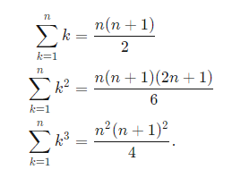

을 참고하면 될 듯.

- 위에 것도 접근이 너무 어려움. DP로 푸는 거였음. 하 나는 DP가 너무 약해…

- 근데 이 DP는 진짜 생각해내기 너무 어려운 것 같은데?

- 내 생각에는 이건 그냥 암기다.

int countSquares(vector<vector<int>>& matrix) {

int res=0;

for(int i=0;i<matrix.size();i++){

for(int j=0;j<matrix[i].size();j++){

if(matrix[i][j] && i && j) matrix[i][j]+=min(matrix[i][j-1],min(matrix[i-1][j-1],matrix[i-1][j]));

res+=matrix[i][j];

}

}

return res;

}

1. if matrix[i][j] == 0, skip
2. use bottom right to count the square, if a 2 * 2 grid like  
   " A B "  
   " C X "  
   every character means the nums of the square that position can represent. For example A = 2 represents 2 squares in the "A" position, one is itself and the other is a 2 * 2 square , a 2 * 2 square means A is in the position like  
   " 1 1 "  
   " 1 A "  
   so X should be Math.min(A+1, B+1, C+1) which ensures X is in the postion like  
   " 1 ... 1 " //k * k, k = Math.min(A+1, B+1, C+1)  
   " 1 .... . "  
   " 1 ... X "  
   for example

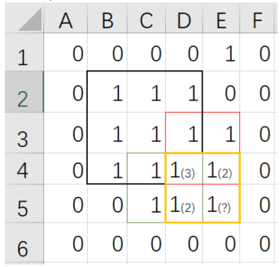

   in the yellow grid, we know (D4=3) (E4=2) (D5=2) and then how to calculate the (E5).  
   D4 = 3 means the largest sqaure it can represent is the black one(3* 3) === we can find 3 sqaures which its bottom right is D4 (1* 1, 2* 2, 3* 3 squares).  
   Then the same as E4(red square) and D5(green one). When it comse to E5, (E5) = Math.min(D4+1, E4+1, D5+1) means the largest square E5 can represent which is (C3 ~ E5)
3. because we are using the bottom right to count the square, the "A B C" will always be calculated before "X". So just go through the grid then and add all nums in the grid

[67. **Spiral Matrix III – 나선모양으로 걸으면서 거친 좌표를 차례대로 벡터에 넣는 문제]**

- 이 문제 왜캐 어려웠지… Discussion을 안보고 풀라고 애썼는 데, 실패했다.

- 이 문제의 포인트는 boundary 바깥으로 나가는 것을 고려하지 않아도 된다는 것이었다. 나선형만 제대로 짜 놓으면 어차피 다시 안으로 들어올 것이고, 주어진 boundary안에 좌표가 있을 때만 answer에 더해주면 되는 것이었다.

vector<vector<int>> spiralMatrixIII(int R, int C, int r0, int c0){

vector<vector<int>> res={{r0,c0}};

int max_step=R*C;

vector<int> cur_pos={r0,c0};

vector<vector<int>> dir={{0,1},{1,0},{0,-1},{-1,0}};

int head=0;

int cur_step=1;

int how_many_step=0;

while(cur_step<max_step){

if(head==0 || head==2) how_many_step++; // when east or west, the step is added one.

for(int i=0;i<how_many_step;i++){ //how many step we have to go before turning right.

//by using the limit R and C, we don't need to consider a walk around outside.

//because it will be returned into the boundary. we just need to check the walk occurs in the boundary or not.

cur_pos[0]+=dir[head][0];

cur_pos[1]+=dir[head][1];

if(0<=cur_pos[0] && cur_pos[0]<R && 0<=cur_pos[1] && cur_pos[1]<C){

cur_step++;

res.push_back(cur_pos);

}

}

head=(head+1)%4;

}

return res;

}

[68. **Reduce Array Size to The Half – 배열의 길이를 반 이하로 만들기 위하여 삭제해야하는 원소의 최소개수를 구하는 문제. 이때 각 원소는 중복될 수 있음]**

- 내가 생각한 방법의 point는 각 원소의 개수대로 sort를 하는 것이었다. 그래서 pair를 이용했다.

- map 만들때 O(n) sort할 때 O(nlogn)이 걸렸고, 마지막에 length 찾을때 O(n)이 걸렸으므로 O(nlogn)알고리즘 인 것 같다.

- 주의할 점음 pair는 ->이 아니라 . 으로 first, second에 접근한다.

- iterator의 위치를 변경할때는 advance(iter,3)의 방식으로 3번째 다음 인덱스로 iter를 옮길 수 있고, iter간의 거리도 distance(iter1, iter2) 의 형식으로 구할 수 있다.

- 추가로 sort할 때 sort(iter.begin(),iter.end(),greater<int>()); 의 형식으로 하면 내림차순 정렬이 가능하다.

int minSetSize(vector<int>& arr) {

unordered_map<int,int> table;

vector<int> answer_array;

for(int ele : arr){

table[ele]++;

}

vector<pair<int,int>> sorted_pair; //(count,number)

for(unordered_map<int,int>::iterator iter=table.begin();iter!=table.end();iter++)

sorted_pair.push_back(make_pair(iter->second,iter->first));

sort(sorted_pair.begin(),sorted_pair.end());

int half=arr.size()/2; // size is always even.

int current_length=0;

for(int i=sorted_pair.size()-1;i>=0;i--){

current_length+=sorted_pair[i].first;

answer_array.push_back(sorted_pair[i].second);

if(current_length>=half) break;

}

return answer_array.size();

}

[69. **Counting Bits - 0부터 주어진 숫자까지의 수들의 bit 표현에서 1의 개수를 세어 vector에 넣는 문제]**

**-** 나는 그냥 bitset을 이용했다 bitset<32>(i).count()로.

vector<int> countBits(int num) {

vector<int> answer;

for(int i=0;i<=num;i++)

answer.push_back(bitset<32>(i).count());

return answer;

}

- 다음과 같은 logic으로도 풀 수 있다.

There is one imporant observation we can make about the number of bits in each number.

You can easily see the pattern here.

[70. **Complex Number Multiplication – 복소수 2개를 주고 곱하여 string으로 출력하는 문제]**

**-** 그냥 각 복소수의 실수와 허수부분을 나누어 곱해주는 방식으로 했는데, 부호 구분하는 데서 오래 걸렸다.

string complexNumberMultiply(string a, string b) {

string answer;

vector<int> a_sub;

vector<int> b_sub;

string temp="";

int i=1;

if(a[0]=='-'){

while('0'<=a[i] && a[i]<='9') temp+=a[i++];

a_sub.push_back(std::stoi(temp)*-1);

}

else{

i=0;

while('0'<=a[i] && a[i]<='9') temp+=a[i++];

a_sub.push_back(std::stoi(temp));

}

temp.clear();

if(b[0]=='-'){

i=1;

while('0'<=b[i] && b[i]<='9') temp+=b[i++];

b_sub.push_back(std::stoi(temp)*-1);

}

else{

i=0;

while('0'<=b[i] && b[i]<='9') temp+=b[i++];

b_sub.push_back(std::stoi(temp));

}

i=a.size()-2;

temp.clear();

while('0'<=a[i] && a[i]<='9') i--;

if(a[i]=='-'){

i++;

while('0'<=a[i] && a[i]<='9') temp+=a[i++];

a_sub.push_back(std::stoi(temp)*-1);

}

else{

i++;

while('0'<=a[i] && a[i]<='9') temp+=a[i++];

a_sub.push_back(std::stod(temp));

}

i=b.size()-2;

temp.clear();

while('0'<=b[i] && b[i]<='9') i--;

if(b[i]=='-'){

i++;

while('0'<=b[i] && b[i]<='9') temp+=b[i++];

b_sub.push_back(std::stoi(temp)*-1);

}

else{

i++;

while('0'<=b[i] && b[i]<='9') temp+=b[i++];

b_sub.push_back(std::stoi(temp));

}

answer+=std::to_string(a_sub[0]*b_sub[0]+a_sub[1]*b_sub[1]*-1);

answer+='+';

answer+=std::to_string(a_sub[1]*b_sub[0]+a_sub[0]*b_sub[1]);

answer+='i';

return answer;

}

- find 함수 이용 간단하게 풀 수 있는 discussion이 있었다.

public:

string complexNumberMultiply(string a, string b) {

pair<int, int> av = parse(a);

pair<int, int> bv = parse(b);

int ra = av.first * bv.first - av.second * bv.second;

int rb = av.first * bv.second + av.second * bv.first;

return to_string(ra) + "+" + to_string(rb) + "i";

}

pair<int, int> parse(const string& a) {

int plus = find(a.begin(), a.end(), '+') - a.begin();

int i = find(a.begin(), a.end(), 'i') - a.begin();

int ra = stoi(a.substr(0, plus));

int rb = stoi(a.substr(plus + 1, i - plus));

return {ra, rb};

}

[71. **Fizz Buzz Multithreaded -Thread 사용하는 문제]**

- 덕분에 thread 공부했다. 하지만 나는 풀 수 없었기에, discussion 보고 thread 어떻게 쓰는지 배웠다.

private:

int n;

int count;

mutex m;

condition_variable cv;

public:

FizzBuzz(int n) {

this->n = n;

this->count = 1;

}

void fizz(function<void()> printFizz) {

while (true) {

unique_lock<mutex> lock(m);

while (count <= n && (count % 3 != 0 || count % 5 == 0))

cv.wait(lock);

if (count > n) return;

printFizz();

++count;

cv.notify_all();

}

}

void buzz(function<void()> printBuzz) {

while (true) {

unique_lock<mutex> lock(m);

while (count <= n && (count % 5 != 0 || count % 3 == 0))

cv.wait(lock);

if (count > n) return;

printBuzz();

++count;

cv.notify_all();

}

}

void fizzbuzz(function<void()> printFizzBuzz) {

while (true) {

unique_lock<mutex> lock(m);

while (count <= n && (count % 5 != 0 || count % 3 != 0))

cv.wait(lock);

if (count > n) return;

printFizzBuzz();

++count;

cv.notify_all();

}

}

void number(function<void(int)> printNumber) {

while (true) {

unique_lock<mutex> lock(m);

while (count <= n && (count % 5 == 0 || count % 3 == 0))

cv.wait(lock);

if (count > n) return;

printNumber(count++);

cv.notify_all();

}

}

[72. **[951] Flip Equivalent Binary Trees – when we choose any node and swap left and right subtrees, we call it a flip operation. Write a function whether two given trees are flip equivalent.]**

- no matter a tree is filped or not, its children have to be same or just changed the order.

- So we can just compare every possible situation – Greedy using DFS.

bool flag=true;

void helper(TreeNode* root1,TreeNode* root2){

if(!root1->left && !root1->right && !root2->left && !root2->right)

return;

if(root1->left && root2->left && root1->left->val == root2->left->val)

helper(root1->left,root2->left);

else if(root1->left && root2->right && root1->left->val==root2->right->val)

helper(root1->left,root2->right);

else if(root1->left){

flag=false;

return;

}

if(!flag) return;

else if(root1->right && root2->left && root1->right->val==root2->left->val)

helper(root1->right,root2->left);

else if(root1->right && root2->right && root1->right->val==root2->right->val)

helper(root1->right,root2->right);

else if(root1->right){

cout<<"flag"<<endl;

flag=false;

}

}

bool flipEquiv(TreeNode* root1, TreeNode* root2) {

if(!root1 && !root2) return true;

if((root1 && !root2) ||(!root1 && root2)) return false;

helper(root1,root2);

return flag;

}

[73. [**1123] Lowest Common Ancestor of Deepest Leave]**

**-** find deepest level from root. If the deepest depth is same, then the root is the answer.

- if the depth is different. determine which one has deeper depth between left and right child.

- and doing recursive with the child who has deeper detph.

int helper(TreeNode* root){

if(!root) return 0;

return 1+max(helper(root->left),helper(root->right));

}

TreeNode* lcaDeepestLeaves(TreeNode* root) {

int left=helper(root->left);

int right=helper(root->right);

if(left==right) return root;

else if(left>right) return lcaDeepestLeaves(root->left);

else return lcaDeepestLeaves(root->right);

}

[74. **[986]** **Interval List Intersections – Given two sorted closed interval, return the intersection of these two lists.]**

- At first try, I use map to record interval of two lists into one store with using vector in the map for checking every interval’s end.

- I think I just need O(total interval of A and B + map.size()). But time limit exceeded occurs.

class Solution {

public:

vector<vector<int>> intervalIntersection(vector<vector<int>>& A, vector<vector<int>>& B) {

map<int,vector<int>> inter;

vector<vector<int>> answer;

int i;

for(vector<int> ele : A){

for(i=ele[0];i<ele[1];i++){

inter[i]={1,0,0};

}

inter[i]={1,1,0};

}

for(vector<int> ele : B){

for(i=ele[0];i<=ele[1];i++){

if(inter[i].empty()) inter[i]={1,0,0};

else inter[i][0]++;

}

inter[i-1][2]=1;

}

map<int,vector<int>>::iterator iter=inter.begin();

int left=0;

for(;iter!=inter.end();iter++){

if(iter->second[0]==2){

left=iter->first;

while(iter->second[0]==2){

if(iter->second[1]==1 || iter->second[2]==1)

break;

else iter++;

}

answer.push_back({left,iter->first});

}

}

return answer;

}

};

- I guess the reason why the time limit exceed occurs is because I search all the element in each intervals. So I should figure out how to solve this problem by just using left and right limit of each intervals only.

- the final answer is that if A[i][1] is less than B[j][0], i++, vice versa j++.

- after that we can find overlapping range by two lists. From there, we just determine which one is left and right limit.

- see the code.

class Solution {

public:

vector<vector<int>> intervalIntersection(vector<vector<int>>& A, vector<vector<int>>& B) {

vector<vector<int>> answer;

for(int i=0, j=0;i<A.size() && j<B.size();){

if(A[i][1]<B[j][0]) i++;

else if(A[i][0]>B[j][1]) j++;

else{

answer.push_back({max(A[i][0],B[j][0]),min(A[i][1],B[j][1])});

if(A[i][1]<B[j][1]) i++;

else j++;

}

}

return answer;

}

};

[75. [**1110] Delete Nodes And Return Forest – delete given node, and return roots of every subtrees.]**

- I solved this problme using bottom-up approach.

- First at all, using postorder search and if a current node has to be deleted, insert their children into answer vector, and come back to parents node, finally delete the node.

- but the point is how I can handle the original root node, value 1, because of that, I have to use another find function whether the to_delete vector has 1 or not. so it cunsume pretty much time I think.

- Tommrow I will revise this algorithm.

public:

TreeNode* helper(TreeNode* root,vector<TreeNode*>& answer, vector<int>& to_delete){

if(!root) return nullptr;

TreeNode* left=nullptr;

TreeNode* right=nullptr;

left=helper(root->left,answer,to_delete);

right=helper(root->right,answer,to_delete);

if(left) root->left=nullptr;

if(right) root->right=nullptr;

for(int i=0;i<to_delete.size();i++){

if(to_delete[i]==root->val){

if(root->left) answer.push_back(root->left);

if(root->right) answer.push_back(root->right);

//to_delete.erase(to_delete.begin()+i);

return root;

}

}

return nullptr;

}

vector<TreeNode*> delNodes(TreeNode* root, vector<int>& to_delete) {

vector<TreeNode*> answer;

helper(root,answer,to_delete);

if(find(to_delete.begin(),to_delete.end(),1)==to_delete.end()) answer.push_back(root);

return answer;

}

};

[76. [**969] Pancake Sorting – find the order of indexs to reverse the given vector from vector.begin() so that the vector is sorted]**

- the flip begin from A[0]. so we have to sort from A.end() descendantly.

- at first, we have to find the largest elements that can be found using A.length.

- then flip from start to the largest elements index so that the largest elements come to first index.

- and reverse all A so as to put the largest elements to last index. and so on.

class Solution {

public:

vector<int> pancakeSort(vector<int>& A) {

int largest=A.size();

vector<int>::iterator last=A.end();

vector<int>::iterator cur;

vector<int> answer;

for(int i=0; i<A.size()-1; i++){

cur=find(A.begin(),last,largest);

cur++;

answer.push_back(distance(A.begin(),cur));

answer.push_back(distance(A.begin(),last));

reverse(A.begin(),cur);

reverse(A.begin(),last);

largest--;

advance(last,-1);

}

return answer;

}

};

[77. [**959] Regions Cut By Slashes – return how many distinct regions appear after dividing whole square by /, \]**

**-** I solved this problem using BFS. But the result was time limit exceeded.

- 1. make the given array 3 time widen. Because to recognize distinct region, we need at least 3 time wider array.

- 2. draw given line to divide region.

- 3. using BFS, paint regions and count hom many regions are.

class Solution {

public:

void helper(vector<vector<int>>& table,queue<pair<int,int>> que){

while(!que.empty()){

int x=que.front().first;

int y=que.front().second;

que.pop();

table[x][y]=1;

if(x && table[x-1][y]==0) que.push(make_pair(x-1,y));

if(y && table[x][y-1]==0) que.push(make_pair(x,y-1));

if(x!=table.size()-1 && table[x+1][y]==0) que.push(make_pair(x+1,y));

if(y!=table[0].size()-1 && table[x][y+1]==0) que.push(make_pair(x,y+1));

}

}

void paintRegion(vector<vector<int>>& table,int& answer){

queue<pair<int,int>> que;

for(int i=0;i<table.size();i++){

for(int j=0;j<table[i].size();j++){

if(table[i][j]==0){

que.push(make_pair(i,j));

helper(table,que);

answer++;

}

}

}

}

int regionsBySlashes(vector<string>& grid) {

int N=grid.size()*3;

vector<vector<int>> table(N,vector<int>(N,0)); //make table N*3 X N*3

for(int i=0;i<grid.size();i++){

for(int j=0;j<grid[i].size();j++){

if(grid[i][j]=='/'){

table[i*3][3*j+2]=1;

table[i*3+1][3*j+1]=1;

table[i*3+2][3*j]=1;

}

else if(grid[i][j]=='\\'){

table[i*3][3*j]=1;

table[i*3+1][3*j+1]=1;

table[i*3+2][3*j+2]=1;

}

}

}

int answer=0;

paintRegion(table,answer);

return answer;

}

};

- due to time limit exceeded, I changed my algorithm to DFS.

class Solution {

public:

void paintRegion(vector<vector<int>>& table,int x, int y){

if(table[x][y]==0){

table[x][y]=1;

if(x) paintRegion(table,x-1,y);

if(y) paintRegion(table,x,y-1);

if(x!=table.size()-1) paintRegion(table,x+1,y);

if(y!=table.size()-1) paintRegion(table,x,y+1);

}

}

int regionsBySlashes(vector<string>& grid) {

int N=grid.size()*3;

int answer=0;

vector<vector<int>> table(N,vector<int>(N,0)); //make table N*3 X N*3

for(int i=0;i<grid.size();i++){

for(int j=0;j<grid[i].size();j++){

if(grid[i][j]=='/'){

table[i*3][3*j+2]=1;

table[i*3+1][3*j+1]=1;

table[i*3+2][3*j]=1;

}

else if(grid[i][j]=='\\'){

table[i*3][3*j]=1;

table[i*3+1][3*j+1]=1;

table[i*3+2][3*j+2]=1;

}

}

}

for(int i=0;i<table.size();i++){

for(int j=0;j<table[i].size();j++){

if(table[i][j]==0){

paintRegion(table,i,j);

answer++;

}

}

}

return answer;

}

};

[78. [**1130] Minimum Cost Tree From Leaf Values – find minimum sum of non-leaf node using the given leaves.]**

- Atually, this problem was super difficult for me. First at all, I thought I sholud have construted a real tree. But it’s quite insane jobs.

- so I tried to make dp but it was not that easy. Finally, I refered to discussion.

- O(N^2) algorithm is below.

> 1. find minimum leaf of the array : val1

> 2. find min(the leaf’s left, the leaf’s right) : val2

> 3. answer+= val1 * val2

> 4. remove val1 and repeat from 1st.

class Solution {

public:

int mctFromLeafValues(vector<int>& arr) {

int answer=0;

int minimum;

int second;

while(arr.size()>1){

minimum=min_element(arr.begin(),arr.end())-arr.begin(); //minimum value's index

if(minimum==0) second=1;

else if(minimum==arr.size()-1) second=minimum-1;

else{

if(arr[minimum+1]>arr[minimum-1]) second=minimum-1;

else second=minimum+1;

}

answer+=arr[minimum]*arr[second];

arr.erase(arr.begin()+minimum);

if(minimum>second) minimum--;

}

return answer;

}

};

- Now I’m trying to understand O(N^3) solution that uses dp.

- The dp solusion from discussion is below.

**Intuition and Algorithm**  
Given an array arr return the smallest possible sum of the values of each non-leaf node.  
The value of each non-leaf node is equal to the product of the largest leaf value in its left and right subtree respectively.

For example:  
arr= [3, 6, 4, 7, 2, 5]

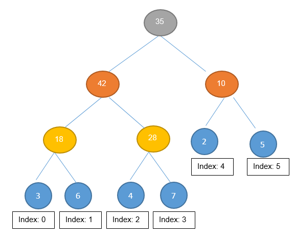

This is one distribution, we are going to solve that from top to bottom with dynammic programming

**Approach 1 (DP)**  
In the image the root, their left subtree contains indexes [0-3] and their right subtree cointains indexes [4-5]. Then their value will be max(arr[0-3])* max(arr[4-5]).

In general:  
dp(left, right )= min( max(arr[left .. i] ) * max(arr[i+1 .. right]) + dp(left,i) +dp(i+1,right) ) where i go from left to right-1

class Solution {

public:

int memo[41][41];

int maxi[41][41];

int dp(int left,int right){

if(left==right)return 0; //leaf node

if(memo[left][right]!=-1)return memo[left][right];

int ans = 1<<30;

for(int i=left;i<right;i++)

ans= min(ans, maxi[left][i] * maxi[i+1][right] + dp(left,i) + dp(i+1,right) );

memo[left][right]=ans;

return ans;

}

int mctFromLeafValues(vector<int>& arr) {

memset(memo,-1,sizeof(memo));

for(int i=0;i<arr.size();i++){

maxi[i][i] = arr[i];

for(int j=i+1;j<arr.size();j++)

maxi[i][j] = max(maxi[i][j-1], arr[j]);

}

return dp(0,arr.size()-1);

}

};

[79 [**889] Construct Binary Tree from Preorder and Postorder Traversal – make a binary tree using the given pre and postorder traversals]**

**-** My first algorithm is that the right next node of current node in preoder traversal is root’s left child and the left next node of current node in post traversal is root’s right child.

- But it’s wrong.

- So I tried a divivde and conquer approach.

- What a difficult problem! I spent almost 4 hours for this heck!

- The key point is divide each traversal respectively.

- And if after making left child, mid+1==postr, then just have to return root.

class Solution {

public:

unordered_map<int,int> table;

TreeNode* helper(vector<int>& pre, vector<int>& post,int prel,int prer,int postl, int postr){

TreeNode* root=new TreeNode(pre[prel]);

if(prel==prer) return root;

int mid=table[pre[prel+1]];

int length=mid-postl;

root->left=helper(pre,post,prel+1,prel+length+1,postl,postl+length);

if(mid+1==postr) return root;

root->right=helper(pre,post,prel+length+2,prer,mid+1,postr-1);

return root;

}

TreeNode* constructFromPrePost(vector<int>& pre, vector<int>& post) {

for(int i=0;i<post.size();i++) table[post[i]]=i;

TreeNode* root=helper(pre,post,0,pre.size()-1,0,post.size()-1);

return root;

}

};

[80. [**791] Custom Sort String – given sorted array S in a custm way, sort array T so that it is sorted like array S]**

‑ Intuition is below

> 1. count each letter in the array T into an unordered_map count.

> 2. For a character C from S.begin to S.end, if the map count has the character of S, add it to answer as many as count[C]

> 3. concatenat all the rest charater in the map count.

class Solution {

public:

string customSortString(string S, string T) {

unordered_map<char,int> count;

for(char c : T)

count[c]++;

string answer;

for(char c : S){

if(count.find(c)!=count.end()){

while(count[c]>0){

answer+=c;

count[c]--;

}

}

}

unordered_map<char,int>::iterator iter=count.begin();

for(;iter!=count.end();iter++){

while(iter->second>0){

answer+=iter->first;

iter->second--;

}

}

return answer;

}

};

[81. [**442] Find All Duplicates in an Array – find numbers which occur twice]**

- If I just have to problem without concerning memory ans time consuming, it is easy.

- But the point is to use only O(1) memory and O(n) time.

- Algorithm is below

> 1. using numbers in array nums as index and negate it. It’s possible since 1<=nums[i]<=n where 0<=i<n.

> 2. if a number occurs twice, the number’s sign must be + not -.

class Solution {

public:

vector<int> findDuplicates(vector<int>& nums) {

vector<int> answer;

for(int i : nums){

i=abs(i);

nums[i-1]=-nums[i-1];

if(nums[i-1]>0) answer.push_back(i);

}

return answer;

}

};

[82. [**1343] Number of Sub-arrays of Size K and Average Greater than or Equal to Threshold – find the number of sub-array of size K that has an average greater than or equal to given threshold]**

- Algorithm is below

> 1. From first of the given array, add K-1 elements. => cur_sum

> 2. iteratively, make cur_sum has K elements. if K’s average is valid about the given condition. then add 1 to answer

> subtract arr[i-k+1] from cur_sum and add arr[[i] to cur]sum and repeat the algorithm from 2.

class Solution {

public:

int numOfSubarrays(vector<int>& arr, int k, int threshold) {

int cur_sum=0;

int answer=0;

for(int i=0;i<k-1;i++)

cur_sum+=arr[i];

for(int i=k-1;i<arr.size();i++){

cur_sum+=arr[i];

if(cur_sum/k >= threshold) answer++;

cur_sum-=arr[i-k+1];

}

return answer;

}

};

[83. [**1043] Partition Array for Maximum Sum – partition the given array into subarrays of length at most given K. each subarray’s value will be changed the greatest value in the subarrays. return the largest sum of the given arrays after partitioning]**

**-** what the heck? this problem is not a midium level. I think!, Yes, I may not good at DP problem :).

- Anyway, I tried to solve this problem 2d DP.

- row is index, col is the size of partition.

- Algorithm is just >> dp[i][j] = max(dp[i-j]…dp[i-1]) + max(A[i-j+1]….A[i])*j).

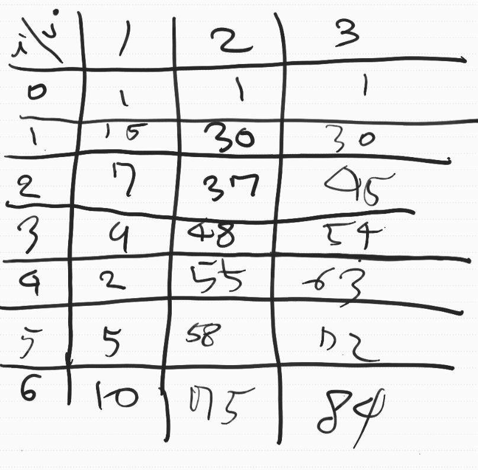

- But tiem limit exceeded occurred.

- see the code.

class Solution {

public:

void printDP(vector<vector<int>> dp){

for(int i=0;i<dp.size();i++){

for(int j=0;j<dp[i].size();j++){

cout<<dp[i][j]<<" ";

}

cout<<endl;

}

}

void initializeDP(vector<int> A, int K, vector<vector<int>>& dp){

//vector initialized

for(int i=0;i<A.size();i++)

dp[i][0]=A[i]; //when K=1;

//initialize DP's diagonal.

for(int i=1,j=1;i<K;i++,j++){

dp[i][j]=*std::max_element(A.begin(),next(A.begin(),i+1))*(j+1);

}

//initialize DP's upper triangle.

for(int i=0;i<K;i++){

for(int j=i+1;j<K;j++){

dp[i][j]=dp[i][j-1];

}

}

}

int dpMAX(vector<vector<int>>& dp,vector<int> A, int K, int i, int j){

int res=INT_MIN;

int prev;

int max_ele=INT_MIN;

for(int a=i-(j+1);a<i;a++){

prev=dp[a][j]; // a = 1

for(int b=a+1;b<=i;b++){

max_ele=max(max_ele,A[b]);

}

res=max(res,prev+max_ele*(i-a));

max_ele=INT_MIN;

}

return res;

}

int maxSumAfterPartitioning(vector<int>& A, int K) {

if(K==1){

return accumulate(A.begin(),A.end(),0);

}

vector<vector<int>> dp(A.size(),vector<int>(K,0));

initializeDP(A,K,dp);

for(int j=1;j<K;j++){

for(int i=j+1;i<A.size();i++){

dp[i][j]=dpMAX(dp,A,K,i,j);

}

}

printDP(dp);

return dp[A.size()-1][K-1];

}

};

- I happened to recognize that I don’t need the 2d DP, since I don’t use previous j(which is 1…K-1) array in the 2d DP. I needed just dp[i][K].

- so I revised my algorithm to an 1d DP.

- speed was 11.42% beats. I know is quite slow, but I’m happy I could solve this problem :).

- see the code.

class Solution {

public:

void initializeDP(vector<int> A, int K, vector<int>& dp){

int max_ele=INT_MIN;

for(int i=0;i<K;i++)

dp[i]=*max_element(A.begin(),next(A.begin(),i+1))*(i+1);

}

int dpMAX(vector<int>& dp,vector<int> A,int i,int K){

int res=INT_MIN;

int prev;

int max_ele=INT_MIN;

for(int a=i-K;a<i;a++){

prev=dp[a];

for(int b=a+1;b<=i;b++){

max_ele=max(max_ele,A[b]);

}

res=max(res,prev+max_ele*(i-a));

max_ele=INT_MIN;

}

return res;

}

int maxSumAfterPartitioning(vector<int>& A, int K) {

if(K==1){

return accumulate(A.begin(),A.end(),0);

}

vector<int> dp(A.size(),0);

initializeDP(A,K,dp);

for(int i=K;i<A.size();i++){

dp[i]=dpMAX(dp,A,i,K);

}

return dp[A.size()-1];

}

};

[84. [**1219] Path with Maximum Gold – find a path to get maximum gold]**

**-** I used DFS to solve this problem. the algorithm is quite intutive. I think the explanation is not needed. just cafeful to use visit array.

- but time limit exceeded occurred.

- see the code.

class Solution {

public:

int DFS(vector<vector<int>> grid,int x,int y,vector<vector<int>> visit){

visit[x][y]=1;

int cur_gold=grid[x][y];

vector<int> max_gold;

if(x && grid[x-1][y]&& !visit[x-1][y]) max_gold.push_back(DFS(grid,x-1,y,visit));

if(y && grid[x][y-1]&&!visit[x][y-1]) max_gold.push_back(DFS(grid,x,y-1,visit));

if(x+1<grid.size() && grid[x+1][y]&&!visit[x+1][y] ) max_gold.push_back(DFS(grid,x+1,y,visit));

if(y+1<grid[0].size() && grid[x][y+1]&&!visit[x][y+1]) max_gold.push_back(DFS(grid,x,y+1,visit));

return cur_gold+ (max_gold.empty()? 0:*max_element(max_gold.begin(),max_gold.end()));

}

int getMaximumGold(vector<vector<int>>& grid) {

int answer=0;

vector<vector<int>> visit(grid.size(),vector<int>(grid[0].size(),0));

for(int i=0;i<grid.size();i++)

for(int j=0;j<grid[i].size();j++)

if(grid[i][j])

answer=max(answer,DFS(grid,i,j,visit));

return answer;

}

};

- I thought the time limit exceeded happened due to max_gold vector and visit vector. so I remove these.

- First, I changed max_gold vector to int and just compare all the possible DFS. Because putting a value into vector and finding maximum value from that vector need quite long time I think.

- Second, I remove visit vector and just use the condition which is, if a cell has 0 golds, then we don’t need to visit the cell. so whenever I visit a cell, I changed the value to 0 like I collected the gold. After all the visiting to neighbor cells, I returned the amount of gold to the cell.

- Finally, I got speed 96.09% beats :).

- see the code.

class Solution {

public:

int DFS(vector<vector<int>>& grid,int x,int y){

int cur_gold=grid[x][y];

grid[x][y]=0;

int max_gold=0;

if(x && grid[x-1][y]) max_gold=max(max_gold,DFS(grid,x-1,y));

if(y && grid[x][y-1]) max_gold=max(max_gold,DFS(grid,x,y-1));

if(x+1<grid.size() && grid[x+1][y]) max_gold=max(max_gold,DFS(grid,x+1,y));

if(y+1<grid[0].size() && grid[x][y+1]) max_gold=max(max_gold,DFS(grid,x,y+1));

grid[x][y]=cur_gold;

return cur_gold+ max_gold;

}

int getMaximumGold(vector<vector<int>>& grid) {

int answer=0;

for(int i=0;i<grid.size();i++)

for(int j=0;j<grid[i].size();j++)

if(grid[i][j])

answer=max(answer,DFS(grid,i,j));

return answer;

}

};

[85. [**877] Stone Game – determine whether alex wins the game or not]**

- the game rule is below.

> 1. player can choose either given array’s first or last element.

> 2. player tries to collect most stone(number) and acts optimally.

- we should determine alex can win or not given array.

- I use DFS to solve this problem. Since each player tries to get more stone than the opponent, we should do brute-force.

- At first, I use the start iterator like below

> piles.erase(start);

- but it occurred a heap-buffer-overflow, I don’t know why actually. So I changed the code to use the current function’s pile vector.

- Finally, I could solve this problem. but the speed was just 49.95% beats.

- see the code.

class Solution {

public:

bool DFS(vector<int> piles, vector<int>::iterator start,vector<int> alex_lee,int turn){

bool answer=false;

if(piles.empty())

return alex_lee[0]>alex_lee[1];

alex_lee[(turn++)%2]+=*start;

if(piles.begin()==start)

piles.erase(piles.begin());

else piles.erase(next(piles.end(),-1));

return DFS(piles,piles.begin(),alex_lee,turn) || DFS(piles,next(piles.end(),-1),alex_lee,turn);

}

bool stoneGame(vector<int>& piles) {

return DFS(piles,piles.begin(),vector<int>{2,0},0) || DFS(piles,next(piles.end(),-1),vector<int>{2,0},0);

}

};

[86. [**1026] Maximum Difference Between Node and Ancestor – find the greatest difference between an ancestor and decendant]**

- In my algorithm, I should’ve used both DFS and BFS for brute-force.

- The algorithm is quite vivid. For each node, I check differeces between the current node and its decendants.

- see the code. the speed was bad. It was just 5.20% beats.

class Solution {

public:

int DFS(TreeNode* root,int cur_val){

if(!root) return 0;

return max(abs(root->val-cur_val),max(DFS(root->left,cur_val),DFS(root->right,cur_val)));

}

int maxAncestorDiff(TreeNode* root) {

queue<TreeNode*> que;

TreeNode* cur;

que.push(root);

int answer=0;

while(!que.empty()){

cur=que.front();

que.pop();

if(cur->left) que.push(cur->left);

if(cur->right) que.push(cur->right);

answer=max(answer,max(DFS(cur->left,cur->val),DFS(cur->right,cur->val)));

}

return answer;

}

};

- In the discussion, there is such a superb approach using 1d vector.

- The algorithm is below.

> 1. finding every paht from root to leaf. and push to vector.

> 2. Then a lefter element is an ancestor of righter element.

> 3. by using this vector, we can find the maximum difference.

- This algorithm was just O(n) where n is the number of nodes.

- Even, we don’t need the 1d vector, we just have to maintain current maximum and minimum value so that when we meet a leaf node, we can use it to calculate a local maximum difference.

- the speed was 69.22% beats. I reckon it quite fast enough.

-see the code.

class Solution {

public:

void DFS(TreeNode* root, int& answer,int maximum,int minimum){

maximum=max(maximum,root->val);

minimum=min(minimum,root->val);

if(!root->left && !root->right){

answer=max(answer,maximum-minimum);

return;

}

if(root->left) DFS(root->left,answer,maximum,minimum);

if(root->right) DFS(root->right,answer,maximum,minimum);

}

int maxAncestorDiff(TreeNode* root) {

int answer=0;

DFS(root,answer,INT_MIN,INT_MAX);

return answer;

}

};

[87. [**841] Keys and Rooms – each room has a list of keys to enter rooms. return true if it is possible to enter every room]**

- Algorithm is below.

> 1. when I enter a room, inserting every key into queue and recording all the key into can_visit. Finally, removing all the key in the room.

> 2. pop a key from the queue, if I already visited the key’s room, continue. otherwise repeat from 1.

> 3. when queue is empty, checking whether the given the number of rooms is same to can_visit.

- the speed was 68.01% beats.

- see the code.

class Solution {

public:

bool canVisitAllRooms(vector<vector<int>>& rooms) {

unordered_set<int> can_visit;

queue<int> que;

int cur_room;

can_visit.insert(0);

for(int i : rooms[0]){

que.push(i);

can_visit.insert(i);

}

rooms[0].clear();

while(!que.empty()){

cur_room=que.front();

que.pop();

if(rooms[cur_room].empty()) continue;

for(int i : rooms[cur_room]){

que.push(i);

can_visit.insert(i);

}

rooms[cur_room].clear();

}

return rooms.size()==can_visit.size();

}

};

[88. **[912] Sort an Array – just sorting an array]**

**-** I implement merge sort. But the speed was suck! 5.17% beats.

- so I impelment quick sort as well. But the speed was just 16.25% beats.

- see the code.

class Solution {

public:

vector<int> merge(vector<int> nums){

if(nums.size()==1) return {nums[0]};

vector<int>::iterator mid=next(nums.begin(),nums.size()/2);

vector<int> left;

vector<int> right;

left=merge({nums.begin(),mid});

right=merge({mid,nums.end()});

vector<int> res;

int i=0,j=0;

while(i<left.size() && j<right.size()){

if(left[i]>right[j]){

res.push_back(right[j]);

j++;

continue;

}

else{

res.push_back(left[i]);

i++;

continue;

}

}

while(i<left.size()) res.push_back(left[i++]);

while(j<right.size()) res.push_back(right[j++]);

return res;

}

void quick(vector<int>& nums, int left, int right){

if(left>=right) return;

int pivot=left;

int i=left+1;

int j=right;

while(i<j){

while(i<j && nums[pivot]>nums[i]) i++;

while(i<j && nums[pivot]<nums[j]) j--;

if(i>=j) break;

int temp=nums[i];

nums[i]=nums[j];

nums[j]=temp;

i++;

j--;

}

if(nums[pivot]>nums[j]){

int temp=nums[j];

nums[j]=nums[pivot];

nums[pivot]=temp;

}

quick(nums,left,j-1);

quick(nums,j,right);

}

vector<int> sortArray(vector<int>& nums) {

quick(nums,0,nums.size()-1);

return nums;

}

};

[89. [**406] Queue Reconstruction by Height – standing people by given a height rule]**

**-** a person have a height and a number which represents the number of person who have a height higher than or equal to the person. by using it, we have sort the given array.

- this problem was quite difficult. Algorithm didn’t happen in my brain.

- Algorithm is below.

> 1. sorting max-height people as a subarray.

> 2. using the value k that each person has as an index, inserting every person to answer vector.

> 3. repeating from 1, until the given array people is empty.

- the speed was 11.52% beats.

- see the code.

class Solution {

public:

vector<vector<int>> MaxSubarray(int cur_max_value,vector<vector<int>>& people){

vector<vector<int>> cur_max;

vector<vector<int>>::iterator iter=next(people.end(),-1);

for(;iter!=next(people.begin(),-1);iter--){

if(cur_max_value!=iter[0][0]){

iter++;

break;

}

}

if(iter==next(people.begin(),-1)) iter=people.begin();

cur_max={iter,people.end()};

people.erase(iter,people.end());

sort(cur_max.begin(),cur_max.end());

return cur_max;

}

vector<vector<int>> reconstructQueue(vector<vector<int>>& people) {

if(people.empty()) return {};

sort(people.begin(),people.end());

vector<vector<int>> cur_max;

vector<vector<int>> answer;

int cur_max_value=people[people.size()-1][0];

answer=MaxSubarray(cur_max_value,people);

while(!people.empty()){

cur_max_value=people[people.size()-1][0];

cur_max=MaxSubarray(cur_max_value,people);

for(vector<int> person : cur_max)

answer.insert(next(answer.begin(),person[1]),person);

cout<<endl;

}

return answer;

}

};

[90. [**429] N-ary Tree Level Order Traversal – split given tree based on levels]**

- I think there are two method to solve the problem. one is to use two queues, the other is to use only one queue and to count how many nodes we have to consider in a level

- I chose a second algorithm.

- Algorithm is below.

> 1. For each iteration, memorize how many children are there at a certain level. Then we can use the number as a next level’s the number of nodes.

> 2. And for each iteration, if we met NULL, skip it. otherwise put the node’s children into the queue.

> 3. repeating from 1. until queue becomes empty.

- the speed was 52.03% beats.

-see the code. notice that I added the Node class since it’s not the usual form of normal Node Class.

/*

// Definition for a Node.

class Node {

public:

int val;

vector<Node*> children;

Node() {}

Node(int _val) {

val = _val;

}

Node(int _val, vector<Node*> _children) {

val = _val;

children = _children;

}

};

*/

class Solution {

public:

void levelOrder(Node* root,queue<Node*>& que,vector<int>& cur_level){

if(!root) return;

for(Node* i : root->children){

que.push(i);

cur_level.push_back(i->val);

}

}

vector<vector<int>> levelOrder(Node* root) {

if(!root) return {};

queue<Node*> que;

vector<vector<int>> answer;

vector<int> cur_level;

que.push(root);

Node* cur;

int need=1;

answer.push_back({{root->val}});

while(!que.empty()){

for(int count=0;count<need;count++){

cur=que.front();

que.pop();

levelOrder(cur,que,cur_level);

}

if(!cur_level.empty()) answer.push_back(cur_level);

need=cur_level.size();

cur_level.clear();

}

return answer;

}

};

[91. [**1238] Circular Permutation in Binary Representation – return a permutation such that p[i] and p[i+1] differ by only one bit in their binary representation]**

**-** My algorithm is below.

> 1. put string “0” and “1” into vector table as a initial values. since n’s least limit is 1.

> 2. push_back the strings in the vector table in a reverse order.

> 3. add 0’s for the number of table.size()/2 and add 1’s for the rest.

> 4. From 1 to n, repeat the algorithm from 2 to 4.

> 5. reverse all the string in the vector table.

> 6. covert all the string in the vector table to int. the method is below.

>>> Notice: usage of stoi

int i = std::stoi("01000101", nullptr, 2);

- > The returned value is the converted int value.
- > The first argument is the std::string you want to convert.
- > The second is a size_t * where it'll save the index of the first non digit character.
- > The third is an int that corresponds to the base that'll be used for conversion..

> 7. find start position and reconstruct vector to return.

- refer to the picture I drew.

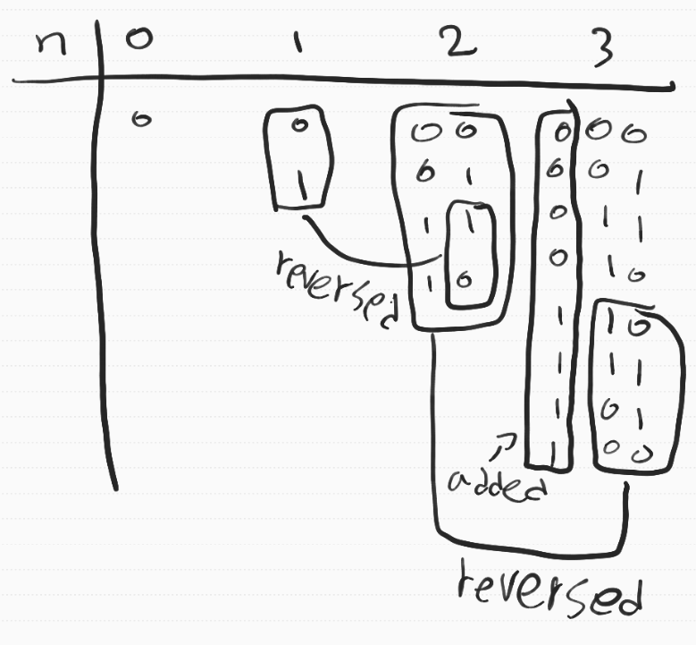

- the speed was not good. It was just 9.85% beats.

class Solution {

public:

void reverseConcatenate(vector<string>& table){

for(int i=table.size()-1;i>=0;i--)

table.push_back(table[i]);

}

void addBits(vector<string>& table){

for(int i=0;i<table.size()/2;i++)

table[i]+='0';

for(int i=table.size()/2;i<table.size();i++)

table[i]+='1';

}

void reverseStrings(vector<string>& table){

for(int i=0;i<table.size();i++)

reverse(table[i].begin(),table[i].end());

}

vector<int> binaryToInt(vector<string> table){

vector<int> answer;

for(string s : table)

answer.push_back(std::stoi(s,nullptr,2));

return answer;

}

vector<int> circularPermutation(int n, int start) {

vector<string> table={"0","1"};

for(int i=2;i<=n;i++){

reverseConcatenate(table);

addBits(table);

}

reverseStrings(table);

vector<int> answer=binaryToInt(table);

vector<int>::iterator iter=find(answer.begin(),answer.end(),start);

vector<int> res={iter,answer.end()};

for(vector<int>::iterator res_iter=answer.begin();res_iter!=iter;res_iter++)

res.push_back(*res_iter);

return res;

}

};

[92. [**998] Maximum Binary Tree II – insert the given value into max heap]**

- Algorithm is below.

> 1. if root is exist and root->val > given value, call the helper function with giving root->right as a parameter.

> 2. if root is not exist or root->val<=given value, create a new node of given value.

> 3. Allocate the new node->left = root. And return the node.

- see the code.

class Solution {

public:

TreeNode* helper(TreeNode* root, int val){

if(root && root->val>val){

root->right=helper(root->right,val);

return root;

}

TreeNode* node=new TreeNode(val);

node->left=root;

return node;

}

TreeNode* insertIntoMaxTree(TreeNode* root, int val) {

return helper(root,val);

}

};

[93. [**739] Daily Temperatures – determine how many days we have to wait so that a temperatur is wamer than today.]**

- Algorithm is below.

> 1. make stack and push the last element in the given vector T as a pair with count 0 : (T[i],0)

> 2. For i where t.end-2 to 0, if stack’s top is less than T[i], pop and accumulate count.

> 3. if stack is empty, put the T[i] with 0. otherwise put the t[i] with count and put the count into answer[i]

- see the code.

class Solution {

public:

vector<int> dailyTemperatures(vector<int>& T) {

stack<pair<int,int>> stk;

vector<int> answer(T.size(),0);

stk.push(make_pair(T.back(),0));

for(int i=T.size()-2;i>=0;i--){

int count=1;

while(!stk.empty() && stk.top().first<=T[i]){

count+=stk.top().second;

stk.pop();

}

if(stk.empty()){

stk.push(make_pair(T[i],0));

}

else{

stk.push(make_pair(T[i],count));

answer[i]=count;

}

}

return answer;

}

};

[94. [**973] K Closest Points to Origin – calculate Euclidean distance of given coordinates and find K CLosets Points to Origin]**

- I used map. key is Euclidean Distance and value is the coordinates.

- Since there might be same Euclidean Distance but different coordinates. I should’ve used vector<vector<int>> as a value of the map.

- the speed was 27.42% beats.

- I found we can use nth_element function that sort the list till given index is sorted.

- see the code.

class Solution {

public:

int Euclidean(int x, int y){

return pow(x,2)+pow(y,2);

}

vector<vector<int>> kClosest(vector<vector<int>>& points, int K) {

vector<vector<int>> answer;

map<int,vector<vector<int>>> table;

for(vector<int> cor: points)

table[Euclidean(cor[0],cor[1])].push_back({cor[0],cor[1]});

int count=0;

map<int,vector<vector<int>>>::iterator iter=table.begin();

for(int i=0;count<K;i++){

for(int j=0;j<iter->second.size();j++){

if(count>=K) break;

answer.push_back({iter->second[j][0],iter->second[j][1]});

count++;

}

iter++;

}

return answer;

}

};

[94. [**1318] Minimum Flips to Make a OR b Equal to c – return how many filps we need to make a OR b == c]**

- Algorithm is below.

> 1. given a,b and c, convert these to bitset.

> 2. if C[i]==1 and A[i]==0 and B[i]==0, then filp++;

> 3. if C[i]==0 and A[i]==1 ,flip++ ,or B[i]==1, filp++; where 0<= i < log2(max(a,b,c)) +1

- the speed was 100% beats.

-see the code.

class Solution {

public:

int minFlips(int a, int b, int c) {

bitset<30> A(a);

bitset<30> B(b);

bitset<30> C(c);

int maximum=max(a,(max(b,c)));

int max_count=log2(maximum)+1;

int flip=0;

for(int i=0;i<max_count;i++){

if(C[i] && !A[i] && !B[i]){

flip++;

}

else if(!C[i]){

if(A[i]) flip++;

if(B[i]) flip++;

}

}

return flip;

}

};

[95. [**1306] Jump Game III – determine whether we can reach the index I with value 0 from start position with given rules.]**

**-** I used map to record which index I have to visit so as to visit current value. That is, map’s key is we want to visit, and map’s value is an index we need to visit the index.

- refer to the picture below.

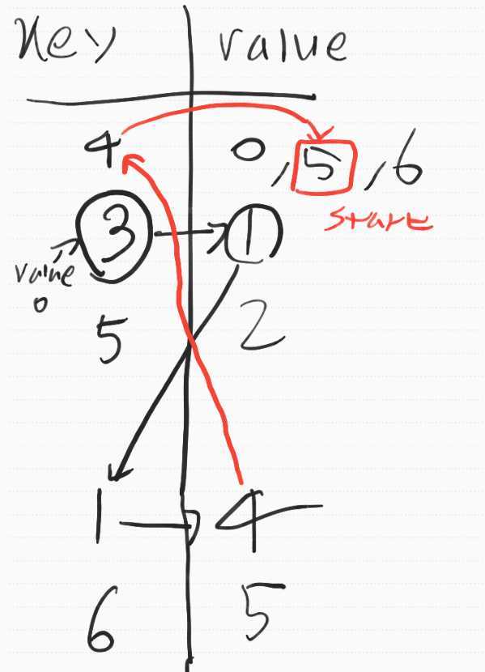

> the red rectangular is start position and key 3 is where 0 is.

- I implemented DFS by using stack so that when we have path to 0, find the answer as soon as possible.

- see the code.

class Solution {

public:

bool canReach(vector<int>& arr, int start) {

if(arr[start]==0) return true;

unordered_map<int,vector<int>> table;

vector<int> zeros;

for(int i=0;i<arr.size();i++){

if(arr[i]==0) zeros.push_back(i);

if(i+arr[i]<arr.size() && arr[i]) table[i+arr[i]].push_back(i);

if(i-arr[i]>=0 && arr[i]) table[i-arr[i]].push_back(i);

}

stack<int> index;

for(int i=0;i<zeros.size();i++){

int cur;

index.push(zeros[i]);

while(!index.empty()){

cur=index.top();

index.pop();

if(table.find(cur)==table.end()) continue;

for(int j=0;j<table[cur].size();j++){

if(table[cur][j]==start) return true;

index.push(table[cur][j]);

}

table[cur].clear();

}

}

return false;

}

};

[96 [**931] Minimum Falling Path Sum – find minimum sum of given rules]**

**-** At first, I used DFS to consider all the path possible. but time limit exceeded occurred.

- see the code.

class Solution {

public:

int helper(vector<vector<int>> A, int i,int j,int sum=0){

if(j<0 || j>=A[0].size()) return INT_MAX;

int cur=sum+A[i][j];

if(i==A.size()-1) return cur;

return min(helper(A,i+1,j-1,cur),min(helper(A,i+1,j,cur),helper(A,i+1,j+1,cur)));

}

int minFallingPathSum(vector<vector<int>>& A) {

int minimum=INT_MAX;

for(int i=0;i<A[0].size();i++){

minimum=min(minimum,helper(A,0,i));

}

return minimum;

}

};

- I changed my algorithm to DP.

- we don’t need to consider previous row after the minimum value of dp[i][j] is allocated.

- the speed was 99.24 % beats.

- see the code.

class Solution {

public:

int minFallingPathSum(vector<vector<int>>& A) {

vector<vector<int>> dp(A.size(),vector<int>(A[0].size(),INT_MAX));

for(int i=0;i<dp[0].size();i++)

dp[0][i]=A[0][i];

for(int i=0;i<dp.size()-1;i++){

for(int j=0;j<dp[0].size();j++){

if(j-1>=0) dp[i+1][j-1]=min(dp[i+1][j-1],dp[i][j]+A[i+1][j-1]);

dp[i+1][j]=min(dp[i+1][j],dp[i][j]+A[i+1][j]);

if(j+1<dp[0].size()) dp[i+1][j+1]=min(dp[i+1][j+1],dp[i][j]+A[i+1][j+1]);

}

}

return *min_element(dp[dp.size()-1].begin(),dp[dp.size()-1].end());

}

};

[97. [**1140] Stone Game II – return the most stones alex can win]**

**-** Finally, I’ve solved this problem!!! I took almost 5 hours…

- I refered to discussion about (sum+helper())/2

- To resolve time limit exceeded, I used dp.

-see the code.

class Solution {

public:

int helper(vector<int>& piles,int x,int M,bool alex,vector<vector<int>>& dp){

if(dp[x][M]!=INT_MIN) return dp[x][M];

if(piles.size()-x<=2*M){

int sum=0;

for(int i=x;i<piles.size();i++)

sum+=piles[i];

return sum;

}

int res=INT_MIN;

int cur_sum=0;

for(int i=x;i<x+2*M;i++){

cur_sum+=piles[i];

res=max(res,cur_sum-helper(piles,i+1,max(M,i-x+1),!alex,dp));

}

dp[x][M]=res;

return res;

}

int stoneGameII(vector<int>& piles) {

vector<vector<int>> dp(piles.size()+1,vector<int>(piles.size()+1,INT_MIN));

int sum=std::accumulate(piles.begin(),piles.end(),0);

int aa=helper(piles,0,1,true,dp);

int res=(sum+aa)/2;

return res;

}

};

- At first, I took brute force. But the time limit exceeded occurred.

class Solution {

public:

int helper(vector<int>& piles,int x,int M){

//if the rest stones are less then 2M, return all the rest stones

if(piles.size()-x<=2*M){

int sum=0;

for(int i=x;i<piles.size();i++)

sum+=piles[i];

return sum;

}

//else do brute force.

int sum=INT_MIN;// this variable will be returned.

int cur_sum=0;

int i;

for(int m=1;m<=2*M;m++){ //for every m where 1<=m<=2M, find all the possible case.

cur_sum=0;

for(i=x;i<x+m;i++)

cur_sum+=piles[i];

sum=max(sum,cur_sum-helper(piles,i,max(M,m)));

}

return sum;

}

int stoneGameII(vector<int>& piles) {

int sum=std::accumulate(piles.begin(),piles.end(),0);

// i think I have to do brute force.

return (sum+helper(piles,0,1))/2;

}

};

- I don’t understand the algorithm. I gave up…

- they say like, dp[i][j] is the maximum stones alex can get where starting at index I with M=j.

- fxxking DP!!!

- see the code.

class Solution {

public:

int stoneGameII(vector<int>& piles) {

int length = piles.size();

vector<vector<int>>dp(length + 1, vector<int>(length + 1,0));

vector<int> sufsum (length + 1, 0);

for (int i = length - 1; i >= 0; i--) {

sufsum[i] = sufsum[i + 1] + piles[i];

}

for (int i = 0; i <= length; i++) {

dp[i][length] = sufsum[i];

}

for (int i = length - 1; i >= 0; i--) {

for (int j = length - 1; j >= 1; j--) {

for (int X = 1; X <= 2 * j && i + X <= length; X++) {

dp[i][j] = max(dp[i][j], sufsum[i] - dp[i + X][max(j, X)]);

}

}

}

return dp[0][1];

}

};

[98. [Samsung SW – A : connect processor]]

- I spent almost 5 hours for debugging…

- see the code.

#include<iostream>

#include<vector>

#include<climits>

using namespace std;

vector<vector<int>> drawTable(int cur_size, vector<pair<int, int>>& position,int& chips) {

vector<vector<int>> table(cur_size, vector<int>(cur_size, 0));

int c;

for (int i = 0; i < cur_size; i++) {

for (int j = 0; j < cur_size;) {

cin >> c;

if (c == 0 || c == 1) {

table[i][j] = c;

if ((i == 0 || j == 0 || i == cur_size - 1 || j == cur_size - 1) && c==1) {

chips++;

}

else if (c == 1) {

position.push_back(make_pair(i, j));

}

j++;

}

}

}

return table;

}

void printTable(vector<vector<int>> table) {

int cur_size = table.size();

for (int i = 0; i < cur_size; i++) {

for (int j = 0; j < table[i].size(); j++) {

cout << table[i][j];

}

cout << endl;

}

}

vector<int> DFS(vector<vector<int>> table, vector<pair<int, int>>& position, int connect,int check, int lines,int numChips,int cur_size) {

if (check ==numChips) {

return { connect,lines };

}

bool flag = false;

vector<vector<int>> temp = table;

int x = position[check].first;

int y = position[check].second;

vector<int> res = { 0,100 };

vector<int> cur = { 0,100 };

//north

for (int i = x - 1; i >= -1; i--) {

if (i < 0) {

flag = true;

res = DFS(temp, position, connect + 1, check+1,lines + x, numChips, cur_size);

if (cur[0] < res[0]) {

cur = res;

}

else if (cur[0] == res[0] && cur[1] > res[1])

cur = res;

break;

}

if (temp[i][y] == 0) temp[i][y] = 1;

else break;

}

temp = table;

//south

for (int i = x + 1; i <= cur_size; i++) {

if (i >= cur_size) {

flag = true;

res = DFS(temp, position, connect + 1, check+1, lines + cur_size - (x+1 ), numChips, cur_size);

if (cur[0] < res[0]) {

cur = res;

}

else if (cur[0] == res[0] && cur[1] > res[1])

cur = res;

break;

}

if (temp[i][y] == 0) temp[i][y] = 1;

else break;

}

temp = table;

//east

for (int i = y + 1; i <= cur_size; i++) {

if (i >= cur_size) {

flag = true;

res = DFS(temp, position, connect + 1, check + 1, lines + cur_size - (y+1), numChips, cur_size);

if (cur[0] < res[0]) {

cur = res;

}

else if (cur[0] == res[0] && cur[1] > res[1])

cur = res;

break;

}

if (temp[x][i] == 0) temp[x][i] = 1;

else break;

}

temp = table;

//west

for (int i = y - 1; i >= -1; i--) {

if (i < 0) {

flag = true;

res = DFS(temp, position, connect + 1, check + 1, lines + y, numChips, cur_size);

if (cur[0] < res[0]) {

cur = res;

}

else if (cur[0] == res[0] && cur[1] > res[1])

cur = res;

break;

}

if (temp[x][i] == 0) temp[x][i] = 1;

else break;

}

if (!flag) {

cur = DFS(temp, position, connect, check + 1, lines, numChips, cur_size);

}

return { cur[0],cur[1] };

}

int main(int argc, char** argv) {

int test_case;

int T;

cin >> T;

int cur_size;

string cur_row;

int chips=0;

vector<int> answer;

for (test_case = 1; test_case <= T; ++test_case) {

cin >> cur_size;

vector<pair<int, int>> position;

chips = 0;

vector<vector<int>> table = drawTable(cur_size, position,chips);

//printTable(table);

answer = DFS(table, position, chips, 0,0,cur_size-chips, cur_size);

cout << "#" << test_case << " " << answer[1] << endl;

}

return 0;//정상종료시 반드시 0을 리턴해야합니다.

}

[99. [**695] Max Area of Island] – return a maximum size of island]**

**-** just use DFS or BFS. Emprically, DFS is faster than BFS.

- see the code.

class Solution {

public:

int DFS(vector<vector<int>>& grid,int x, int y,int area){

if(!grid[x][y]) return 0;

grid[x][y]=0;

if(x-1>=0 && grid[x-1][y]) area+=DFS(grid,x-1,y,0);

if(y-1>=0 && grid[x][y-1]) area+=DFS(grid,x,y-1,0);

if(x+1<grid.size() && grid[x+1][y]) area+=DFS(grid,x+1,y,0);

if(y+1<grid[0].size() && grid[x][y+1]) area+=DFS(grid,x,y+1,0);

return area+1;

}

int maxAreaOfIsland(vector<vector<int>>& grid) {

int answer=0;

int cur;

for(int i=0;i<grid.size();i++){

for(int j=0;j<grid[0].size();j++){

if(grid[i][j]==1){

cur=DFS(grid,i,j,0);

answer=max(answer,cur);

}

}

}

return answer;

}

};

[100. [**46] Permutations – find all the possible permutation]**

**-** The function next_permutation return true if there is next permutation, and revise given vector to next

permutation. but the function can’t handle negative value.

- So I used DFS. Actually, it’s not such a DFS, but I think it is :).

- Algorithm is below.

> 1. from 0 to nums.size(), input the value into new vector

> 2. remove the value, and repeat from 1.

> 3. if all the value in the given vector nums is removed, push the vector cur into answer vector

- The speed was 61.80% beats.

- see the code.

class Solution {

public:

void dfs(vector<int> nums,vector<vector<int>>& answer,vector<int> cur,int start){

nums.erase(next(nums.begin(),start));

if(nums.size()==0){

answer.push_back(cur);

return;

}

for(int i=0;i<nums.size();i++){

vector<int> temp=cur;

temp.push_back(nums[i]);

dfs(nums,answer,temp,i);

}

}

vector<vector<int>> permute(vector<int>& nums) {

vector<vector<int>> answer;

for(int i=0;i<nums.size();i++){

vector<int> cur;

cur.push_back(nums[i]);

dfs(nums,answer,cur,i);

}

return answer;

}

};

[101. **[BACKJOON – SAMSUNG SW : Marbles]]**

- I spent 6 hours…

- At first, I used DFS but some test case was not solved.

> I think I solved rightly, but my print method might have been wrong…

- So I refered to a blog and used BFS

- see the code.

#include<iostream>

#include<vector>

#include<algorithm>

#include<climits>

#include<fstream>

#include<queue>

using namespace std;

vector<vector<int>> direction = { {0,-1},{0,1},{-1,0},{1,0} };//left right up dwon

int visit[10][10][10][10];

vector<vector<char>> makeTable2(vector<int>& position) {

std::ifstream in("C:\\Users\\gjsgu\\Desktop\\Algorithm\\test_case.txt");

string row;

int N;

int M;

if (in.is_open()) {

in >> N;

in >> M;

}

vector<vector<char>> table(N+2, vector<char>(M+2, '#'));

for (int i = 0; i < N; i++) {

in >> row;

for (int j = 0; j < M; j++) {

if (row[j] == 'R') {

position[0] = i;

position[1] = j;

}

if (row[j] == 'B') {

position[2] = i;

position[3] = j;

}

if (row[j] == 'O') {

position[4] = i;

position[5] = j;

}

table[i][j] = row[j];

}

}

return table;

}

vector<vector<char>> makeTable(vector<int>& position) {

string row;

int N;

int M;

cin >> N;

cin >> M;

vector<vector<char>> table(N+2, vector<char>(M+2, '#'));

for (int i = 0; i < N; i++) {

cin >> row;

for (int j = 0; j < M; j++) {

if (row[j] == 'R') {

position[0] = i;

position[1] = j;

}

if (row[j] == 'B') {

position[2] = i;

position[3] = j;

}

if (row[j] == 'O') {

position[4] = i;

position[5] = j;

}

table[i][j] = row[j];

}

}

return table;

}

void printTable(vector<vector<char>>& table) {

cout << endl;

for (vector<char> row : table) {

for (char c : row) {

cout << c;

}

cout << endl;

}

}

void moveTo(vector<vector<char>>& table,int& x, int& y, int k) {

while (true) {

x += direction[k][0]; y += direction[k][1];

//cout << " x : " << x << " y : " << y << endl;

if (table[x][y] == '#') {

x -= direction[k][0]; y -= direction[k][1];

break;

}

else if (table[x][y] == 'O') break;

}

}

int BFS(vector<vector<char>>& table,int a,int b,int c, int d,int e,int f) {

int count=0;

queue<vector<int>> que;

que.push({ a,b,c,d,0 });

visit[a][b][c][d] = 1;

while (!que.empty()) {

vector<int> cur = que.front(); que.pop();

a = cur[0]; b = cur[1]; c = cur[2]; d = cur[3]; count = cur[4];

//cout << a << " " << b << " " << c << " " << d << endl;

if (count > 10) break; // when the depth is over 10

if (a == e && b == f) return count; // when red ball is placed at th hole.

//ball move

for (int i = 0; i < 4; i++) {

int rx = a; int ry = b; int bx = c; int by = d;

moveTo(table,rx, ry, i);

moveTo(table,bx, by, i);

if (bx == e && by == f) continue;

if (rx == bx && ry == by) { //if they are overlapped.

switch (i){

case 0: //left

b < d ? by++ : ry++;

break;

case 1: //right

d < b ? by-- : ry--;

break;

case 2: //up

a < c ? bx++ : rx++;

break;

case 3: //down

c < a ? bx-- : rx--;

break;

}

}

if (!visit[rx][ry][bx][by]) {

//cout << "input que : " << rx << " "<< ry << " " << bx << " " << by << endl;

que.push({ rx,ry,bx,by,count + 1 });

visit[rx][ry][bx][by] = 1;

}

}

}

return -1;

}

int main() {

int answer=-1;

vector<int> position(6,0);

vector<vector<char>> table = makeTable(position);

//vector<vector<char>> table = makeTable2(position);

visit[position[0]][position[1]][position[2]][position[3]] = 1;

//printTable(table);

answer = BFS(table, position[0], position[1], position[2], position[3],position[4],position[5]);

printf("%d", answer);

return 0;

}

[102. **[BACKJOON – SAMSUNG SW : 2048]]**

**-** I used BFS, but BFS is not the matter. move function was the main point.

- I made each direction’s function respectively. so I solved faster than before.

- it took 1 hour and half.

- see the code.

#include<iostream>

#include<vector>

#include<algorithm>

#include<fstream>

#include<queue>

#include<climits>

using namespace std;

vector<vector<int>> makeTable() {

std::ifstream in("C:\\Users\\gjsgu\\Desktop\\Algorithm\\test_case\\test_case_for_2048.txt");

int N;

int c;

if (in.is_open()) {

cout << "test_case is opened." << endl;

in >> N;

}

vector<vector<int>> table(N,vector<int>(N,0));

for (int i = 0; i < N; i++) {

for (int j = 0; j < N;) {

in >> c;

table[i][j++] = c;

}

}

return table;

}

vector<vector<int>> makeTable2() {

int N;

int c;

cin >> N;

vector<vector<int>> table(N,vector<int>(N,0));

for (int i = 0; i < N; i++) {

for (int j = 0; j < N;) {

cin >> c;

table[i][j++] = c;

}

}

return table;

}

void printTable(vector<vector<int>> & table) {

for (vector<int> row : table) {

for (int i : row) {

cout << i << " ";

}

cout << endl;

}

}

int findMax(vector<vector<int>>& table) {

int maximum = 0;

for (vector<int> row : table)

maximum = max(maximum, *max_element(row.begin(), row.end()));

return maximum;

}

/*

3

2 2 2

4 4 4

8 8 8

*/

// these functions are the main point of this problem.

// move left and right start from column but move up and down start from row.

vector<vector<int>> move_left(vector<vector<int>> table) {

int cur_val;

vector<vector<int>> visit(table.size(), vector<int>(table.size(), 0));

for (int col = 1; col < table[0].size(); col++) {

for (int row = 0; row < table.size(); row++) {

cur_val = table[row][col];

if (cur_val == 0) continue;

int j = col-1;

while (table[row][j] == 0 && j>0) j--; // finding a cell is not value 0.

table[row][col] = 0;

//if they have a same value.

if (table[row][j] == cur_val && visit[row][j]==0) {

table[row][j] *= 2;

visit[row][j] = 1;

}

//if there is no value to be concerned and the cell is not visited yet.

else if (j==0 && table[row][j]==0 && visit[row][j]==0) table[row][0] = cur_val;

//if they have different values or the cell is already visited.

else if (table[row][j] != cur_val || visit[row][j]) table[row][j + 1] = cur_val;

}

}

return table;

}

vector<vector<int>> move_right(vector<vector<int>> table) {

int cur_val;

vector<vector<int>> visit(table.size(), vector<int>(table.size(), 0));

for (int col = table[0].size()-2; col>=0; col--) {

for (int row = 0; row < table.size(); row++) {

cur_val = table[row][col];

if (cur_val == 0) continue;

//cout << " row : " << row << " col : " << col << " cur_val : " << cur_val << endl;

int j = col + 1;

while (table[row][j] == 0 && j < table[0].size()-1) j++; // finding a cell is not value 0.

table[row][col] = 0;

//if they have a same value.

if (table[row][j] == cur_val && visit[row][j] == 0) {

table[row][j] *= 2;

visit[row][j] = 1;

}

//if there is no value to be concerned and the cell is not visited yet.

else if (j == table[0].size()-1 && table[row][j] == 0 && visit[row][j] == 0) table[row][table[0].size()-1] = cur_val;

//if they have different values or the cell is already visited.

else if (table[row][j] != cur_val || visit[row][j]) table[row][j - 1] = cur_val;

}

}

return table;

}

vector<vector<int>> move_up(vector<vector<int>> table) {

int cur_val;

vector<vector<int>> visit(table.size(), vector<int>(table.size(), 0));

for (int row = 1; row<table.size(); row++) {

for (int col=0; col < table[0].size(); col++) {

cur_val = table[row][col];

if (cur_val == 0) continue;

int i = row - 1;

while (table[i][col] == 0 && i >0) i--; // finding a cell is not value 0.

table[row][col] = 0;

//if they have a same value.

if (table[i][col] == cur_val && visit[i][col] == 0) {

table[i][col] *= 2;

visit[i][col] = 1;

}

//if there is no value to be concerned and the cell is not visited yet.

else if (i == 0 && table[i][col] == 0 && visit[i][col] == 0) table[0][col] = cur_val;

//if they have different values or the cell is already visited.

else if (table[i][col] != cur_val || visit[i][col]) table[i+1][col] = cur_val;

}

}

return table;

}

vector<vector<int>> move_down(vector<vector<int>> table) {

int cur_val;

vector<vector<int>> visit(table.size(), vector<int>(table.size(), 0));

for (int row = table.size()-2; row>=0; row--) {

for (int col = 0; col < table[0].size(); col++) {

cur_val = table[row][col];

if (cur_val == 0) continue;

//cout << " row : " << row << " col : " << col << " cur_val : " << cur_val << endl;

int i = row + 1;

while (table[i][col] == 0 && i < table.size()-1) i++; // finding a cell is not value 0.

table[row][col] = 0;

//if they have a same value.

if (table[i][col] == cur_val && visit[i][col] == 0) {

table[i][col] *= 2;

visit[i][col] = 1;

}

//if there is no value to be concerned and the cell is not visited yet.

else if (i == table.size()-1 && table[i][col] == 0 && visit[i][col] == 0) table[table.size()-1][col] = cur_val;

//if they have different values or the cell is already visited.

else if (table[i][col] != cur_val || visit[i][col]) table[i - 1][col] = cur_val;

}

}

return table;

}

int BFS(vector<vector<int>> table) {

queue <pair<vector<vector<int>>,int>> que;

que.push(make_pair(table, 0));

vector<vector<int>> cur_table;

int depth;

int maximum = 0;

while (!que.empty()) {

cur_table = que.front().first;

depth = que.front().second;

que.pop();

//printTable(cur_table);

//cout <<"depth : "<<depth<<endl;

//if the depth is 5, finding the maximum value of it.

if (depth == 5) {

maximum = max(maximum, findMax(cur_table));

continue;

}

//for 4 directions, moving the current table.

que.push(make_pair(move_left(cur_table), depth + 1));

que.push(make_pair(move_right(cur_table), depth + 1));

que.push(make_pair(move_up(cur_table), depth + 1));

que.push(make_pair(move_down(cur_table), depth + 1));

}

return maximum;

}

int main() {

//vector<vector<int>> table = makeTable();

vector<vector<int>> table = makeTable2();

//printTable(table);

// cout << endl;

int answer=BFS(table);

cout << answer;

return 0;

}

[103. **[BACKJOON – SAMSUNG SW : Snake]]**

**-** I confused due to apple’s corordinate. they gave the corordiantes strating from row 1 and column 1 not 0 and 0.

- to follow tail, I used queue.

- I spent 1 hour and 10~20 minutes.

- see the code.

#include<iostream>

#include<fstream>

#include<vector>

#include<queue>

using namespace std;

pair<queue<pair<int,char>>,vector<vector<int>>> makeTable() {

ifstream in("C:\\Users\\gjsgu\\Desktop\\Algorithm\\test_case\\test_case_for_snake.txt");

int N; int K;

if (in.is_open()) {

cout << "file is opened." << endl;

in >> N; in >> K;

}

vector<vector<int>> table(N, vector<int>(N, 0)); // 0 is empty.

table[0][0] = 2; // 2 is snake's body.

int row, col;

for (int i = 0; i < K; i++) {

in >> row; in >> col;

table[row-1][col-1] = 1; // 1 is apple.

}

int L; // the number of direction change.

in >> L;

int sec; char dir;

queue<pair<int, char>> direction;

for (int i = 0; i < L; i++) {

in >> sec; in >> dir;

direction.push({ sec,dir});

}

return make_pair(direction, table);

}

pair<queue<pair<int, char>>, vector<vector<int>>> makeTable2() {

int N; int K;

cin >> N; cin >> K;

vector<vector<int>> table(N, vector<int>(N, 0)); // 0 is empty.

table[0][0] = 2; // 2 is snake's body.

int row, col;

for (int i = 0; i < K; i++) {

cin >> row; cin >> col;

table[row-1][col-1] = 1; // 1 is apple.

}

int L; // the number of direction change.

cin >> L;

int sec; char dir;

queue<pair<int, char>> direction;

for (int i = 0; i < L; i++) {

cin >> sec; cin >> dir;

direction.push({ sec,dir });

}

return make_pair(direction, table);

}

void printTable(vector<vector<int>> table) {

for (vector<int> row : table) {

for (int i : row) {

cout << i << " ";

}

cout << endl;

}

}

int helper(vector<vector<int>>& table, queue<pair<int,char>>& direction) {

int tx = 0, ty = 0;

int hx = 0, hy = 0;

int second = 0;

vector<vector<int>> dir = { {1,0},{0,-1},{-1,0},{0,1} }; // down left up right

queue<pair<int, int>> tail;

tail.push(make_pair(0, 0));

int cur_dir = 3; //start direction

direction.push(make_pair(1000, 'L')); //At last time, snake has to move to a wall.

while (!direction.empty()) {

int cur_sec = direction.front().first;

int continue_sec = cur_sec - second;

char next_dir = direction.front().second;

direction.pop();

for (int i = 0; i < continue_sec; i++) {

second++; // time plused.

hx += dir[cur_dir][0]; hy += dir[cur_dir][1];

tail.push(make_pair(hx, hy));

// if head meets body or wall.

if (hx < 0 || hx >= table.size() || hy < 0 || hy >= table[0].size()||table[hx][hy] == 2 ) return second;

// if head meets an apple.

else if (table[hx][hy] == 1) table[hx][hy] = 2; // notice that even though all the apple is eaten, the game won't be ended.

// if head meets nothing.

else {//tail has to be moved 1 cell.

tx = tail.front().first; ty = tail.front().second;

tail.pop();

table[tx][ty] = 0;

table[hx][hy] = 2;

}

//cout << "hx : " << hx << " hy : " << hy << " tx : " << tx << " ty : " << ty <<" second : "<< second<< endl;

//printTable(table);

}

if (next_dir == 'L') { // turn left

cur_dir--;

cur_dir == -1 ? cur_dir = 3 : cur_dir;

}

else cur_dir = (cur_dir + 1) % 4; //turn right

}

return second;

}

int main() {

//pair<queue<pair<int, char>>, vector<vector <int >>> input = makeTable();

pair<queue<pair<int, char>>, vector<vector <int >>> input = makeTable2();

vector<vector<int>> table = input.second;

queue<pair<int, char>> direction = input.first;

int answer= helper(table, direction);

cout << answer;

return 0;

}

[104. **[BACKJOON – SAMSUNG SW : Exam Invigilator]]**

**-** this exam’s trap is the range of number. since tue maximum number of people is 1,000,000 * 1,000,000 and the minimum number of that an invigilator can handle is 1.

- so we have to use long long (int) for the answer and double for the table having the number of people in a class.

- see the code.

#include<iostream>

#include<fstream>

#include<vector>

#include<cmath> // for the function ceil

using namespace std;

pair<vector<double>,int> makeTable() {

std::ifstream in("C:\\Users\\gjsgu\\Desktop\\Algorithm\\test_case\\test_case_for_exam_invigilator.txt");

int N;

if (in.is_open()) {

cout << "file is opened." << endl;

in >> N;

}

vector<double> table(N, 0);

int people;

for (int i = 0; i < N; i++) {

in >> people;

table[i] = people;

}

int B, C;

in >> B; in >> C;

for (int i = 0; i < N; i++) table[i] -= B;

return make_pair(table, C);

}

pair<vector<double>, int> makeTable2() {

int N;

cin >> N;

vector<double> table(N, 0);

int people;

for (int i = 0; i < N; i++) {

cin >> people;

table[i] = people;

}

int B, C;

cin >> B; cin >> C;

for (int i = 0; i < N; i++) table[i] -= B;

return make_pair(table, C);

}

void printTable(vector<double> table) {

for (double i : table)

cout << i << " ";

cout << endl;

}

unsigned long long findMinimum(vector<double> table, int C) {

unsigned long long minimum = table.size();

for (int i = 0; i < table.size(); i++) {

if (table[i] <= 0) continue;

minimum += ceil(table[i] / C);

}

return minimum;

}

int main() {

//pair<vector<float>,int> input = makeTable();

pair<vector<double>, int> input = makeTable2();

vector<double> table = input.first;

int C = input.second;

//printTable(table);

unsigned long long answer=findMinimum(table, C); //since 1,000,000 * 1,000,000 is the maximum number of student and the minimum number of that an invigiltor can handle is 1.

cout << answer;

return 0;

}

[105. **[BACKJOON – SAMSUNG SW : Rolling Dice]]**

- I spent less than 1 hour. it was not that hard to solve.

- see the code.

#include<iostream>

#include<fstream>

#include<vector>

using namespace std;

pair<vector<vector<int>>,vector<int>> makeTable(int& x, int& y) {

ifstream in("C:\\Users\\gjsgu\\Desktop\\Algorithm\\test_case\\test_case_for_rolling_dice.txt");

int N, M, K;

if (in.is_open()) {

cout << "file is opened." << endl;

in >> N; in >> M; in >> x; in >> y; in >> K;

}

vector<vector<int>> table(N,vector<int>(M,0));

vector<int> order(K, 0);

for (int i = 0; i < N; i++)

for (int j = 0; j < M; j++) in >> table[i][j];

for (int i = 0; i < K; i++) in >> order[i];

return make_pair(table, order);

}

pair<vector<vector<int>>, vector<int>> makeTable2(int& x, int& y) {

int N, M, K;

cin >> N; cin >> M; cin >> x; cin >> y; cin >> K;

vector<vector<int>> table(N, vector<int>(M, 0));

vector<int> order(K, 0);

for (int i = 0; i < N; i++)

for (int j = 0; j < M; j++) cin >> table[i][j];

for (int i = 0; i < K; i++) cin >> order[i];

return make_pair(table, order);

}

void printTable(vector<vector<int>> table) {

for (vector<int> row : table) {

for (int i : row)

cout << i << " ";

cout << endl;

}

}

bool moveTheDice(int a, int b,int& x, int& y,int size_x, int size_y){

if (x + a < 0 || x + a >= size_x || y + b < 0 || y + b >= size_y) return false;

x = x + a; y = y + b;

return true;

}

void rollTheDice(vector<vector<int>>& dice,int dir) {

int temp;

switch (dir) {

case 1: // east

temp = dice[1][2]; dice[1][2] = dice[1][1]; dice[1][1] = dice[1][0]; dice[1][0] = dice[3][1]; dice[3][1] = temp;

break;

case 2: // west

temp = dice[1][0]; dice[1][0] = dice[1][1]; dice[1][1] = dice[1][2]; dice[1][2] = dice[3][1]; dice[3][1] = temp;

break;

case 3: // north

temp = dice[0][1]; dice[0][1] = dice[1][1]; dice[1][1] = dice[2][1]; dice[2][1] = dice[3][1]; dice[3][1] = temp;

break;

case 4: // south

temp = dice[3][1]; dice[3][1] = dice[2][1]; dice[2][1] = dice[1][1]; dice[1][1] = dice[0][1]; dice[0][1] = temp;

break;

}

}

void paintTheDice(vector<vector<int>>& table, vector<vector<int>>& dice,int x, int y) {

if (!table[x][y]) {

table[x][y] = dice[3][1]; // dice[3][1] is bottom.

return;

}

dice[3][1] = table[x][y];

table[x][y] = 0;

return;

}

void followingOrder(vector<vector<int>>& table, vector<int> order, vector<vector<int>> dice,int& x,int& y) {

int dir[4][2] = { {0,1},{0,-1},{-1,0},{1,0} }; //east west north south

for (int i = 0; i < order.size(); i++) {

if (!moveTheDice(dir[order[i] - 1][0], dir[order[i] - 1][1], x, y, table.size(), table[0].size())) continue;

//cout << " x :" << x << " y : " << y << endl;

rollTheDice(dice,order[i]);

paintTheDice(table,dice,x,y);

cout << dice[1][1] << endl;

}

}

int main() {

int x, y;

//pair<vector<vector<int>>,vector<int>> input = makeTable(x,y);

pair<vector<vector<int>>, vector<int>> input = makeTable2(x,y);

vector<vector<int>> table = input.first;

vector<int> order = input.second;

vector<vector<int>> dice(4, vector < int>(3,0));

followingOrder(table,order,dice,x,y);

return 0;

}

[106. **[BACKJOON – SAMSUNG SW : Tetromino]]**

**-** I struggled to implement slinding. I spent 1 hour or so.

- it was a quite dirty problem, since I had to make all the possible tetromino with my own hands.

- see the code.

#include<iostream>

#include<fstream>

#include<vector>

#include<climits>

#include<queue>

using namespace std;

vector<vector<int>> makeTable() {

ifstream in("C:\\Users\\gjsgu\\Desktop\\Algorithm\\test_case\\test_case_for_tetromino.txt");

int N, M;

if (in.is_open()) {

cout << "file is opened." << endl;

in >> N; in >> M;

}

vector<vector<int>> table(N, vector<int>(M, 0));

for (int i = 0; i < N; i++)

for (int j = 0; j < M; j++) in >> table[i][j];

return table;

}

vector<vector<int>> makeTable2() {

int N, M;

cin >> N; cin >> M;

vector<vector<int>> table(N, vector<int>(M, 0));

for (int i = 0; i < N; i++)

for (int j = 0; j < M; j++) cin >> table[i][j];

return table;

}

queue<vector<vector<int>>> makeTetromino() {

queue<vector<vector<int>>> que;

que.push(vector<vector<int>>{{1,1,1,1}});

que.push(vector<vector<int>>{ {1}, { 1 }, { 1 }, {1}});

que.push(vector<vector<int>>{ {1, 1}, { 1,1 }});

que.push(vector<vector<int>>{ {1,0}, { 1,0 }, { 1 ,1}});

que.push(vector<vector<int>>{ {0, 1}, { 0,1 }, {1,1}});

que.push(vector<vector<int>>{ {1, 1}, { 1,0 }, { 1,0 }});

que.push(vector<vector<int>>{ {1, 1}, { 0,1 }, {0,1}});

que.push(vector<vector<int>>{ {1, 1, 1}, { 0,0,1 }});

que.push(vector<vector<int>>{ {1, 1, 1}, {1,0,0}});

que.push(vector<vector<int>>{ {1, 0, 0}, {1,1,1}});

que.push(vector<vector<int>>{ {0, 0, 1}, {1,1,1}});

que.push(vector<vector<int>>{ {1, 0}, { 1,1 }, {0,1}});

que.push(vector<vector<int>>{ {0, 1}, { 1,1 }, {1,0}});

que.push(vector<vector<int>>{ {1, 1, 0}, {0,1,1}});

que.push(vector<vector<int>>{ {0, 1, 1}, {1,1,0}});

que.push(vector<vector<int>>{ {0, 1, 0}, {1,1,1}});

que.push(vector<vector<int>>{ {1, 1, 1}, {0,1,0}});

que.push(vector<vector<int>>{ {0, 1}, { 1,1 }, {0,1}});

que.push(vector<vector<int>>{ {1, 0}, { 1,1 }, {1,0}});

return que;

}

// this function is the key of this problem.

int slideTetro(vector<vector<int>>& table, vector<vector<int>>& tetro) {

int sum = 0;

int maximum = 0;

// we have to get a window.

// window size is tetro.size() X tetro[0].size()

vector<vector<int>> window;

for (int i = 0; i + tetro.size()<= table.size(); i++) {

for (int j = 0; j+tetro[0].size()<=table[0].size(); j++) {

sum = 0;

//from here, the indice are for window.

for (int k = i; k < i + tetro.size(); k++) {

for (int l = j; l < j + tetro[0].size(); l++) {

if (tetro[k-i][l-j]) sum += table[k][l];

}

}

maximum = max(maximum, sum);

}

}

return maximum;

}

int findMaximum(vector<vector<int>>& table,queue<vector<vector<int>>>& que) {

int maximum = 0;

while (!que.empty()) {

vector<vector<int>> tetro = que.front();

que.pop();

maximum = max(maximum,slideTetro(table,tetro));

}

return maximum;

}

void printTable(vector<vector<int>> table) {

for (vector<int> row : table) {

for (int i : row) {

cout << i << " ";

}

cout << endl;

}

}

int main() {

//vector<vector<int>> table = makeTable();

vector<vector<int>> table = makeTable2();

queue < vector<vector<int>>> que = makeTetromino();

cout<<findMaximum(table, que);

return 0;

}

[107. **[BACKJOON – SAMSUNG SW : Quit The Job]]**

- it was dp problem. I made dp from the last day.

- dp[i] has the maximum money we can earn after ith day.

- the point is that where dp[i], we don’t need to choose ith day if it couldn’t make maximum money.

- dp has table.size()+1 memory, since I started table.size()-1 index and it’s possible we can’t consult at the last day.

- see the code.

#include<iostream>

#include<fstream>

#include<vector>

#include<algorithm>

using namespace std;

vector<vector<int>> makeTable() {

std::ifstream in("C:\\Users\\gjsgu\\Desktop\\Algorithm\\test_case\\test_case_for_quit_the_job.txt");

int N;

if (in.is_open()) {

cout << "file is opened." << endl;

in >> N;

}

vector<vector<int>> table(N, vector<int>(2, 0));

for (int i = 0; i < N; i++) {

in >> table[i][0]; in >> table[i][1];

}

return table;

}

vector<vector<int>> makeTable2() {

int N;

cin >> N;

vector<vector<int>> table(N, vector<int>(2, 0));

for (int i = 0; i < N; i++) {

cin >> table[i][0]; cin >> table[i][1];

}

return table;

}

void printTable(vector<vector<int>> table) {

for (vector<int> row : table) {

for (int i : row) {

cout << i << " ";

}

cout << endl;

}

}

int findMaximum(vector<vector<int>>& table) {

int last_day = table.size();

int cur_max = 0;

vector<int> dp(last_day+1, 0); // dp is the maximum money we can earn after ith day. whether choosing ith day or not doesn't matter.

for (int i = last_day - 1; i >= 0; i--) {

// if a consulting continues over the last day, just take dp[i+1]

if (table[i][0] - 1 + i >= last_day) {

dp[i] = dp[i + 1];

continue;

}

// if not, take maximum between current day's money + dp of next possible day and just dp[i+1]

dp[i] = max(table[i][1] + dp[i + table[i][0]], dp[i+1]);

//cout << "dp[" << i << "] : " << dp[i] << endl;

}

return dp[0];

}

int main() {

//vector<vector<int>> table=makeTable();

vector<vector<int>> table = makeTable2();

cout << findMaximum(table);

return 0;

}

[108. **[BACKJOON – SAMSUNG SW : LAB]]**

- At first, I tried brute force. But it took so much time so I sholud’ve changed the algorithm

- the brute force algorithm is below.

#include<iostream>

#include<fstream>

#include<vector>

#include<cmath>

#include<queue>

using namespace std;

pair<vector<vector<int>>,queue<vector<int>>> makeTable() {

ifstream in("C:\\Users\\gjsgu\\Desktop\\Algorithm\\test_case\\test_case_for_LAB.txt");

int N, M;

if (in.is_open()) {

cout << "file is opened." << endl;

in >> N; in >> M;

}

int temp;

vector<vector<int>> table(N, vector<int>(M, 0));

queue<vector<int>> que;

for (int i = 0; i < N; i++) {

for (int j = 0; j < M; j++) {

in >> table[i][j];

if (table[i][j] == 2) que.push(vector<int>{ {i, j}});

}

}

return make_pair(table,que);

}

pair<vector<vector<int>>, queue<vector<int>>> makeTable2() {

int N, M;

cin >> N; cin >> M;

int temp;

vector<vector<int>> table(N, vector<int>(M, 0));

queue<vector<int>> que;

for (int i = 0; i < N; i++) {

for (int j = 0; j < M; j++) {

cin >> table[i][j];

if (table[i][j] == 2) que.push(vector<int>{ {i, j}});

}

}

return make_pair(table, que);

}

void printTable(vector<vector<int>>& table) {

for (vector<int> row : table) {

for (int i : row) {

cout << i << " ";

}

cout << endl;

}

}

void BFS(vector<vector<int>>& table,vector<int> virus) {

queue<vector<int>> que;

que.push(virus);

while (!que.empty()) {

int x = que.front()[0]; int y = que.front()[1];

que.pop();

if (x - 1 >= 0 && table[x - 1][y] == 0) {

table[x - 1][y] = 2;

que.push(vector<int>{x - 1, y});

}

if (y - 1 >= 0 && table[x][y - 1] == 0) {

table[x][y - 1] = 2;

que.push(vector<int>{ x,y - 1 });

}

if (x + 1 < table.size() && table[x + 1][y] == 0) {

table[x + 1][y] = 2;

que.push(vector<int>{x + 1, y});

}

if (y + 1 < table.size() && table[x][y + 1] == 0) {

table[x][y + 1] = 2;

que.push(vector<int>{x, y + 1});

}

}

}

int safetyArea(vector<vector<int>> table,queue<vector<int>> que) {

while (!que.empty()) {

BFS(table, que.front());

que.pop();

}

int sum = 0;

for (vector<int> row : table) {

for (int i : row) {

i == 0 ? sum++ : 0;

}

}

return sum;

}

int DFS(vector<vector<int>> table,queue<vector<int>> que,int depth) {

if (depth == 3) {

return safetyArea(table,que);

}

int maximum = 0;

for (int i = 0; i < table.size(); i++) {

for (int j = 0; j < table[0].size(); j++) {

if (table[i][j] != 0) continue;

table[i][j] = 1;

maximum=max(maximum,DFS(table, que, depth + 1));

table[i][j] = 0;

}

}

return maximum;

}

int main() {

pair<vector<vector<int>>,queue<vector<int>>> input = makeTable();

//pair<vector<vector<int>>, queue<vector<int>>> input = makeTable2();

cout << DFS(input.first,input.second,0);

return 0;

}

- Now, I have to find another solution.

- But most people solve this problem as brute force. so I changed DFS to BFS.

- I have no idea why it’s wrong! at 11%, failure occurs.

- see the code.

#include<iostream>

#include<fstream>

#include<vector>

#include<cmath>

#include<queue>

using namespace std;

pair<vector<vector<int>>,queue<vector<int>>> makeTable(vector<vector<int>>& empty) {

ifstream in("C:\\Users\\gjsgu\\Desktop\\Algorithm\\test_case\\test_case_for_LAB.txt");

int N, M;

if (in.is_open()) {

cout << "file is opened." << endl;

in >> N; in >> M;

}

int temp;

vector<vector<int>> table(N, vector<int>(M, 0));

queue<vector<int>> que;

for (int i = 0; i < N; i++) {

for (int j = 0; j < M; j++) {

in >> table[i][j];

if (table[i][j] == 2) que.push(vector<int>{ {i, j}});

else if (table[i][j] == 0) empty.push_back({i,j});

}

}

return make_pair(table,que);

}

pair<vector<vector<int>>, queue<vector<int>>> makeTable2(vector<vector<int>> & empty) {

int N, M;

cin >> N; cin >> M;

int temp;

vector<vector<int>> table(N, vector<int>(M, 0));

queue<vector<int>> que;

for (int i = 0; i < N; i++) {

for (int j = 0; j < M; j++) {

cin >> table[i][j];

if (table[i][j] == 2) que.push(vector<int>{ {i, j}});

else if (table[i][j] == 0) empty.push_back({ i,j });

}

}

return make_pair(table, que);

}

void printTable(vector<vector<int>>& table) {

for (vector<int> row : table) {

for (int i : row) {

cout << i << " ";

}

cout << endl;

}

}

int safetyArea(vector<vector<int>> & table) {

int sum = 0;

for (vector<int> row : table) {

for (int i : row) {

if (i == 0) sum++;

}

}

return sum;

}

int contagion(vector<vector<int>> table,queue<vector<int>> que) {

while (!que.empty()) {

int x = que.front()[0]; int y = que.front()[1];

que.pop();

if (x - 1 >= 0 && table[x - 1][y] == 0) {

table[x - 1][y] = 2;

que.push(vector<int>{x - 1, y});

}

if (y - 1 >= 0 && table[x][y - 1] == 0) {

table[x][y - 1] = 2;

que.push(vector<int>{ x,y - 1 });

}

if (x + 1 < table.size() && table[x + 1][y] == 0) {

table[x + 1][y] = 2;

que.push(vector<int>{x + 1, y});

}

if (y + 1 < table.size() && table[x][y + 1] == 0) {

table[x][y + 1] = 2;

que.push(vector<int>{x, y + 1});

}

}

return safetyArea(table);

}

int BFS(vector<vector<int>> table, queue<vector<int>> que, vector<vector<int>> empty) {

int maximum = 0;

int depth = 0;

for (int i = 0; i < empty.size()-2; i++) {

table[empty[i][0]][empty[i][1]] = 3;

for (int j = i+1; j < empty.size()-1; j++) {

table[empty[j][0]][empty[j][1]] = 3;

for (int k = j+1; k < empty.size(); k++) {

table[empty[k][0]][empty[k][1]] = 3;

maximum=max(maximum,contagion(table, que));

table[empty[k][0]][empty[k][1]] = 0;

}

table[empty[j][0]][empty[j][1]] = 0;

}

table[empty[i][0]][empty[i][1]] = 0;

}

return maximum;

}

int main() {

vector<vector<int>> empty;

pair<vector<vector<int>>,queue<vector<int>>> input = makeTable(empty);

//pair<vector<vector<int>>, queue<vector<int>>> input = makeTable2(empty);

//printTable(input.first);

cout << BFS(input.first, input.second, empty);

return 0;

}

- Finally, I found the error.

- when I compare the range in the function contagion. I compare y index with table.size() not table[0].size().

- due to [0], I took almost 3 hours. what the fxxk!

- see the final code.

#include<iostream>

#include<fstream>

#include<vector>

#include<cmath>

#include<queue>

using namespace std;

pair<vector<vector<int>>, vector<vector<int>>> makeTable(vector<vector<int>>& empty, queue<vector<int>>& que) {

ifstream in("C:\\Users\\gjsgu\\Desktop\\Algorithm\\test_case\\test_case_for_LAB.txt");

int N, M;

if (in.is_open()) {

cout << "file is opened." << endl;

in >> N; in >> M;

}

int temp;

vector<vector<int>> table(N, vector<int>(M, 0));

vector<vector<int>> visit(N, vector<int>(M, 0));

for (int i = 0; i < N; i++) {

for (int j = 0; j < M; j++) {

in >> table[i][j];

if (table[i][j] == 2) {

que.push(vector<int>{ {i, j}});

//visit[i][j] = 1;

}

else if (table[i][j] == 0) empty.push_back({i,j});

}

}

return make_pair(table, visit);

}

pair<vector<vector<int>>, vector<vector<int>>> makeTable2(vector<vector<int>> & empty, queue<vector<int>>& que) {

int N, M;

cin >> N; cin >> M;

int temp;

vector<vector<int>> table(N, vector<int>(M, 0));

vector<vector<int>> visit(N, vector<int>(M, 0));

for (int i = 0; i < N; i++) {

for (int j = 0; j < M; j++) {

cin >> table[i][j];

if (table[i][j] == 2) {

que.push(vector<int>{ {i, j}});

//visit[i][j] = 1;

}

else if (table[i][j] == 0) empty.push_back({ i,j });

}

}

return make_pair(table, visit);

}

void printTable(vector<vector<int>>& table) {

for (vector<int> row : table) {

for (int i : row) {

cout << i << " ";

}

cout << endl;

}

}

int safetyArea(vector<vector<int>> & table) {

int sum = 0;

for (vector<int> row : table) {

for (int i : row) {

if (i == 0) sum++;

}

}

return sum;

}

int contagion(vector<vector<int>> table,queue<vector<int>> que, vector<vector<int>> visit) {

while (!que.empty()) {

int x = que.front()[0]; int y = que.front()[1];

que.pop();

if (visit[x][y] == 1) continue;

visit[x][y] = 1;

if (x - 1 >= 0 && table[x - 1][y] == 0) {

table[x - 1][y] = 2;

que.push(vector<int>{x - 1, y});

}

if (y - 1 >= 0 && table[x][y - 1] == 0) {

table[x][y - 1] = 2;

que.push(vector<int>{ x,y - 1 });

}

if (x + 1 < table.size() && table[x + 1][y] == 0) {

table[x + 1][y] = 2;

que.push(vector<int>{x + 1, y});

}

if (y + 1 < table[0].size() && table[x][y + 1] == 0) {

table[x][y + 1] = 2;

que.push(vector<int>{x, y + 1});

}

}

return safetyArea(table);

}

int BFS(vector<vector<int>> table, queue<vector<int>> que, vector<vector<int>> empty,vector<vector<int>> visit) {

int maximum = 0;

int depth = 0;

for (int i = 0; i < empty.size()-2; i++) {

table[empty[i][0]][empty[i][1]] = 3;

for (int j = i+1; j < empty.size()-1; j++) {

table[empty[j][0]][empty[j][1]] = 3;

for (int k = j+1; k < empty.size(); k++) {

table[empty[k][0]][empty[k][1]] = 3;

maximum=max(maximum,contagion(table, que,visit));

table[empty[k][0]][empty[k][1]] = 0;

}

table[empty[j][0]][empty[j][1]] = 0;

}

table[empty[i][0]][empty[i][1]] = 0;

}

return maximum;

}

int main() {

vector<vector<int>> empty;

queue<vector<int>> que;

//pair<vector<vector<int>>,vector<vector<int>>> input = makeTable(empty,que);

pair<vector<vector<int>>, vector<vector<int>>> input = makeTable2(empty,que);

//printTable(input.first);

cout << BFS(input.first, que, empty,input.second);

return 0;

}

[109. **[BACKJOON – SAMSUNG SW : Robot Vacuum Cleaner]]**

- this problem’s hardest point was to determine when cleaning is end.

- without it, not that hard, just followed given rules.

- see the code.

#include<iostream>

#include<fstream>

#include<vector>

using namespace std;

pair<vector<vector<int>>,vector<int>> makeTable() {

ifstream in("C:\\Users\\gjsgu\\Desktop\\Algorithm\\test_case\\test_case_for_robot_vacuum_cleaner.txt");

int N, M;

if (in.is_open()) {

cout << "file is opened." << endl;

in >> N; in >> M;

}

vector<vector<int>> table(N, vector<int>(M, 0));

vector<int> pos(3, 0);

for (int i = 0; i < 3; i++) in >> pos[i];

for (int i = 0; i < N; i++) {

for (int j = 0; j < M; j++) {

in >> table[i][j];

}

}

return make_pair(table,pos);

}

pair<vector<vector<int>>, vector<int>> makeTable2() {

int N, M;

cin >> N; cin >> M;

vector<vector<int>> table(N, vector<int>(M, 0));

vector<int> pos(3, 0);

for (int i = 0; i < 3; i++) cin >> pos[i];

for (int i = 0; i < N; i++) {

for (int j = 0; j < M; j++) {

cin >> table[i][j];

}

}

return make_pair(table, pos);

}

void printTable(vector<vector<int>>& table) {

for (vector<int> row : table) {

for (int i : row) {

cout << i << " ";

}

cout << endl;

}

}

int is_end(vector<vector<int>>& table,vector<int>& pos) {

int x = pos[0]; int y = pos[1];

vector<vector<int>> dir = { {1,0},{0,-1},{-1,0},{0,1} }; //reverse of north east south west

if ((x - 1 < 0 || table[x - 1][y])&& (y - 1 < 0 || table[x][y - 1])&& (x + 1 >= table.size() || table[x + 1][y])&& (y + 1 >= table[0].size() || table[x][y + 1])) {

int cx = x + dir[pos[2]][0]; int cy = y + dir[pos[2]][1];

if ((cx<0 || cx >= table.size() || cy < 0 || cy >= table[0].size() || table[cx][cy]==1)) return 1;

return 2;

}

return 3;

}

int cleaning(vector<vector<int>>& table,vector<int>& pos,int count) {

vector<vector<int>> dir = { {-1,0},{0,1},{1,0},{0,-1} }; // north east south west

vector<vector<int>> back= { {1,0},{0,-1},{-1,0},{0,1} }; // reverse of north east south west

int x = pos[0]; int y = pos[1]; int head = pos[2];

if (table[x][y] == 0) {

count++;

table[x][y] = 2;

}

int end = is_end(table, pos);

if (end == 1) return count; //when cleaning is end.

else if (end == 2) { //when vacuum moves backward.

pos[0] = x + back[pos[2]][0]; pos[1] = y + back[pos[2]][1];

return cleaning(table, pos, count);

}

int left=head;

for (int i = 0; i < 4; i++) {

left - 1 < 0 ? left = 3 : left--;

int cx = x + dir[left][0]; int cy = y + dir[left][1];

if (cx>=0 && cx<table.size() && cy>=0 && cy<table[0].size() && table[cx][cy]==0) {

pos[0] = cx; pos[1] = cy; pos[2] = left;

return cleaning(table, pos, count);

}

}

return count;

}

int main() {

//pair<vector<vector<int>>,vector<int>> input = makeTable();

pair<vector<vector<int>>, vector<int>> input = makeTable2();

cout << cleaning(input.first, input.second,0);

return 0;

}

[110. **[BACKJOON – SAMSUNG SW : Insert Operator]]**

- by using next_permutation, we can solve this problem very easily.

- but there was a trap, the function next_permutation ant in ascending order.

- so we have to insert our operators in following order *,+,-,/.

- cf.) ascii number of each operator is that * : 42, + : 43, - : 45, / : 47.

- see the code.

#include<iostream>

#include<fstream>

#include<vector>

#include<algorithm>

#include<climits>

using namespace std;

pair<vector<int>, vector<int>> makeTable() {

ifstream in("C:\\Users\\gjsgu\\Desktop\\Algorithm\\test_case\\test_case_for_insert_operator.txt");

int N;

if (in.is_open()) {

cout << "file is opened." << endl;

in >> N;

}

vector<int> table(N, 0);

vector<int> oper(4, 0);

for (int i = 0; i < N; i++)

in >> table[i];

for (int i = 0; i < 4; i++)

in >> oper[i];

return make_pair(table, oper);

}

pair<vector<int>, vector<int>> makeTable2() {

int N;

cin >> N;

vector<int> table(N, 0);

vector<int> oper(4, 0);

for (int i = 0; i < N; i++)

cin >> table[i];

for (int i = 0; i < 4; i++)

cin >> oper[i];

return make_pair(table, oper);

}

int calculate(vector<int>& table, vector<char> oper) {

int result = table[0];

for (int i = 0; i < oper.size(); i++) {

if (oper[i] == '+') {

result += table[i + 1];

}

else if (oper[i] == '-') {

result -= table[i + 1];

}

else if (oper[i] == '*') {

result *= table[i + 1];

}

else if (oper[i] == '/') {

result /= table[i + 1];

}

}

return result;

}

pair<int,int> insertOperator(vector<int>& table, vector<int>& oper) {

vector<char> opers;

// to use next_permutation operators have to be inserted with following order : * + - /

//since next_permutation act as ascending order.

// c.f ) ascii number of operands are 42, 43, 45, 47 in order.

for (int i = 0; i < oper[2]; i++) opers.push_back('*');

for (int i = 0; i < oper[0]; i++) opers.push_back('+');

for (int i = 0; i < oper[1]; i++) opers.push_back('-');

for (int i = 0; i < oper[3]; i++) opers.push_back('/');

int minimum = INT_MAX;

int maximum = INT_MIN;

int cur_value;

do {

cur_value = calculate(table, opers);

minimum = min(minimum, cur_value);

maximum = max(maximum, cur_value);

} while (next_permutation(opers.begin(), opers.end()));

return make_pair(maximum, minimum);

}

void printTable(vector<int>& table, vector<int>& oper) {

for (int i : table)

cout << i << " ";

cout << endl;

for (int i : oper)

cout << i << " ";

cout << endl;

}

int main() {

//pair<vector<int>, vector<int>> input = makeTable();

pair<vector<int>, vector<int>> input = makeTable2();

pair<int,int> answer= insertOperator(input.first,input.second);

cout << answer.first << endl << answer.second << endl;

return 0;

}

[111. **[BACKJOON – SAMSUNG SW : Start and Link]]**

- at first, I solved using next_permuation but time limit exceeded occurred.

- so I changed the algorithm to DFS, but it was same.

- code below is DFS.

#include<iostream>

#include<fstream>

#include<climits>

#include<vector>

#include<algorithm>

#include<unordered_map>

using namespace std;

unordered_map<string, int> visit;

vector<vector<int>> makeTable() {

ifstream in("C:\\Users\\gjsgu\\Desktop\\Algorithm\\test_case\\test_case_for_start_and_link.txt");

int N;

if (in.is_open()) {

cout << "file is opened." << endl;

in >> N;

}

vector<vector<int>> table(N, vector<int>(N, 0));

for (int i = 0; i < N; i++) {

for (int j = 0; j < N; j++) {

in >> table[i][j];

}

}

return table;

}

vector<vector<int>> makeTable2() {

int N;

cin >> N;

vector<vector<int>> table(N, vector<int>(N, 0));

for (int i = 0; i < N; i++) {

for (int j = 0; j < N; j++) {

cin >> table[i][j];

}

}

return table;

}

void printTeam(vector<int>& team) {

for (int i : team)

cout << i << " ";

cout << endl;

}

int statDifference(vector<vector<int>>& table,vector<int>& red,vector<int>& blue,int middle,string reds) {

int red_sum = 0; int blue_sum = 0;

string blues;

for (int i : blue)

blues += i+ '0';

if (visit[blues]) {

return INT_MAX;

}

visit[reds] = 1;

for (int i = 0; i < middle; i++) {

for (int j = 0; j < middle; j++) {

red_sum += table[red[i]-1][red[j]-1];

blue_sum += table[blue[i]-1][blue[j]-1];

}

}

return abs(red_sum - blue_sum);

}

int DFS(vector<vector<int>>& table,vector<int> red, vector<int> blue,int middle,string reds) {

if (red.size() == middle) return statDifference(table,red,blue,middle,reds);

int minimum = INT_MAX;

for (int i = 0; i < blue.size(); i++) {

vector<int> red_temp = red;

vector<int> blue_temp = blue;

red_temp.push_back(blue[i]);

reds += blue[i] + '0';

blue_temp.erase(next(blue_temp.begin(), i));

minimum=min(minimum,DFS(table, red_temp, blue_temp, middle,reds));

}

return minimum;

}

// 1 2 3 4 5 6

//1 2 4

// 3 5 6

int makeTeam(vector<vector<int>>& table) {

vector<int> member;

int minimum = INT_MAX;

int middle = table.size() / 2;

for (int i = 0; i < table.size(); i++)

member.push_back(i + 1);

return DFS(table, {}, member, middle,"");

}

int main() {

//vector<vector<int>> table = makeTable();

vector<vector<int>> table = makeTable2();

cout<<makeTeam(table);

return 0;

}

- I should’ve revised the code.

- At first, we don’t need to check all the possible red team.

- Since if red team has player 1,2, and 3, then blue must have 4,5, and 6.

- And instead of moving a player from one to another, just select players to be red team.

- see the code.

#include<iostream>

#include<fstream>

#include<climits>

#include<vector>

#include<algorithm>

#include<unordered_map>

using namespace std;

vector<vector<int>> makeTable() {

ifstream in("C:\\Users\\gjsgu\\Desktop\\Algorithm\\test_case\\test_case_for_start_and_link.txt");

int N;

if (in.is_open()) {

cout << "file is opened." << endl;

in >> N;

}

vector<vector<int>> table(N, vector<int>(N, 0));

for (int i = 0; i < N; i++) {

for (int j = 0; j < N; j++) {

in >> table[i][j];

}

}

return table;

}

vector<vector<int>> makeTable2() {

int N;

cin >> N;

vector<vector<int>> table(N, vector<int>(N, 0));

for (int i = 0; i < N; i++) {

for (int j = 0; j < N; j++) {

cin >> table[i][j];

}

}

return table;

}

void printTeam(vector<int>& team) {

for (int i : team)

cout << i << " ";

cout << endl;

}

int statDifference(vector<vector<int>>& table,vector<bool>& visit, int middle) {

vector<int> red; vector<int> blue;

//In here, make team

for (int i = 0; i < visit.size(); i++) {

visit[i] ? red.push_back(i) : blue.push_back(i);

}

int red_sum = 0; int blue_sum = 0;

for (int i = 0; i < red.size(); i++) {

for (int j = 0; j < red.size(); j++) {

red_sum += table[red[i]][red[j]];

blue_sum += table[blue[i]][blue[j]];

}

}

return abs(red_sum - blue_sum);

}

int DFS(vector<vector<int>>& table,vector<bool> visit,int count,int middle,int next) {

if (count == middle) return statDifference(table,visit,middle);

int minimum = INT_MAX;

// instead of making red and blue vectors and moving player one to another, just select players to be red team.

for (int i = next; i < visit.size(); i++) {

visit[i] = true;

minimum=min(minimum,DFS(table, visit, count + 1, middle,i+1));

visit[i] = false;

}

return minimum;

}

int makeTeam(vector<vector<int>>& table) {

vector<int> member;

vector<bool> visit(table.size(),false);

int minimum = INT_MAX;

int middle = table.size() / 2;

// we don't neet to check all the possible red team

// since if red choose 1,2,3, blue must choose 4,5,6 and vice verse.

// that is the case of that red choose 4,5,6 isn't needed.

for (int i = 0; i < middle; i++) {

visit[i] = true;

minimum = min(minimum, DFS(table, visit, 1, middle, i + 1));

visit[i] = false;

}

return minimum;

}

//1 2 3 4 5 6

//6 5 4 3 2 1

int main() {

//vector<vector<int>> table = makeTable();

vector<vector<int>> table = makeTable2();

cout << makeTeam(table);

return 0;

}

[112. **[BACKJOON – SAMSUNG SW : Ramp]]**

- there was lots of error in this problem. I mean the errors the problem has.

- this problem didn’t describe exactly. Even having wrong information.

- I made an algorithm including all the possible case but I didn’t need to actually.

- However, i didn’t want to spent much time to revise for this problem. I just submited my answer and got marked.

- see the code.

#include<iostream>

#include<fstream>

#include<vector>

#include<algorithm>

using namespace std;

pair<vector<vector<int>>,int> makeTable(){

ifstream in("C:\\Users\\gjsgu\\Desktop\\Algorithm\\test_case\\test_case_for_ramp.txt");

int N; int L;

if (in.is_open()) {

cout << "file is opened." << endl;

in >> N; in >> L;

}

vector<vector<int>> table(N, vector<int>(N, 0));

for (int i = 0; i < N; i++)

for (int j = 0; j < N; j++)

in >> table[i][j];

return make_pair(table,L);

}

pair<vector<vector<int>>, int> makeTable2() {

int N; int L;

cin >> N; cin >> L;

vector<vector<int>> table(N, vector<int>(N, 0));

for (int i = 0; i < N; i++)

for (int j = 0; j < N; j++)

cin >> table[i][j];

return make_pair(table, L);

}

// we have to consider row first and column first search.

pair<vector<vector<int>>,int> rowSearch(vector<vector<int>> table,int L, vector<vector<int>> visit,int count) {

int n = table.size();

vector<int> path;

for (int i = 0; i < n; i++) {

int cur_height = table[i][0];

int length = 1;

bool flag = false;

for (int j = 1; j < n; j++) {

if (table[i][j] == cur_height + 1) { // higher

if (length >= L) {

for (int s = 0; s < L; s++) if (visit[i][j - 1 - s] == 1) { flag = true; break; }

if (flag) break;

if (j == n - 1) { count++; path.push_back(i); break; }

for (int s = 0; s < L; s++) visit[i][j - 1 - s] = 1;

length = 1; cur_height++;

continue;

}

else break;

}

else if (table[i][j] == cur_height) { // same height

if (j == n - 1) { count++; path.push_back(i); break; }

length++;

continue;

}

else if (table[i][j]==cur_height-1) { // lower

if (n - j < L) break;

for (int s = j; s < j + L; s++) if ( visit[i][s] == 1 || table[i][s]!=cur_height-1) { flag = true; break; }

if (flag) break;

for (int s = j; s < j + L; s++) visit[i][s] = 1;

j += L - 1;

if (j == n - 1) { count++; path.push_back(i); break; }

length = L;

cur_height--;

}

else break;

}

}

return make_pair(visit, count);

}

pair<vector<vector<int>>, int> colSearch(vector<vector<int>> table,int L,vector<vector<int>> visit,int count) {

int n = table.size();

vector<int> path;

for (int j = 0; j < n; j++) {

int cur_height = table[0][j];

int length = 1;

bool flag = false;

for (int i = 1; i < n; i++) {

if (table[i][j] == cur_height + 1) { // higher

if (length >= L) {

for (int s = 0; s < L; s++) if (visit[i - 1 - s][j] == 1) { flag = true; break; }

if (flag) break;

if (i == n - 1) { count++; path.push_back(j); break; }

for (int s = 0; s < L; s++) visit[i - 1 - s][j] = 1;

length = 1; cur_height++;

continue;

}

else break;

}

else if (table[i][j] == cur_height) { // same height

if (i == n - 1) { count++; path.push_back(j); break; }

length++;

continue;

}

else if (table[i][j] == cur_height - 1) { // lower

if (n - i < L) break;

for (int s = i; s < i + L; s++) if (visit[s][j] == 1|| table[s][j] != cur_height - 1) { flag = true; break; }

if (flag) break;

for (int s = i; s < i + L; s++) visit[s][j] = 1;

i += L - 1;

if (i == n - 1) { count++; path.push_back(j); break; }

length = L;

cur_height--;

}

else break;

}

}

return make_pair(visit, count);

}

int main() {

//pair<vector<vector<int>>, int> input = makeTable();

pair<vector<vector<int>>, int> input = makeTable2();

vector<vector<int>> visit(input.first.size(), vector<int>(input.first.size(), 0));

pair < vector<vector<int>>, int> row_first = rowSearch(input.first, input.second, visit, 0);

row_first = colSearch(input.first, input.second, visit, row_first.second);

cout<<row_first.second;

return 0;

}

[113. **[BACKJOON – SAMSUNG SW : Gears ]]**

- I think there are at least 2 method to solve this problem. one is DFS and another one is just to use many if-condintion clause.

- I chose the latter one.

- the trap was that before rotate a gear, we have to check the next gear will be rotated or not.

- see the code.

#include<iostream>

#include<fstream>

#include<vector>

using namespace std;

pair<vector<vector<int>>,vector<vector<int>>> makeTable() {

ifstream in("C:\\Users\\gjsgu\\Desktop\\Algorithm\\test_case\\test_case_for_gears.txt");

if (in.is_open()) cout << "file is opened." << endl;

vector<vector<int>> table(4,vector<int>(8,0));

string row;

for (int i = 0; i < 4; i++) {

in >> row;

for (int j = 0; j < row.length(); j++) {

table[i][j] = row[j]-'0';

}

}

int K;

in >> K;

int a; int b;

vector<vector<int>> rotate(K,vector<int>(2,0));

for (int i = 0; i < K; i++) {

in >> a; in >> b;

rotate[i][0] = a; rotate[i][1] = b;

}

return make_pair(table, rotate);

}

pair<vector<vector<int>>, vector<vector<int>>> makeTable2() {

vector<vector<int>> table(4, vector<int>(8, 0));

string row;

for (int i = 0; i < 4; i++) {

cin >> row;

for (int j = 0; j < row.length(); j++) {

table[i][j] = row[j] - '0';

}

}

int K;

cin >> K;

int a; int b;

vector<vector<int>> rotate(K, vector<int>(2, 0));

for (int i = 0; i < K; i++) {

cin >> a; cin >> b;

rotate[i][0] = a; rotate[i][1] = b;

}

return make_pair(table, rotate);

}

vector<int> move(vector<int> gear, int dir) {

if (dir == 1) {

int temp = gear[7];

for (int i = gear.size() - 2; i >= 0; i--)

gear[i + 1] = gear[i];

gear[0] = temp;

return gear;

}

else {

int temp = gear[0];

for (int i = 0; i < gear.size() - 1; i++)

gear[i] = gear[i + 1];

gear[7] = temp;

return gear;

}

}

void printTable(vector<vector<int>> gears) {

for (vector<int> row : gears) {

for (int i : row)

cout << i << " ";

cout << endl;

}

}

int tonado(vector<vector<int>> gears,vector<vector<int>> rotate) {

// 2 is east, 6 is west.

int cur_gear; int dir;

for (int i = 0; i < rotate.size(); i++) {

cur_gear = rotate[i][0]-1; dir = rotate[i][1];

gears[cur_gear] = move(gears[cur_gear], dir);

int temp_dir = dir;

//to left

for (int left = cur_gear - 1; left >= 0; left--) {

if (temp_dir == 1 && gears[left+1][7]!=gears[left][2]) gears[left] = move(gears[left], temp_dir=-1);

else if(temp_dir==-1 && gears[left+1][5]!=gears[left][2]) gears[left] = move(gears[left], temp_dir=1);

else break;

}

//to right

temp_dir = dir;

for (int right = cur_gear + 1; right < gears.size(); right++) {

if(temp_dir==1 && gears[right-1][3]!=gears[right][6]) gears[right] = move(gears[right], temp_dir=-1);

else if (temp_dir ==-1 && gears[right - 1][1] != gears[right][6]) gears[right] = move(gears[right], temp_dir = 1);

else break;

}

}

return gears[0][0] + gears[1][0] * 2 + gears[2][0] * 4 + gears[3][0] * 8;

}

int main() {

//pair<vector<vector<int>>, vector<vector<int>>> input = makeTable();

pair<vector<vector<int>>, vector<vector<int>>> input = makeTable2();

vector<vector<int>> gears = input.first;

vector<vector<int>> rotate = input.second;

cout << tonado(gears, rotate);

return 0;

}

[114. **[BACKJOON – SAMSUNG SW : Monitoring ]]**

- just following rules, removing blind spot is the main point of this problem.

- DFS is needed.

- see the code.

#include<iostream>

#include<fstream>

#include<vector>

#include<climits>

#include<algorithm>

using namespace std;

pair<vector<vector<int>>, vector<vector<int>>> makeTable() {

ifstream in("C:\\Users\\gjsgu\\Desktop\\Algorithm\\test_case\\test_case_for_monitoring.txt");

if (in.is_open()) cout << "file is opened." << endl;

int N; int M;

in >> N; in >> M;

int temp;

vector<vector<int>> table(N, vector<int>(M, 0));

vector<vector<int>> camera;

for (int i = 0; i < N; i++) {

for (int j = 0; j < M; j++) {

in >> temp;

if (1 <= temp && temp <= 5) camera.push_back({ i,j,temp });

table[i][j] = temp;

}

}

return make_pair(table, camera);

}

pair<vector<vector<int>>, vector<vector<int>>> makeTable2() {

int N; int M;

cin >> N; cin >> M;

int temp;

vector<vector<int>> table(N, vector<int>(M, 0));

vector<vector<int>> camera;

for (int i = 0; i < N; i++) {

for (int j = 0; j < M; j++) {

cin >> temp;

if (1 <= temp && temp <= 5) camera.push_back({ i,j,temp });

table[i][j] = temp;

}

}

return make_pair(table, camera);

}

int blindSpot(vector<vector<int>>& table) {

int spot = 0;

for (vector<int> row : table)

for (int i : row)

if (i == 0) spot++;

return spot;

}

vector<vector<int>> East(vector<vector<int>> table, int x, int y) {

for (int j = y; j < table[0].size(); j++) {

if (table[x][j] == 6) break;

if (table[x][j] == 0) table[x][j] = 9; // 9 is where we can monitor.

}

return table;

}

vector<vector<int>> West(vector<vector<int>> table, int x, int y) {

for (int j = y; j >= 0; j--) {

if (table[x][j] == 6) break;

if (table[x][j] == 0) table[x][j] = 9; // 9 is where we can monitor.

}

return table;

}

vector<vector<int>> South(vector<vector<int>> table, int x, int y) {

for (int i = x; i >= 0; i--) {

if (table[i][y] == 6) break;

if (table[i][y] == 0) table[i][y] = 9; // 9 is where we can monitor.

}

return table;

}

vector<vector<int>> North(vector<vector<int>> table, int x, int y) {

for (int i = x; i < table.size(); i++) {

if (table[i][y] == 6) break;

if (table[i][y] == 0) table[i][y] = 9; // 9 is where we can monitor.

}

return table;

}

vector<vector<vector<int>>> Monitoring(vector<vector<int>> table,int x, int y, int dir) {

vector<vector<vector<int>>> res_table;

vector<vector<int>> temp_table;

switch (dir) {

case 1:

// East

res_table.push_back(East(table, x, y));

// West

res_table.push_back(West(table, x, y));

// North

res_table.push_back(North(table, x, y));

// South

res_table.push_back(South(table, x, y));

return res_table;

case 2:

//horizontal

temp_table = table;

temp_table = East(temp_table, x, y);

temp_table = West(temp_table, x, y);

res_table.push_back(temp_table);

//vertical

temp_table = table;

temp_table = South(temp_table, x, y);

temp_table = North(temp_table, x, y);

res_table.push_back(temp_table);

return res_table;

case 3 :

// North East

temp_table = table;

temp_table = North(temp_table, x, y);

temp_table = East(temp_table, x, y);

res_table.push_back(temp_table);

// South East

temp_table = table;

temp_table = South(temp_table, x, y);

temp_table = East(temp_table, x, y);

res_table.push_back(temp_table);

// North West

temp_table = table;

temp_table = North(temp_table, x, y);

temp_table = West(temp_table, x, y);

res_table.push_back(temp_table);

// South West

temp_table = table;

temp_table = South(temp_table, x, y);

temp_table = West(temp_table, x, y);

res_table.push_back(temp_table);

return res_table;

case 4:

// without South

temp_table = table;

temp_table = West(temp_table, x, y);

temp_table = North(temp_table, x, y);

temp_table = East(temp_table, x, y);

res_table.push_back(temp_table);

// without West

temp_table = table;

temp_table = North(temp_table, x, y);

temp_table = East(temp_table, x, y);

temp_table = South(temp_table, x, y);

res_table.push_back(temp_table);

// without North

temp_table = table;

temp_table = East(temp_table, x, y);

temp_table = South(temp_table, x, y);

temp_table = West(temp_table, x, y);

res_table.push_back(temp_table);

// without East

temp_table = table;

temp_table = South(temp_table, x, y);

temp_table = West(temp_table, x, y);

temp_table = North(temp_table, x, y);

res_table.push_back(temp_table);

return res_table;

case 5:

temp_table = table;

temp_table = South(temp_table, x, y);

temp_table = West(temp_table, x, y);

temp_table = North(temp_table, x, y);

temp_table = East(temp_table, x, y);

res_table.push_back(temp_table);

return res_table;

}

}

int DFS(vector<vector<int>> table, vector<vector<int>> camera,int start) {

if (start == camera.size()) return blindSpot(table);

int minimum = INT_MAX;

int x = camera[start][0]; int y = camera[start][1]; int dir = camera[start][2];

vector < vector<vector<int>>> res_table = Monitoring(table, x, y, dir);

for (int i = 0; i < res_table.size(); i++) minimum=min(minimum,DFS(res_table[i], camera, start + 1));

return minimum;

}

int main() {

//pair<vector<vector<int>>, vector<vector<int>>> input = makeTable();

pair<vector<vector<int>>, vector<vector<int>>> input = makeTable2();

vector<vector<int>> table = input.first;

vector<vector<int>> camera = input.second;

cout << DFS(table, camera,0);

return 0;

}

[115. **[BACKJOON – SAMSUNG SW : Ladder Rigging]]**

- I spent 5 hour to reach the limit.

- At first, I used DFS but time limit exceeded occurred.

- So I changed my algorithm to BFS but it was same!!!

- so I changed again and make all the thing small and use global variable to reduce the transfer time during calling functions.

- Finally, I got correct mark. I refered to disccusion.

#include<iostream>

#include<fstream>

#include<vector>

#include<queue>

#include<climits>

using namespace std;

int answer = INT_MAX;

int table[31][11];

int N; int M; int H;

void makeTable() {

ifstream in("C:\\Users\\gjsgu\\Desktop\\Algorithm\\test_case\\test_case_for_ladder_rigging.txt");

if (in.is_open()) cout << "file is opened." << endl;

in >> N; in >> M; in >> H;

int a; int b;

for (int i = 0; i < M; i++) {

in >> a; in >> b;

table[a ][b] = 2;// 2 is horizon line.

}

}

void makeTable2() {

cin >> N; cin >> M; cin >> H;

int a; int b;

for (int i = 0; i < M; i++) {

cin >> a; cin >> b;

table[a ][b] = 2;// 2 is horizon line.

}

}

void printTable() {

for (int i = 0; i < H;i++) {

for (int j = 0; j < N; j++)

cout << table[i][j] << " ";

cout << endl;

}

}

inline bool isSameEnd() {

for (int j = 1; j <=N; j++) {

int pos = j;

for (int i = 1; i <= H; i++) {

if (table[i][pos - 1] == 2) pos -= 1;

else if (table[i][pos] == 2) pos += 1;

}

if (j != pos) return false;

}

return true;

}

void DFS(int count, int start) {

if(count >= 4) return;

if (isSameEnd()) {

answer = min(answer, count);

return;

}

for (int i = 1; i <=H; i++) {

for (int j = start; j < N; j++) {

if (table[i][j] == 2) continue;

if (table[i][j - 1] == 2) continue;

if (table[i][j + 1] == 2) continue;

table[i][j] = 2;

DFS( count + 1, j);

table[i][j] = 0;

}

}

}

int main() {

makeTable2();

if (isSameEnd()) {

cout << 0;

return 0;

}

DFS( 0, 1);

answer== INT_MAX? cout<<-1:cout << answer;

return 0;

}

[116. **[BACKJOON – SAMSUNG SW : Dragon Curve]]**

- this problem’s main point was the way to make the dragon curve with generation.

- I used a stack to record previous directions and take it all when new generation was started with rotating the directions 90 degrees.

- see the code.

#include<iostream>

#include<fstream>

#include<vector>

using namespace std;

int table[101][101] = { 0, };

int N,X, Y, d, g;

int direction[4][2] = { {0,1},{-1,0},{0,-1},{1,0} }; // east north west south

vector<vector<int>> makeTable() {

ifstream in("C:\\Users\\gjsgu\\Desktop\\Algorithm\\test_case\\test_case_for_dragon_curve.txt");

if (in.is_open()) cout << "file is opened." << endl;

in >> N;

vector<vector<int>> curve;

for (int i = 0; i < N; i++) {

in >> X >> Y >> d >> g;

curve.push_back(vector<int>{X, Y, d, g});

}

return curve;

}

vector<vector<int>> makeTable2() {

cin >> N;

vector<vector<int>> curve;

for (int i = 0; i < N; i++) {

cin >> X >> Y >> d >> g;

curve.push_back(vector<int>{X, Y, d, g});

}

return curve;

}

void printCurve(vector<vector<int>> curve) {

for (int i = 0; i < curve.size(); i++) {

for (int j = 0; j < curve[0].size(); j++)

cout << curve[i][j] << " ";

cout << endl;

}

}

void printTable() {

for (int i = 0; i < 101; i++) {

for (int j = 0; j < 101; j++) {

cout << table[i][j] << " ";

}

cout << endl;

}

}

pair<vector<int>, vector<int>> Drawing(vector<int> stack, int ex, int ey) {

vector<int> res = stack;

for (int i = stack.size() - 1; i >= 0; i--) {

int dir = (stack[i] + 1) % 4;

ex += direction[dir][1]; ey += direction[dir][0];

table[ey][ex] = 1;

res.push_back(dir);

}

return make_pair(res, vector<int>{ex, ey});

}

void makeDragonCurve(vector<vector<int>> curve) {

//how to make rotate 90 degree?

for (vector<int> row : curve) {

int x = row[0]; int y = row[1]; int dir = row[2]; int generation = row[3];

int ex = x + direction[dir][1]; int ey = y + direction[dir][0];

table[y][x] = 1;

table[ey][ex] = 1;

vector<int> stack = { dir };

for (int i = 1; i <= generation; i++) {

pair<vector<int>, vector<int>> res = Drawing(stack, ex, ey);

stack = res.first; ex = res.second[0]; ey = res.second[1];

}

}

}

int findAnswer() {

int sum = 0;

for (int i = 1; i < 101; i++) {

for (int j = 1; j < 101; j++) {

if (table[i][j] && table[i - 1][j] && table[i][j - 1] && table[i - 1][j - 1]) sum++;

}

}

return sum;

}

int main() {

//vector<vector<int>> curve = makeTable();

vector<vector<int>> curve = makeTable2();

makeDragonCurve(curve);

cout<<findAnswer();

return 0;

}

[117. **[BACKJOON – SAMSUNG SW : Chicken Delivery]]**

- DFS was needed to choose which chicken house will be alive.

- BFS was a significant problem, since when I used queue for BFS, time limit exceeded occurred.

- so I throw the fxxking queue out and using vector to recored which chicken houses were chosen.

- From the chosen chicken house, calculated distance between all the houses.

- see the code.

#include<iostream>

#include<fstream>

#include<vector>

#include<climits>

#include<queue>

#define min(a,b) a>b ? b:a

using namespace std;

vector<vector<int>> table;

vector<vector<int>> chicken;

vector<vector<int>> house;

vector<int> chosen;

int N; int M;

void makeTable() {

ifstream in("C:\\Users\\gjsgu\\Desktop\\Algorithm\\test_case\\test_case_for_chicken_delivery.txt");

if (in.is_open()) cout << "file is opened." << endl;

in >> N>>M;

int temp;

for (int i = 0; i < N; i++) {

table.push_back(vector<int>(N, 0));

for (int j = 0; j < N; j++) {

in >> temp;

if (temp == 2) { chicken.push_back({ i,j }); continue;}

if (temp == 1) house.push_back({ i,j });

table[i][j] = 1;

}

}

}

void makeTable2() {

cin >> N >> M;

int temp;

for (int i = 0; i < N; i++) {

table.push_back(vector<int>(N, 0));

for (int j = 0; j < N; j++) {

cin >> temp;

if (temp == 2) { chicken.push_back({ i,j }); continue; }

if (temp == 1) house.push_back({ i,j });

table[i][j] = 1;

}

}

}

int BFS() {

int distance = 0;

for (int k = 0; k < house.size(); k++) {

int hx = house[k][0]; int hy = house[k][1];

int minimum = INT_MAX;

for (int i = 0; i < chosen.size(); i++) {

int a = chosen[i];

minimum = min(minimum, abs(hx - chicken[a][0]) + abs(hy - chicken[a][1]));

}

distance += minimum;

}

return distance;

}

int DFS(int start,int count) {

if (count >= M) {

return BFS();

}

int minimum = INT_MAX;

for (int i = start; i < chicken.size(); i++) {

int x = chicken[i][0]; int y = chicken[i][1];

chosen.push_back(i);

table[x][y] = 2;

minimum=min(minimum,DFS(i + 1,count+1));

table[x][y] = 0;

chosen.pop_back();

}

return minimum;

}

int main() {

//makeTable();

makeTable2();

cout << DFS(0,0);

return 0;

}

[118. **[BACKJOON – SAMSUNG SW : Cubing]]**

- it was not a solving algorhthm! I think it was just a time consuming work actually.

- making cube and make it move following the given rules. was suck!

- see the code.

#include<iostream>

#include<fstream>

#include<vector>

using namespace std;

vector<vector<char>> front;

vector<vector<char>> back;

vector<vector<char>> Left;

vector<vector<char>> Right;

vector<vector<char>> up;

vector<vector<char>> down;

vector<vector<string>> rule;

int N;

void Input() {

ifstream in("C:\\Users\\gjsgu\\Desktop\\Algorithm\\test_case\\test_case_for_cubing.txt");

if (in.is_open()) cout << "file is opened." << endl;

in >> N;

int temp;

string rotate;

rule.assign(N, vector<string>{});

for (int i = 0; i < N; i++) {

in >> temp;

for (int j = 0; j < temp; j++) {

in >> rotate;

rule[i].push_back(rotate);

}

}

}

void Input2() {

cin >> N;

int temp;

string rotate;

rule.assign(N, vector<string>{});

for (int i = 0; i < N; i++) {

cin >> temp;

for (int j = 0; j < temp; j++) {

cin >> rotate;

rule[i].push_back(rotate);

}

}

}

void printRule() {

for (vector<string> row : rule) {

for (int i = 0; i < row.size(); i++) {

cout << row[i];

}

cout << endl;

}

}

void initCube() {

front = { {'r','r','r'},{'r','r','r'},{'r','r','r'} };

back = { {'o','o','o'},{'o','o','o'},{'o','o','o'} };

Left = { {'g','g','g'},{'g','g','g'},{'g','g','g'} };

Right = { {'b','b','b'},{'b','b','b'},{'b','b','b'} };

up = { {'w','w','w'},{'w','w','w'},{'w','w','w'} };

//up = { {'1','2','3'},{'4','5','6'},{'7','8','9'} };

down = { {'y','y','y'},{'y','y','y'},{'y','y','y'} };

}

vector<vector<char>> moveFront(vector<vector<char>> Left, string dir) {

char temp,temp2,temp3;

if (dir == "-") {

temp = Left[0][0]; temp2 = Left[0][1];

Left[0][0] = Left[0][2]; Left[0][1] = Left[1][2]; Left[0][2] = Left[2][2]; Left[1][2] = Left[2][1]; Left[2][2] = Left[2][0]; Left[2][1] = Left[1][0];

Left[2][0] = temp; Left[1][0] = temp2;

}

else {

temp = Left[0][0]; temp2 = Left[1][0];

Left[0][0] = Left[2][0]; Left[1][0] = Left[2][1]; Left[2][0] = Left[2][2]; Left[2][1] = Left[1][2]; Left[2][2] = Left[0][2]; Left[1][2] = Left[0][1];

Left[0][2] = temp; Left[0][1] = temp2;

}

return Left;

}

void moveSide(char& a, char& b, char& c, char& d, char& e, char& f, char& g, char& h, char& i, char& j, char& l, char& m,string dir) {

char temp = a, temp2 = b, temp3 = c;

if (dir == "-") {

a = d; b = e; c = f; d = g; e = h; f = i; g = j; h = l; i = m; j = temp; l = temp2; m = temp3;

}

else {

a = j; b = l; c = m; j = g; l = h; m = i; g = d; h = e; i = f; d = temp; e = temp2; f = temp3;

}

}

void rotateCube(string side, string dir) {

char temp, temp2, temp3;

//cout << "<<"<<side<<">>" << endl;

if (side == "L") {

Left = moveFront(Left, dir);

moveSide(front[0][0], front[1][0], front[2][0], down[0][0], down[1][0], down[2][0], back[0][0], back[1][0], back[2][0], up[0][0], up[1][0], up[2][0], dir);

}

else if (side == "R") {

Right = moveFront(Right, dir);

moveSide(front[0][2], front[1][2], front[2][2], up[0][2], up[1][2], up[2][2], back[0][2], back[1][2], back[2][2], down[0][2], down[1][2], down[2][2], dir);

}

else if (side == "U") {

up = moveFront(up, dir);

moveSide(front[0][2], front[0][1], front[0][0], Left[0][2], Left[0][1], Left[0][0], back[2][0], back[2][1], back[2][2], Right[0][2], Right[0][1], Right[0][0],dir);

}

else if (side == "D") {

down = moveFront(down, dir);

moveSide(front[2][0], front[2][1], front[2][2], Right[2][0], Right[2][1], Right[2][2], back[0][2], back[0][1], back[0][0], Left[2][0], Left[2][1], Left[2][2], dir);

}

else if (side == "F") {

front = moveFront(front, dir);

moveSide(up[2][0], up[2][1], up[2][2], Right[0][0], Right[1][0], Right[2][0], down[0][2], down[0][1], down[0][0], Left[2][2], Left[1][2], Left[0][2], dir);

}

else if (side == "B") {

back = moveFront(back, dir);

moveSide(up[0][2], up[0][1], up[0][0], Left[0][0], Left[1][0], Left[2][0], down[2][0], down[2][1], down[2][2], Right[2][2], Right[1][2], Right[0][2], dir);

}

}

void printCubeTop() {

for (vector<char> row : up) {

for (char c : row) {

cout << c;

}

cout << endl;

}

}

void printCube() {

cout << "up" << endl;

for (vector<char> row : up) {

for (char c : row) {

cout << c;

}

cout << endl;

}

cout << endl;

cout << "front" << endl;

for (vector<char> row : front) {

for (char c : row) {

cout << c;

}

cout << endl;

}

cout << endl;

cout << "Left" << endl;

for (vector<char> row : Left) {

for (char c : row) {

cout << c;

}

cout << endl;

}

cout << endl;

cout << "Right" << endl;

for (vector<char> row : Right) {

for (char c : row) {

cout << c;

}

cout << endl;

}

cout << endl;

cout << "back" << endl;

for (vector<char> row : back) {

for (char c : row) {

cout << c;

}

cout << endl;

}

cout << endl;

cout << "down" << endl;

for (vector<char> row : down) {

for (char c : row) {

cout << c;

}

cout << endl;

}

}

void followingRules() {

string side; string dir;

for (int i = 0; i < N; i++) {

initCube();

for (int j = 0; j < rule[i].size(); j++) {

side = rule[i][j][0]; dir = rule[i][j][1];

rotateCube(side, dir);

}

printCubeTop();

//printCube();

}

}

int main() {

//Input();

Input2();

followingRules();

return 0;

}

[119. **[Programmers– KAKAO 2020 : String Compression]]**

- we need to be careful when we handle how many substring occurred.

- I used std::to_string to convert int to string.

- see the code.

#include<iostream>

#include<fstream>

#include<vector>

#include<string>

#define min(a,b) a>b? b:a

using namespace std;

string s;

void Input() {

ifstream in("C:\\Users\\gjsgu\\Desktop\\Algorithm\\test_case\\test_case_for_string_compression.txt");

if (in.is_open()) cout << "file is opened." << endl;

in >> s;

}

int solution(string s) {

int answer = s.size();

for (int cur_size = 1; cur_size < s.size()/2+1; cur_size++) {

vector<string> res = { s.substr(0,cur_size) };

vector<int> num = { 1 };

string temp;

int i;

for (i = cur_size; i + cur_size <= s.size(); i += cur_size) {

temp = s.substr(i, cur_size);

if (res.back() == temp) { num[num.size() - 1]++; continue; }

res.push_back(temp);

num.push_back(1);

}

string compression;

for (int j = 0; j < res.size(); j++) {

if (num[j] == 1) compression += res[j];

else {

compression += to_string(num[j]);

compression += res[j];

}

}

for (; i < s.size(); i++)

compression += s[i];

answer = min(answer, compression.length());

}

return answer;

}

int main() {

Input();

cout << solution(s);

return 0;

}

[120. **[Programmers– KAKAO 2020 : Converting Parenthesis]]**

- this problem’s main point was to follow given rule to make valid parenthesis.

- but the given rule was quite ambiguous. so referring to example in a detailed fashion was important.

- be careful when you handle DFS.

- see the code.

#include <string>

#include <vector>

#include<iostream>

#include<fstream>

using namespace std;

string Input() {

ifstream in("C:\\Users\\gjsgu\\Desktop\\Algorithm\\test_case\\test_case_for_converting_parenthesis.txt");

if (in.is_open()) cout << "file is opened." << endl;

string p; in >> p;

return p;

}

pair<string, string> splitUV(string p) {

string u; string v;

int left = 0; int right = 0;

int i=0;

for (i = 0; i < p.size(); i++) {

u += p[i];

if (p[i] == '(') left++;

else if (p[i] == ')') right++;

if (left == right) break;

}

for (int j = i + 1; j < p.size(); j++) v += p[j];

return make_pair(u, v);

}

bool isValid(string u) {

int valid = 0;

for (char c : u) {

if (c == '(') valid++;

else if (c == ')') valid--;

if (valid < 0) return false;

}

return true;

}

string reverse(string p) {

for (int i = 0; i < p.size(); i++)

p[i] == '(' ? p[i] = ')' : p[i] = '(';

return p;

}

string firstStep(string p) {

string res;

if (p.empty()) return "";

pair<string, string> split = splitUV(p);

string u = split.first; string v = split.second;

if (isValid(u)) { res += u; res += firstStep(v);}

else {

res += "("+ firstStep(v)+")";

u.erase(u.begin()); u.erase(next(u.end(),-1));

u = reverse(u);

res += u;

}

return res;

}

string solution(string p) {

string answer = "";

answer = firstStep(p);

return answer;

}

int main() {

string p= Input();

cout << solution(p);

return 0;

}

[121. **[Programmers– KAKAO 2020 : Lock and Key]]**

- implementing slicing using C++ is quite hard for me.

- I made slicing to determine whether the given key is valid or not.

- see the code.

#include <string>

#include <vector>

#include<iostream>

using namespace std;

vector<vector<int>> makeTable(int k,int l,vector<vector<int>> lock) {

vector<vector<int>> table(k * 2 - 2 + l, vector<int>(k * 2 - 2 + l, 2));

for (int i = k - 1; i < k - 1 + l; i++) {

for (int j = k - 1; j < k - 1 + l; j++) {

table[i][j] = lock[i - (k - 1)][j - (k - 1)];

}

}

return table;

}

vector<vector<int>> rotateKey(vector<vector<int>> key) {

int k = key.size();

vector<vector<int>> res(k, vector<int>(k));

for (int i = 0; i < k; i++) {

for (int j = 0; j < k; j++) {

res[i][j] = key[k-j-1][i];

}

}

return res;

}

void printKey(vector<vector<int>> key) {

for (vector<int> row : key) {

for (int i : row) {

cout << i << " ";

}

cout << endl;

}

cout << endl;

}

void printTable(vector<vector<int>> table) {

for (vector<int> row : table) {

for (int i : row) {

cout << i << " ";

}

cout << endl;

}

cout << endl;

}

bool isValid(vector<vector<int>> key, vector<vector<int>> table,vector<vector<int>> lock){

int k = key.size(); int t = table.size();

for (int i = 0; i < t-k+1; i++) {

for (int j = 0; j < t-k+1; j++) {

vector<vector<int>> temp_lock = table;

bool flag = true;

for (int a = 0; a < k; a++) {

for (int b = 0; b < k; b++) {

if (table[i + a][j + b] == 2) { temp_lock[i+a][j+b] = 1; continue; }

else if ((table[i + a][j + b] == 0 && key[a][b] == 1) || (table[i + a][j + b] == 1 && key[a][b] == 0)) {

temp_lock[i+a][j+b] = 1;

continue;

}

else { flag = false; break;}

}

}

if (flag) {

bool flag2 = true;

for (int i = k - 1; i < t - k + 1;i++) {

for (int j = k - 1; j < t - k + 1; j++) {

if (temp_lock[i][j] == 0) { flag2 = false; break; }

}

}

if (flag2) {

return true;

}

}

}

}

return false;

}

bool solution(vector<vector<int>> key, vector<vector<int>> lock) {

bool answer = true;

int k = key.size(); int l = lock.size();

vector<vector<int>> table = makeTable(k, l,lock);

//rotate the given key at most 3 times.

if (isValid(key, table,lock)) return true;

for (int i = 0; i < 3; i++) {

key=rotateKey(key);

if (isValid(key, table,lock)) return true;

}

return false;

}

int main() {

vector<vector<int>> key = { {0,0},{1,0} };

vector<vector<int>> lock = { {0,0},{0,0} };

cout<<solution(key, lock);

return 0;

}

[122. **[Programmers– KAKAO 2020 : Lyrics Searcing]]**

- I had solved correctly, but time limit exceeded occurred. so I had to change my algorithm for efficiency.

- below code is before changing the code.

#include <string>

#include <vector>

#include<iostream>

#include<fstream>

#include<unordered_map>

using namespace std;

pair<vector<string>, vector<string>> Input() {

vector<string> words; vector<string> queries;

ifstream in("C:\\Users\\gjsgu\\Desktop\\Algorithm\\test_case\\test_case_for_lyrics_searching.txt");

if (in.is_open()) cout << "file is opened." << endl;

int N;

in >> N;

string temp;

for (int i = 0; i < N; i++) { in >> temp; words.push_back(temp); }

while (!in.eof()) { in >> temp; queries.push_back(temp); }

return make_pair(words, queries);

}

void printInput(vector<string> input) {

for (string s : input)

cout << s << " ";

cout << endl;

}

void printAnswer(vector<int> answer) {

for (int i : answer)

cout << i << " ";

cout << endl;

}

int numOfValidString(vector<string> words, string quer) {

if (words.empty()) return 0;

int i;

int num = 0;

int size = words[0].size();

if (quer[0] == '?') {

for (i = 0; i < quer.size(); i++) if (quer[i] != '?') break;

int first = i;

int distance = size - first;

for (int j = 0; j < words.size(); j++) {

if (words[j].substr(first, distance) == quer.substr(first, distance)) num++;

}

}

else{

for(i=quer.size()-1; i>=0;i--) if (quer[i] != '?') break;

int last = i;

for (int j = 0; j < words.size(); j++) {

if (words[j].substr(0, last + 1) == quer.substr(0, last + 1)) num++;

}

}

return num;

}

vector<int> solution(vector<string> words, vector<string> queries) {

vector<int> answer;

unordered_map<int, vector<string>> length;

for (int i = 0; i < words.size(); i++) length[words[i].size()].push_back(words[i]);

for (int i = 0; i < queries.size(); i++) answer.push_back(numOfValidString(length[queries[i].size()],queries[i]));

return answer;

}

int main() {

pair<vector<string>, vector<string>> input = Input();

vector<string> words = input.first;

vector<string> queries = input.second;

solution(words, queries);

return 0;

}

- I had to use trie structure to get marked at efficiency test.

- trie structure is often used when we handle string search.

- trie acts like a dictionary. so it has functions like insert, find.

- see the below code. I spent almost 4~5 hours.

#include <string>

#include <vector>

#include<iostream>

#include<fstream>

#include<unordered_map>

using namespace std;

pair<vector<string>, vector<string>> Input() {

vector<string> words; vector<string> queries;

ifstream in("C:\\Users\\gjsgu\\Desktop\\Algorithm\\test_case\\test_case_for_lyrics_searching.txt");

if (in.is_open()) cout << "file is opened." << endl;

int N;

in >> N;

string temp;

for (int i = 0; i < N; i++) { in >> temp; words.push_back(temp); }

while (!in.eof()) { in >> temp; queries.push_back(temp); }

return make_pair(words, queries);

}

void printInput(vector<string> input) {

for (string s : input)

cout << s << " ";

cout << endl;

}

void printAnswer(vector<int> answer) {

for (int i : answer)

cout << i << " ";

cout << endl;

}

// we have to use trie tree to record words and reversed words.

// we consider trie structure as a dictionary.

class Trie {

private:

Trie* children[26];

bool terminal;

unordered_map<int, int> length;

public:

Trie() {

fill(children, children + 26, nullptr);

this->terminal = false;

}

~Trie() {

for (int i = 0; i < 26; i++) if(children[i]!=NULL) delete children[i];

}

void insert(const char* s,int size) {

if (*s =='\0') {

terminal = true;

return;

}

length[size] += 1;

if (children[*s - 'a'] == NULL)

children[*s - 'a'] = new Trie;

children[*s - 'a']->insert(s+1, size);

}

int find(const char* s,int size) {

if (*s == '\0') return terminal;

int count = 0;

if (*s == '?') count += length[size];

else {

if (children[*s - 'a'] == NULL) return 0;

count=children[*s - 'a']->find(s+1, size);

}

return count;

}

};

vector<int> solution(vector<string> words, vector<string> queries) {

vector<int> answer;

Trie* prefix = new Trie;

Trie* suffix = new Trie;

int match;

for (int i = 0; i < words.size(); i++) {

prefix->insert(&words[i][0], words[i].size());

string temp = { words[i].rbegin(),words[i].rend() };

suffix->insert(&temp[0], temp.size());

}

for (int i = 0; i < queries.size(); i++) {

if (queries[i][0] == '?') {

string temp = { queries[i].rbegin(), queries[i].rend() };

answer.push_back(suffix->find(&temp[0], temp.size()));

}

else answer.push_back(prefix->find(&queries[i][0], queries[i].size()));

}

return answer;

}

int main() {

pair<vector<string>, vector<string>> input = Input();

vector<string> words = input.first;

vector<string> queries = input.second;

printAnswer(solution(words, queries));

return 0;

}

[123. **[Programmers– KAKAO 2020 : Pillar and Beam]]**

- it was a quite dirty and time spending work.

- I had to implement all the possible condition by given rules.

- see the code.

#include <string>

#include <vector>

#include<iostream>

#define pillar 0

#define beam 1

using namespace std;

inline int toY(int y, int n) { return n - y - 1; }

void printTable(vector<vector<vector<int>>>& table, int n) {

for (int i = 0; i < n; i++) {

for (int j = 0; j < n; j++) {

cout << table[i][j][pillar] << "," << table[i][j][beam] << " ";

}

cout << endl;

}

}

void printAnswer(vector<vector<int>>& answer) {

for (vector<int> row : answer) {

for (int i : row) {

cout << i << " ";

}

cout << endl;

}

}

void Create(vector<vector<vector<int>>>& table, int x, int y, bool isBeam,int n) {

if (!isBeam) { //when it is a pillar.

if(y==n-1) table[y][x][pillar] = 1;

else if(table[y][x][beam]) table[y][x][pillar] = 1;

else if(x-1>=0 && table[y][x-1][beam]) table[y][x][pillar] = 1;

else if(table[y+1][x][pillar]) table[y][x][pillar] = 1;

}

else { // when it is a beam.

if(y+1<n && table[y+1][x][pillar]) table[y][x][beam] = 1;

else if (x + 1 < n && y + 1 < n && table[y + 1][x + 1][pillar]) table[y][x][beam] = 1;

else if (x-1>=0 && table[y][x-1][beam] && x+1<n && table[y][x+1][beam]) table[y][x][beam] = 1;

}

}

void Delete(vector<vector<vector<int>>>& table, int x, int y, bool isBeam,int n) {

if (!isBeam) {

if (y - 1 >= 0 && table[y - 1][x][pillar] && table[y - 1][x][beam] == 0 && (x - 1 <0 || table[y - 1][x - 1][beam] == 0)) return;

else if (y - 1 >= 0 && table[y - 1][x][beam] && (x + 1 >= n || table[y][x + 1][pillar] == 0) && ((x+1>=n || table[y - 1][x + 1][beam] == 0) || (x - 1 < 0 || table[y - 1][x - 1][beam] == 0))) return;

else if (y - 1 >= 0 && x - 1 >= 0 && table[y - 1][x - 1][beam] && table[y][x - 1][pillar] == 0 && ((x - 2 < 0 || table[y - 1][x - 2][beam] == 0) || (table[y - 1][x][beam] == 0))) return;

else table[y][x][pillar] = 0;

}

else {

if (table[y][x][pillar] && (x - 1 < 0 || table[y][x - 1][beam] == 0) && table[y + 1][x][pillar] == 0) return;

else if ((x + 1 < n && table[y][x + 1][pillar]) && table[y + 1][x + 1][pillar] == 0 && table[y][x + 1][beam] == 0) return;

else if ((x - 1 >= 0 && table[y][x - 1][beam] == 1) && table[y + 1][x - 1][pillar] == 0 && table[y + 1][x][pillar] == 0) return;

else if((x+1<n && table[y][x+1][beam]==1) && table[y+1][x+1][pillar]==0 && (x+2>=n || table[y+1][x+2][pillar]==0 )) return;

else table[y][x][beam] = 0;

}

}

vector<vector<int>> solution(int n, vector<vector<int>> build_frame) {

vector<vector<int>> answer;

// notice that the table's row is y not x. And the origin is bottom-left not top-left.

vector<vector<vector<int>>> table(n, vector<vector<int>>(n, vector<int>(2, 0)));

// make table

for (int i = 0; i < build_frame.size(); i++) {

int x = build_frame[i][0]; int y = toY(build_frame[i][1],n); bool isBeam = build_frame[i][2]; bool create = build_frame[i][3];

create ? Create(table, x, y, isBeam,n) : Delete(table, x, y, isBeam,n);

}

printTable(table, n);

// make answer

for (int j = 0; j < n; j++) {

for (int i = n-1; i>=0; i--) {

if (table[i][j][pillar]) answer.push_back({ j,toY(i,n),0 });

if (table[i][j][beam]) answer.push_back({ j,toY(i,n),1 });

}

}

printAnswer(answer);

return answer;

}

int main() {

//vector<vector<int>> input = {0,0,0,1},{2,0,0,1},{4,0,0,1},{0,1,1,1},{1,1,1,1},{2,1,1,1},{3,1,1,1},{2,0,0,0},{1,1,1,0},{2,2,0,1}};

vector<vector<int>> input = { {1,0,0,1},{1,1,1,1},{2,1,0,1},{2,2,1,1},{5,0,0,1},{5,1,0,1},{4,2,1,1},{3,2,1,1} };

//vector<vector<int>> input = { {1,0,0,1},{1,1,1,1},{1,1,0,1},{2,1,0,1},{2,2,1,1},{5,0,0,1},{5,1,0,1},{4,2,1,1},{3,2,1,1} };

solution(6, input);

return 0;

}

[124. **[Programmers– KAKAO 2020 : Outer Wall Check]]**

- I first used DFS to implement a brutr force, but time limit exceeded occurred.

- see the DFS code.

#include <string>

#include <vector>

#include<iostream>

#include<climits>

#define min(a,b) a>b ? b:a

using namespace std;

int minimum = INT_MAX;

inline bool isCheckedAll(vector<int> table) {

if (find(table.begin(), table.end(), 1) == table.end()) return true;

return false;

}

vector<int> ChecKWall(vector<int> table,int dist, int start,bool left,int n) {

if (left) {

while (dist>=0) {

table[start] = 0;

start - 1 < 0 ? start = n - 1 : start--;

dist--;

}

}

else {

while (dist>=0) {

table[start] = 0;

start = (start + 1) % n;

dist--;

}

}

return table;

}

void DFS(vector<int> table,vector<int>weak, vector<int> dist, int n,int count) {

if (isCheckedAll(table)) { minimum = min(minimum, count); return; }

else if (dist.empty()) return;

for (int i = 0; i < weak.size(); i++) {

int start = weak[i];

vector<int> temp_weak = weak;

temp_weak.erase(next(temp_weak.begin(), i));

for (int j = 0; j < dist.size(); j++) {

vector<int> temp_dist = dist;

temp_dist.erase(next(temp_dist.begin(), j));

DFS(ChecKWall(table, dist[j], start, true, n),temp_weak,temp_dist,n,count+1);

DFS(ChecKWall(table, dist[j], start, false, n), temp_weak, temp_dist, n, count + 1);

}

}

}

int solution(int n, vector<int> weak, vector<int> dist) {

vector<int> table(n,0);

for (int i = 0; i < weak.size(); i++) table[weak[i]] = 1;

DFS(table,weak,dist,n,0);

int answer = minimum;

return answer==INT_MAX? -1 : answer;

}

- So I have to change for efficiency.

- It was not I had expected. It had a lot of complexity.

- My algorithm is below.

> 1. choose the number of people we use to check from 1 to dist.size() with decending order.

> 2. with chosen people, do permutation and check if they can check all the outer wall. If we can, return the number of people as an answer.

- see the code.

#include <string>

#include <vector>

#include<iostream>

#include<climits>

#include<algorithm>

#define min(a,b) a>b ? b:a

using namespace std;

inline bool isAllOnes(vector<int> check) {

if (find(check.begin(), check.end(), 0) == check.end()) return true;

return false;

}

bool isCheckedAll(int people, vector<int>& dist,vector<int> weak,int n) {

vector<int> chosen = { dist.rbegin(),next(dist.rbegin(),people) };

do {

for (int i = 0; i < weak.size(); i++) {

//cout << "<<people :: " << people << endl;

int start = i;

//cout << " weak[start] : " << weak[start] << endl;

vector<int> check(weak.size(), 0);

check[start] = 1;

for (int j = 0; j < chosen.size(); j++) { //start= 10 length = 14 -> 2

//cout << " cur_start : " << start << endl;

int length = chosen[j] + weak[start];

if (length >= n) {

length %= n;

int k;

for (k = start; k < check.size(); k++) check[k] = 1;

for (k = 0; k < start; k++) {

if (weak[k] <= length) check[k] = 1;

else break;

}

if (isAllOnes(check)) return true;

else start = k % weak.size();

}

else {

int k;

for (k = start; k < weak.size(); k++) {

if (length >= weak[k]) check[k] = 1;

else break;

}

if (isAllOnes(check)) return true;

else start = k % weak.size();

}

}

}

} while (prev_permutation(chosen.begin(), chosen.end()));

return false;

}

int solution(int n, vector<int> weak, vector<int> dist) {

vector<int> table(n, 0);

sort(dist.begin(), dist.end());

int minimum = INT_MAX;

for (int i = 0; i < weak.size(); i++) table[weak[i]] = 1;

// when we need just one person.

for (int i = 0; i < weak.size(); i++) {

int length = dist.back() + weak[i];

if (length >= n) {

if (i == 0 || (weak[i - 1] <= length % n)) return 1;

}

else if (length >= weak.back() && i == 0) return 1;

}

// when we need more than one person.

for (int people = 2; people <= dist.size(); people++) {

if (isCheckedAll(people, dist, weak, n)) return people;

}

return -1; //when we failed to check all the outer wall even if we used all the people.

}

int main() {

//cout<<solution(12, { 1,5,6,10 }, { 1,2,3,4 })<<endl;

//cout << solution(12, { 1,3,4,9,10 }, { 3,5,7 }) << endl;

//cout << solution(50, { 1, 5, 10, 12, 22, 25 }, { 4, 3, 2, 1 }) << endl;

cout << solution(50, { 1, 5, 10, 16, 22, 25 }, { 3,4,6 }) << endl;

//cout << solution(50, { 1 }, { 6 }) << endl;

//cout << solution(12, { 1,5 }, { 2,3,7 });

return 0;

}

[125. **[Programmers– KAKAO 2020 : Moving Block]]**

- At first, I used DFS to implement brute force, but I failed lots of test case and time limit exceeded occurred.

- see the code.

#include <string>

#include <vector>

#include<iostream>

#include<climits>

#define min(a,b) a>b ? b:a

using namespace std;

int minimum = INT_MAX;

typedef struct cell {

bool wall=false;

bool right = false;

bool down = false;

}cell;

void printTable(vector<vector<int>> table) {

for (vector<int> row : table) {

for (int i : row) {

cout << i << " ";

}

cout << endl;

}

}

void DFS(vector<vector<int>> board, vector<vector<cell>> visit, int bs, int x, int y, bool isRight, int count) {

// initialize

int rx; int ry;

if (isRight) { rx = x; ry = y + 1; visit[x][y].right = true; }

else { rx = x + 1; ry = y; visit[x][y].down = true; }

//cout << "x : " << x << " y : " << y <<" Right : "<<isRight<< endl;

// check arriving

if (rx == bs - 1 && ry == bs - 1) { minimum = min(minimum, count); return; }

// DFS

//cout << " x : " << x << " y : " << y <<" rx : "<<rx<<" ry : "<<ry<< " Right : "<<isRight<<" count : "<<count<< endl;

// isRight

if (isRight) {

//cout << "right" << endl;

//move

//right

if (ry + 1 < bs && board[rx][ry + 1] == 0 && visit[rx][ry].right == false) { DFS(board, visit, bs, rx, ry, true, count + 1); }

//down

if (x + 1 < bs && board[x + 1][y] == 0 && board[rx + 1][ry] == 0 && visit[x + 1][y].right == false) { DFS(board, visit, bs, x + 1, y, true, count + 1); }

//left

if (y - 1 >= 0 && board[x][y-1] == 0 && visit[x][y-1].right == false) { DFS(board, visit, bs, x, y-1, true, count + 1); }

//up

if (x - 1 >= 0 && board[x - 1][y] == 0 && board[rx - 1][y] == 0 && visit[x - 1][y].right == false) { DFS(board, visit, bs, x - 1, y, true, count + 1); }

//rotate

//left axis - clockwise

//cout << "1" << endl;

if (rx < bs && ry < bs &&x+1<bs&& board[rx+1][ry] == 0&& board[x+1][y]==0 && visit[x][y].down == false) { DFS(board, visit, bs, x, y, false, count + 1); }

//left axis - anticlockwise

//cout << "2" << endl;

if (rx < bs && ry << bs && x - 1 >= 0 && board[rx - 1][ry] == 0 && board[x - 1][y] == 0 && visit[x - 1][y].down == false) { DFS(board, visit, bs, x - 1, y, false, count + 1); }

//right axis - clockwise

//cout << "3" << endl;

if (x - 1 >= 0 && board[x - 1][y] == 0 && board[rx - 1][ry] == 0 && visit[rx - 1][ry].down == false) { DFS(board, visit, bs, rx - 1, ry, false, count + 1); }

//right axis - anticlockwise

//cout << "4" << endl;

if (x + 1 < bs && board[x + 1][y] == 0 && board[rx + 1][rx] == 0 && visit[rx][ry].down == false) { DFS(board, visit, bs, rx, ry, false, count + 1); }

}

// is Down

else {

//cout << "down" << endl;

//move

//right

if (y + 1 < bs && board[x][y + 1] == 0 && board[rx][ry + 1] == 0 && visit[x][y + 1].down == false) { DFS(board,visit,bs,x,y+1,false,count+1); }

//down

if (rx + 1 < bs && board[rx + 1][y] == 0 && visit[rx][rx].down == false) { DFS(board, visit, bs, rx, ry, false, count + 1); }

//left

if (y - 1 >= 0 && board[x][y - 1] == 0 && board[rx][ry - 1] == 0 && visit[x][y - 1].down == false) { DFS(board, visit, bs, x, y - 1, false, count + 1); }

//up

if (x - 1 >= 0 && board[x - 1][y] == 0 && visit[x - 1][y].down == false) { DFS(board, visit, bs, x - 1, y, false, count + 1); }

//rotate

//top axis - clockwise

//cout << "5" << endl;

if (y - 1 >= 0 && board[x][y - 1] == 0 && board[rx][ry - 1] == 0 && visit[x][y - 1].right == false) { DFS(board, visit, bs, x , y-1, true, count + 1); }

//top axis - anticlockwise

//cout << "6" << endl;

if (y + 1 < bs && board[x][y+1] == 0 && board[rx][ry + 1] == 0 && visit[x][y].right == false) { DFS(board, visit, bs, x, y, true, count + 1); }

//bottom axis - clockwise

//cout << "7" << endl;

if (y + 1 < bs && board[x][y + 1] == 0 && board[rx][ry + 1] == 0 && visit[rx][ry].right == false) { DFS(board, visit, bs, rx, ry, true, count + 1); }

//bottom axis - anticlockwise

//cout << "8" << endl;

if (y - 1 >= 0 && board[x][y - 1] == 0 && board[rx][ry - 1] == 0 && visit[rx][ry - 1].right == false) { DFS(board, visit, bs, rx, ry - 1, true, count + 1); }

}

}

int solution(vector<vector<int>> board) {

int answer = 0;

int bs = board.size();

vector<vector<cell>> visit(bs,vector<cell>(bs));

for (int i = 0; i < bs; i++) {

for (int j = 0; j < bs; j++) {

if (board[i][j] == 1) visit[i][j].wall = true;

}

}

//printTable(board);

//cout << endl;

DFS(board, visit, bs,0,0,true,0);

answer = minimum;

return answer;

}

int main() {

cout << solution({ {0, 0, 0, 1, 1}, {0, 0, 0, 1, 0}, {0, 1, 0, 1, 1}, {1, 1, 0, 0, 1}, {0, 0, 0, 0, 0} });

return 0;

}

- so I had to change the algorithm to BFS and revise some codes but time limit exceeded occurred also.

- below is the BFS code I used.

int BFS(vector<vector<int>> board, vector<vector<cell>> visit, int bs, int x, int y, bool isRight) {

queue < pair<vector<vector<cell>>, vector<int>>> que;

int count = 0;

int rx, ry;

que.push(make_pair(visit, vector<int>{x, y, isRight, count}));

while (!que.empty()) {

visit = que.front().first;

vector<int> front = que.front().second;

x = front[0]; y = front[1]; isRight = front[2]; count = front[3];

que.pop();

if (isRight) { rx = x; ry = y + 1; visit[x][y].right = true; }

else { rx = x + 1; ry = y; visit[x][y].down = true; }

if (rx == bs - 1 && ry == bs - 1) return count;

if (isRight) {

//move

//right

if (ry + 1 < bs && board[rx][ry + 1] == 0 && visit[rx][ry].right == false)

{ que.push(make_pair(visit,vector<int>{ rx, ry, true, count + 1 })); }

//down

if (x + 1 < bs && board[x + 1][y] == 0 && board[rx + 1][ry] == 0 && visit[x + 1][y].right == false)

{ que.push(make_pair(visit, vector<int>{ x+1, y, true, count + 1 })); }

//left

if (y - 1 >= 0 && board[x][y - 1] == 0 && visit[x][y - 1].right == false)

{ que.push(make_pair(visit, vector<int>{ x, y-1, true, count + 1 })); }

//up

if (x - 1 >= 0 && board[x - 1][y] == 0 && board[rx - 1][y] == 0 && visit[x - 1][y].right == false)

{ que.push(make_pair(visit, vector<int>{ x-1, y, true, count + 1 })); }

//rotate

//left axis - clockwise

if (x+1<bs && board[rx + 1][ry] == 0 && board[x + 1][y] == 0 && visit[x][y].down == false)

{ que.push(make_pair(visit, vector<int>{ x, y, false, count + 1 })); }

//left axis - anticlockwise

if (x - 1 >= 0 && board[rx - 1][ry] == 0 && board[x - 1][y] == 0 && visit[x - 1][y].down == false)

{que.push(make_pair(visit, vector<int>{ x-1, y, false, count + 1 })); }

//right axis - clockwise

if (x - 1 >= 0 && board[x - 1][y] == 0 && board[rx - 1][ry] == 0 && visit[rx - 1][ry].down == false)

{ que.push(make_pair(visit, vector<int>{ rx-1, ry, false, count + 1 })); }

//right axis - anticlockwise

if (x + 1 < bs && board[x + 1][y] == 0 && board[rx + 1][ry] == 0 && visit[rx][ry].down == false)

{ que.push(make_pair(visit, vector<int>{ rx, ry, false, count + 1 }));}

}

else {

//move

//right

if (y + 1 < bs && board[x][y + 1] == 0 && board[rx][ry + 1] == 0 && visit[x][y + 1].down == false)

{ que.push(make_pair(visit, vector<int>{ x, y+1, false, count + 1 })); }

//down

if (rx + 1 < bs && board[rx + 1][y] == 0 && visit[rx][ry].down == false)

{ que.push(make_pair(visit, vector<int>{ rx, ry, false, count + 1 })); }

//left

if (y - 1 >= 0 && board[x][y - 1] == 0 && board[rx][ry - 1] == 0 && visit[x][y - 1].down == false)

{ que.push(make_pair(visit, vector<int>{ x, y-1, false, count + 1 })); }

//up

if (x - 1 >= 0 && board[x - 1][y] == 0 && visit[x - 1][y].down == false)

{ que.push(make_pair(visit, vector<int>{ x-1, y, false, count + 1 })); }

//rotate

//top axis - clockwise

if (y - 1 >= 0 && board[x][y - 1] == 0 && board[rx][ry - 1] == 0 && visit[x][y - 1].right == false)

{ que.push(make_pair(visit, vector<int>{ x, y-1, true, count + 1 })); }

//top axis - anticlockwise

if (y + 1 < bs && board[x][y + 1] == 0 && board[rx][ry + 1] == 0 && visit[x][y].right == false)

{ que.push(make_pair(visit, vector<int>{ x, y, true, count + 1 })); }

//bottom axis - clockwise

if (y + 1 < bs && board[x][y + 1] == 0 && board[rx][ry + 1] == 0 && visit[rx][ry].right == false)

{ que.push(make_pair(visit, vector<int>{ rx, ry, true, count + 1 })); }

//bottom axis - anticlockwise

if (y - 1 >= 0 && board[x][y - 1] == 0 && board[rx][ry - 1] == 0 && visit[rx][ry - 1].right == false)

{ que.push(make_pair(visit, vector<int>{ rx, ry-1, true, count + 1 })); }

}

}

return 0;

}

- so I made NewBFS, I got all test cases’ mark but, time limit exceeded occurred at tc 13, 14.

- see the NewBFS code.

int NewBFS(vector<vector<cell>> visit) {

int bs = visit.size();

queue<vector<int>> que;

que.push(vector<int>{0, 0, 1,0});//x,y, isRIght;

while ( !que.empty()) {

int x = que.front()[0]; int y = que.front()[1]; bool isRight = que.front()[2]; int count = que.front()[3];

que.pop();

if (isRight && x == bs - 1 && y + 1 == bs - 1) return count;

else if (x + 1 == bs - 1 && y == bs - 1) return count;

isRight ? visit[x][y].right = false : visit[x][y].down = false;

if (isRight) {

//move

if (y + 2 < bs && visit[x][y + 1].right&& visit[x][y+2].wall) que.push(vector<int>{x, y + 1, true, count + 1});

if (y-1>=0 && visit[x][y-1].right && visit[x][y-1].wall) que.push( vector<int>{x, y -1, true, count + 1});

if(x+1<bs && visit[x+1][y].wall && visit[x+1][y+1].wall && visit[x+1][y].right) que.push(vector<int>{x+1, y, true, count + 1});

if(x-1>=0 && visit[x-1][y].wall && visit[x-1][y+1].wall && visit[x-1][y].right) que.push(vector<int>{x-1, y, true, count + 1});

//rotate

if (x + 1 < bs && visit[x + 1][y].wall && visit[x + 1][y + 1].wall ) {

if( visit[x][y].down) que.push( vector<int>{x, y, false, count + 1});

if( visit[x][y + 1].down) que.push(vector<int>{x, y+1, false, count + 1});

}

if (x - 1 >= 0 && visit[x - 1][y].wall && visit[x - 1][y + 1].wall ) {

if( visit[x - 1][y].down) que.push( vector<int>{x - 1, y, false, count + 1});

if( visit[x - 1][y + 1].down) que.push(vector<int>{x - 1, y + 1, false, count + 1});

}

}

else {

//move

if(y+1<bs && visit[x][y+1].wall && visit[x+1][y+1].wall && visit[x][y+1].down) que.push(vector<int>{x, y+1, false, count + 1});

if(y-1>=0 && visit[x][y-1].wall && visit[x+1][y-1].wall && visit[x][y-1].down) que.push(vector<int>{x, y-1, false, count + 1});

if(x+2<bs && visit[x+2][y].wall && visit[x+1][y].down) que.push(vector<int>{x+1, y, false, count + 1});

if(x-1>=0 && visit[x-1][y].wall && visit[x-1][y].down) que.push(vector<int>{x-1, y, false, count + 1});

//rotate

if (y + 1 < bs && visit[x][y + 1].wall && visit[x + 1][y + 1].wall) {

if( visit[x][y].right) que.push( vector<int>{x, y, true, count + 1});

if( visit[x+1][y].right) que.push( vector<int>{x+1, y, true, count + 1});

}

if (y - 1 >= 0 && visit[x][y - 1].wall && visit[x + 1][y - 1].wall) {

if( visit[x][y-1].right) que.push(vector<int>{x, y-1, true, count + 1});

if( visit[x+1][y-1].right) que.push(vector<int>{x+1, y-1, true, count + 1});

}

}

}

return 0;

}

- I resolved the time limit exceeded at tc 13,14 by changing the location of allocating visit state.

- before I changed it, I allocate visit state when I poped the queue.front().

- but I changed it before I pushed a state into queue.

- see the code.

#include <string>

#include <vector>

#include<iostream>

#include<queue>

using namespace std;

typedef struct cell {

bool wall = true;

bool right = true;

bool down = true;

}cell;

void printTable(vector<vector<int>> table) {

for (vector<int> row : table) {

for (int i : row) {

cout << i << " ";

}

cout << endl;

}

}

int NewBFS(vector<vector<cell>> visit) {

int bs = visit.size();

queue<vector<int>> que;

que.push(vector<int>{0, 0, 1,0});//x,y, isRIght;

while ( !que.empty()) {

int x = que.front()[0]; int y = que.front()[1]; bool isRight = que.front()[2]; int count = que.front()[3];

que.pop();

if (isRight && x == bs - 1 && y + 1 == bs - 1) return count;

else if (x + 1 == bs - 1 && y == bs - 1) return count;

if (isRight) {

//move

if (y + 2 < bs && visit[x][y + 1].right && visit[x][y + 2].wall) {

visit[x][y+1].right = false;

que.push(vector<int>{x, y + 1, true, count + 1});

}

if (y - 1 >= 0 && visit[x][y - 1].right && visit[x][y - 1].wall) {

visit[x][y -1].right = false;

que.push(vector<int>{x, y - 1, true, count + 1});

}

if (x + 1 < bs && visit[x + 1][y].wall && visit[x + 1][y + 1].wall && visit[x + 1][y].right) {

visit[x+1][y].right = false;

que.push(vector<int>{x + 1, y, true, count + 1});

}

if (x - 1 >= 0 && visit[x - 1][y].wall && visit[x - 1][y + 1].wall && visit[x - 1][y].right) {

visit[x -1][y].right = false;

que.push(vector<int>{x - 1, y, true, count + 1});

}

//rotate

if (x + 1 < bs && visit[x + 1][y].wall && visit[x + 1][y + 1].wall ) {

if (visit[x][y].down) {

visit[x][y].down = false;

que.push(vector<int>{x, y, false, count + 1});

}

if (visit[x][y + 1].down) {

visit[x][y+1].down = false;

que.push(vector<int>{x, y + 1, false, count + 1});

}

}

if (x - 1 >= 0 && visit[x - 1][y].wall && visit[x - 1][y + 1].wall ) {

if (visit[x - 1][y].down) {

visit[x-1][y].down = false;

que.push(vector<int>{x - 1, y, false, count + 1});

}

if (visit[x - 1][y + 1].down) {

visit[x - 1][y+1].down = false;

que.push(vector<int>{x - 1, y + 1, false, count + 1});

}

}

}

else {

//move

if (y + 1 < bs && visit[x][y + 1].wall && visit[x + 1][y + 1].wall && visit[x][y + 1].down) {

visit[x][y + 1].down = false;

que.push(vector<int>{x, y + 1, false, count + 1});

}

if (y - 1 >= 0 && visit[x][y - 1].wall && visit[x + 1][y - 1].wall && visit[x][y - 1].down) {

visit[x][y - 1].down = false;

que.push(vector<int>{x, y - 1, false, count + 1});

}

if (x + 2 < bs && visit[x + 2][y].wall && visit[x + 1][y].down) {

visit[x+1][y].down = false;

que.push(vector<int>{x + 1, y, false, count + 1});

}

if (x - 1 >= 0 && visit[x - 1][y].wall && visit[x - 1][y].down) {

visit[x -1][y].down = false;

que.push(vector<int>{x - 1, y, false, count + 1});

}

//rotate

if (y + 1 < bs && visit[x][y + 1].wall && visit[x + 1][y + 1].wall) {

if (visit[x][y].right) {

visit[x ][y].right = false;

que.push(vector<int>{x, y, true, count + 1});

}

if (visit[x + 1][y].right) {

visit[x+1][y].right = false;

que.push(vector<int>{x + 1, y, true, count + 1});

}

}

if (y - 1 >= 0 && visit[x][y - 1].wall && visit[x + 1][y - 1].wall) {

if (visit[x][y - 1].right) {

visit[x ][y-1].right = false;

que.push(vector<int>{x, y - 1, true, count + 1});

}

if (visit[x + 1][y - 1].right) {

visit[x+1][y - 1].right = false;

que.push(vector<int>{x + 1, y - 1, true, count + 1});

}

}

}

}

return 0;

}

int solution(vector<vector<int>> board) {

int answer = 0;

int bs = board.size();

vector<vector<cell>> visit(bs,vector<cell>(bs));

for (int i = 0; i < bs; i++) {

for (int j = 0; j < bs; j++) {

if (board[i][j] == 1) visit[i][j].wall = false;

}

}

answer = NewBFS(visit);

return answer;

}

int main() {

cout << solution({ {0, 0, 0, 1, 1}, {0, 0, 0, 1, 0}, {0, 1, 0, 1, 1}, {1, 1, 0, 0, 1}, {0, 0, 0, 0, 0} });

return 0;

}

[126. **[Programmers– KAKAO 2019 :Open Chat Room]]**

- it was an easy problem, but I needed to handle complex unordered_map structure. it was quite confusing.

- see the code.

#include <string>

#include <vector>

#include <sstream>

#include <iostream>

#include<unordered_map>

using namespace std;

vector<string> res;

int index = 0;

unordered_map<string, pair<string, vector<int>>> table;

void Tokenize(string s) {

stringstream ss(s);

string token;

getline(ss, token, ' '); string in_out = token;

getline(ss, token, ' '); string uid = token;

getline(ss, token, ' '); string name = token;

if (in_out == "Enter") res.push_back("님이 들어왔습니다.");

else if (in_out == "Leave") res.push_back("님이 나갔습니다.");

if (table[uid].second.empty()) {

if(in_out=="Enter") table[uid] = make_pair(name, vector<int>{index++});

else if(in_out=="Change") table[uid] = make_pair(name, vector<int>{});

}

else {

if (in_out == "Change") table[uid].first = name;

else if(in_out=="Enter"){

table[uid].first = name;

table[uid].second.push_back(index++);

}

else {

table[uid].second.push_back(index++);

}

}

}

vector<string> solution(vector<string> record) {

vector<string> answer;

for (string s : record) Tokenize(s);

answer.assign(index, "");

for (unordered_map<string, pair<string, vector<int>>>::iterator iter = table.begin(); iter != table.end(); iter++) {

for (int i : iter->second.second) {

answer[i] = iter->second.first + res[i];

}

}

for (string s : answer)

cout << s << endl;

return answer;

}

int main() {

solution(vector<string>{ "Enter uid1234 Muzi", "Enter uid4567 Prodo","Change uid4567 Ryan", "Leave uid1234", "Enter uid1234 Prodo" });

return 0;

}

[127. **[Programmers– KAKAO 2019 :Fail Rate]]**

- This problem’s point was to find order of index using fail rate.

- I used map, since map dose sort automatically.

- see the code.

#include <string>

#include <vector>

#include<algorithm>

#include <iostream>

#include<map>

using namespace std;

vector<int> makeOrder(vector<double>& failure,vector<int> answer) {

map<double, vector<int>> res;

for (int i = 1; i < failure.size(); i++) {

res[failure[i]].push_back(i);

}

for (map<double, vector<int>>::reverse_iterator iter = res.rbegin(); iter != res.rend(); iter++) {

for (int i = 0; i < iter->second.size(); i++) {

answer.push_back(iter->second[i]);

}

}

return answer;

}

vector<int> solution(int N, vector<int> stages) {

sort(stages.begin(), stages.end());

vector<double> failure(N+1); //index starts from 1 not 0.

double cur_pass = 0;

int i;

for (i = stages.size() - 1; i >= 0; i--) {

if (stages[i] == N + 1) cur_pass++;

else break;

}

double cur_stage = 0;

for (i; i >= 0;) {

if (stages[i] == N) {

cur_stage++;

if (i == 0) {

cur_pass += cur_stage;

failure[N] = cur_stage / cur_pass;

break;

}

i--;

}

else {

cur_pass += cur_stage;

failure[N] = cur_stage / cur_pass;

N--;

cur_stage = 0;

}

}

vector<int> answer= makeOrder(failure, vector<int>{});

return answer;

}

int main() {

solution(5, { 2, 1, 2, 6, 2, 4, 3, 3 });

return 0;

}

[128. **[Programmers– KAKAO 2019 :Candidate Key]]**

- it was fxxkcing difficult for me. Indeed, it was not that difficult. but I spent so much time.

- since I had to make all the possible combination first. it was okay even though I spent 1 hour or so.

- But to satisfy minimality, I had to remove duplicate keys, it took a lot of time.

- HOWEVER!!! the main problem that took so much time was!!!! I’ve read problem in a wrong way…

- I thought the problem want me to return maximum size of a possible cadidate key. Sadly, it wans’t.

- I just had to return the number of cadidate keys which is valid….

- oh my poor hand, brain, time… :(

- by the way, I used bitset to remove duplicates and BFS to make all the possible combination. when I made BFS, the queue structure was quite complex, since there were quite many condition.

- see the code.

#include <string>

#include <vector>

#include<iostream>

#include<queue>

#include<unordered_set>

#include<bitset>

#define max(a,b) a>b ? a : b

using namespace std;

int n; int m;

vector<vector<int>> valid;

vector<vector<int>> all;

bool isValid(vector<string> temp) {

unordered_set<string> check;

for (int i = 0; i < temp.size(); i++)

check.insert(temp[i]);

//cout << "size : " << check.size() << endl;

if (check.size() == n) return true;

return false;

}

void Combination(vector<vector<string>> table) {

queue<pair<vector<string>,pair<vector<int>,int>>> que;

for (int i = 0; i < table.size(); i++) {

que.push(make_pair(table[i], make_pair(vector<int>{ i },i+1)));

}

while (!que.empty()) {

vector<string> temp = que.front().first;

vector<int> indice = que.front().second.first;

int start = que.front().second.second;

que.pop();

/*cout << "indice : ";

for (int i : indice)

cout << i << " ";

cout << endl;

for (string s : temp)

cout << s << " ";

cout << endl;*/

if (isValid(temp)) valid.push_back(indice);

all.push_back(indice);

for (int i = start; i < m; i++) {

vector<string> temp_table = temp;

vector<int> temp_indice = indice;

for (int j = 0; j < n; j++) {

temp_table[j] +=" "+ table[i][j];

}

temp_indice.push_back(i);

que.push(make_pair(temp_table, make_pair(temp_indice, i + 1)));

}

}

}

void printValid() {

for (vector<int> row : valid) {

for (int i : row) {

cout << i << " ";

}

cout << endl;

}

}

void printAll() {

for (vector<int> row : all) {

for (int i : row) {

cout << i << " ";

}

cout << endl;

}

}

void Minimalize() {

vector<bitset<20>> bits(valid.size());

for (int i = 0; i < valid.size(); i++) {

for (int j = 0; j < valid[i].size(); j++) {

bits[i][valid[i][j]] = 1;

}

}

for (int i = 0; i < bits.size();i++) {

bitset<20> cur_bit = bits[i];

for (int j = i + 1; j < bits.size();) {

bitset<20> temp = cur_bit & bits[j];

if (temp == cur_bit) {

valid.erase(next(valid.begin(), j));

bits.erase(next(bits.begin(), j));

}

else j++;

}

}

}

int solution(vector<vector<string>> relation) {

n = relation.size();

m = relation[0].size();

vector<vector<string>> table(m);

for (int j = 0; j < m; j++) {

vector<string> temp;

for (int i = 0; i < n; i++) {

temp.push_back(relation[i][j]);

}

table[j] = temp;

}

Combination(table);

Minimalize();

int answer = 0;

return valid.size();

}

int main() {

cout<<solution({

{"100", "ryan", "music", "2"},

{"200", "apeach", "math", "2"},

{"300", "tube", "computer", "3"},

{"400", "con", "computer", "4"},

{"500", "muzi", "music", "3"},

{"600", "apeach", "music", "2"}} );

return 0;

}

[129. **[Programmers– KAKAO 2019 :Muji’s Muckbang Live]]**

- this problem has efficiency test as well.

- as you guess, I passed accuracy tests but not efficiency tests.

- below code is the code passing accuracy tests.

#include <string>

#include <vector>

#include<iostream>

#include<algorithm>

#include<map>

using namespace std;

vector<int> ReduceNumber(vector<int> food_times,int eat_number) {

for (long i = 0; i < food_times.size(); i++) {

if (food_times[i] == 0) continue;

else food_times[i] -= eat_number;

}

return food_times;

}

void printTable(vector<int> food_times) {

for (int i : food_times)

cout << i << " ";

cout << endl<<endl;

}

int solution(vector<int> food_times, long long k) {

int answer = 0;

int rest_food = food_times.size();

long long cur_index = 0;

long long eat_number = 0;

map<long long, int> min_table;

for (int i = 0; i < food_times.size(); i++) min_table[food_times[i]] += 1;

map<long long, int>::iterator iter = min_table.begin();

long long min_food = iter->first;

int min_food_size = iter->second;

long long accumulated_eat_number = 0;

//cout << "Begining" << endl;

//printTable(food_times);

while (true) {

if (k >= rest_food) {

eat_number++;

k -= rest_food;

if (eat_number == min_food) {

accumulated_eat_number += eat_number;

food_times = ReduceNumber(food_times, eat_number);

//printTable(food_times);

rest_food -= min_food_size;

iter++;

eat_number = 0;

if (iter != min_table.end()) {

min_food = iter->first-accumulated_eat_number;

//cout << "next min_food : " << min_food << endl;

min_food_size = iter->second;

}

else {

//cout << "여기 처리" << endl;

return -1;

}

}

}

else {

long long i;

if(eat_number) food_times=ReduceNumber(food_times, eat_number);

//cout << "<<Last Traversal>>"<< endl;

//cout << " - Remain k : " << k << " - Remain eat_number : " << eat_number << endl;

//printTable(food_times);

for (i = 0; i <food_times.size() && k>0; i++) {

if (food_times[i] == 0) continue;

else {

food_times[i]--;

k--;

}

}

//cout << "!!!Final!!!" << endl;

//printTable(food_times);

cur_index = i%food_times.size();

bool flag = true;

for (long i = cur_index; i < food_times.size(); i++) if (food_times[i]) { cur_index = i; flag = false; break; }

if (flag) for (long i = 0; i < food_times.size(); i++) if (food_times[i]) { cur_index = i; flag = false; break; }

if (flag && i == food_times.size()) return -1;

break;

}

}

return cur_index+1;

}

int main() {

cout<<solution({ 1,2,3},1);

return 0;

}

- Let’s find another algorithm to pass efficiency test!

- I refered to a site to pass the efficiency tests.

- there are so many geinous…. the point is I don’t need to reduce food’s count. just sort with indice and if Muji can eat a current minimum food, find next food, and so on…

- see the code.

#include <string>

#include <vector>

#include<iostream>

#include<algorithm>

#include<map>

#include<bitset>

using namespace std;

int solution(vector<int> foods, long long k) {

vector<pair<int, int>> food_times;

for (int i = 0; i < foods.size(); i++) food_times.push_back(make_pair(foods[i], i + 1));

int fs = foods.size();

sort(food_times.begin(), food_times.end());

long long accumulated_min_food=0;

for (vector<pair<int, int>>::iterator iter = food_times.begin(); iter != food_times.end(); iter++) {

long long min_food = (long long)(iter->first - accumulated_min_food) * fs;

if (min_food == 0) {

fs--;

continue;

}

else if (min_food <= k) {

k -= min_food;

accumulated_min_food = iter->first;

fs--;

}

else {

k %= fs;

sort(iter, food_times.end(), [](pair<int, int> a, pair<int, int> b) {return a.second < b.second; });

return (iter + k)->second;

}

}

return -1;

}

int main() {

cout<<solution({10,6,4,3,2,5,15,9,6,5,4,3,2},60);

return 0;

}

[130. **[Programmers– KAKAO 2019 :Finding Path Game]]**

- this problem’s point was the way to make tree.

- I spent 3 hours or so to make tree.

- I have been stuck since I barely came up with a method to make tree. the given vector sholud be splited before making tree.

- see the code.

#include <string>

#include <vector>

#include<iostream>

#include<algorithm>

#include<queue>

using namespace std;

vector<int> preorder;

vector<int> postorder;

struct Node {

int x;

int y;

int index;

Node* left=nullptr;

Node* right=nullptr;

Node(int _x, int _y, int _index) {

x = _x; y = _y; index = _index;

};

~Node() {}

};

pair<vector<pair<vector<int>, int>>, vector<pair<vector<int>, int>>> LRSplit(vector<pair<vector<int>, int>> table,int mid) {

vector < pair<vector<int>, int>> left;

vector < pair<vector<int>, int>> right;

for (int i = 0; i < table.size(); i++) {

if (table[i].first[0] < mid) left.push_back(table[i]);

else right.push_back(table[i]);

}

return make_pair(left, right);

}

void makeTree(Node* root,vector<pair<vector<int>,int>> table) {

table.erase(table.begin());

if (table.empty()) return;

pair<vector<pair<vector<int>, int>>, vector<pair<vector<int>, int>>> splited = LRSplit(table, root->x);

vector < pair<vector<int>, int>> left = splited.first;

vector < pair<vector<int>, int>> right = splited.second;

if(!left.empty())root->left = new Node(left[0].first[0], left[0].first[1], left[0].second);

if(!right.empty())root->right = new Node(right[0].first[0], right[0].first[1], right[0].second);

if(root->left) makeTree(root->left, left);

if(root->right) makeTree(root->right, right);

}

void printTree(vector < pair<vector<int>, int>> tree) {

for (int i = 0; i < tree.size(); i++) {

cout << tree[i].first[0] << "," << tree[i].first[1] << " ";

}

cout << endl;

}

void PreOrderSearch(Node* root) {

if (!root) return;

preorder.push_back(root->index);

PreOrderSearch(root->left);

PreOrderSearch(root->right);

}

void PostOrderSearch(Node* root) {

if (!root) return;

PostOrderSearch(root->left);

PostOrderSearch(root->right);

postorder.push_back(root->index);

}

void printAnswer(vector<vector<int>>& answer) {

for (vector<int> row : answer) {

for (int i : row) {

cout << i << " ";

}

cout << endl;

}

}

vector<vector<int>> solution(vector<vector<int>> nodeinfo) {

vector<vector<int>> answer;

vector<pair<vector<int>, int>> table;

for (int i = 0; i < nodeinfo.size(); i++) table.push_back(make_pair(nodeinfo[i], i + 1));

sort(table.begin(), table.end(), [](pair<vector<int>, int> a, pair<vector<int>, int> b) {return a.first[1] > b.first[1];}); //y first sort

Node* root = new Node(table[0].first[0], table[0].first[1], table[0].second);

makeTree(root, table);

PreOrderSearch(root);

PostOrderSearch(root);

answer.push_back(preorder);

answer.push_back(postorder);

return answer;

}

int main() {

solution({{5, 3}, {11, 5}, {13, 3}, {3, 5}, {6, 1}, {1, 3}, {8, 6}, {7, 2}, {2, 2}} );

return 0;

}

[131. **[Programmers– KAKAO 2019 :Matching Score]]**

- I hate fucking parsing string!!! there is too many condition to check.

- I spent almost 4 hour to parse this fucking problem.

- see the code.

#include <string>

#include <vector>

#include<iostream>

#include<algorithm>

#include<sstream>

#include<map>

#include<unordered_set>

#define min(a,b) a>b? b:a

using namespace std;

map<string, pair<unordered_set<string>,vector<int>>> links; // URL - <{in links},{base,out links,index}>

vector<string> URL_list;

vector<string> Lower(vector<string> pages) {

for (int i = 0; i < pages.size(); i++) {

std::transform(pages[i].begin(), pages[i].end(), pages[i].begin(), ::tolower);

}

return pages;

}

string RemoveDelimeter(string s) {

for (int i = 0; i < s.size(); i++) {

if ('a' <= s[i] && s[i] <= 'z') continue;

else s[i] = ' ';

}

return s;

}

vector<int> FindWord(vector<string> pages,string word) {

vector<int> baseScore(pages.size(),0);

int i = 0;

for (string s : pages) {

s = RemoveDelimeter(s);

stringstream ss(s);

string token;

while (getline(ss, token,' ')){

if (token == word) baseScore[i]++;

}

i++;

}

return baseScore;

}

void printPage(string s) {

cout << s << endl;

}

void GetURL(vector<string> pages) {

for (int i = 0; i < pages.size(); i++) {

string cur_URL = "";

string now = pages[i];

while (cur_URL == "") {

int start = now.find("<meta") + 5;

now = now.substr(start);

int last = now.find(">");

start = now.find("https://");

if (start > last) continue;

now = now.substr(start);

stringstream ss(now);

string token;

getline(ss, token, '\"');

cur_URL = token;

URL_list.push_back(cur_URL);

links[cur_URL] = make_pair(unordered_set<string>{}, vector<int>{0, 0, i});

}

}

}

void GetLinks(vector<string> pages) {

for (int i = 0; i < pages.size(); i++) {

string now = pages[i];

string cur_URL = URL_list[i];

int start = now.find("<body>");

int last = now.find("</body>");

now = now.substr(start, last - start + 7); //partition of body tag.

while(true) {

start = now.find("<a href");

if (start == string::npos) break;

now = now.substr(start);

start = 0;

last = now.find(">");

if (start > last) break;

start = now.find("https://");

if (start != string::npos) links[cur_URL].second[1]++; //outer ++

now = now.substr(start);

stringstream ss(now);

string token;

getline(ss, token, '\"');

if (links.find(token) != links.end()) links[token].first.insert(cur_URL);

};

}

}

double GetLinkScore(unordered_set<string> inLinks) {

unordered_set<string>::iterator iter = inLinks.begin();

double sum = 0;

for (; iter != inLinks.end(); iter++) {

//cout << links[*iter].second[0] << "," << links[*iter].second[1] << endl;

//cout << "result : " << double(links[*iter].second[0]) / double(links[*iter].second[1]) << endl;

sum+=double(links[*iter].second[0]) / double(links[*iter].second[1]);

}

//cout << sum << endl;

return sum;

}

void printLinks() {

for (auto iter = links.begin(); iter != links.end(); iter++) {

cout << "URL : " << iter->first << endl;

cout << " base score : " << iter->second.second[0];

cout << " out links : " << iter->second.second[1];

cout << " in links : ";

for (auto iter2 = iter->second.first.begin(); iter2 != iter->second.first.end(); iter2++) {

cout << *iter2 << endl;

}

cout << endl << endl;;

}

}

int solution(string word, vector<string> pages) {

//for (string s : pages) printPage(s);

int answer = 0;

transform(word.begin(), word.end(), word.begin(), ::tolower);

pages = Lower(pages); // make it lowercase

vector<int> baseScore=FindWord(pages,word); // get base score

GetURL(pages);

GetLinks(pages);

map<string, pair<unordered_set<string>, vector<int>>>::iterator iter = links.begin();

for (; iter != links.end(); iter++) iter->second.second[0] = baseScore[iter->second.second[2]];

//printLinks();

vector<pair<int,double>> res(pages.size());//index, sum of score;

iter = links.begin();

for (int i = 0; iter != links.end();i++, iter++) {

res[i] = make_pair(iter->second.second[2], iter->second.second[0] + GetLinkScore(iter->second.first));

}

sort(res.begin(), res.end(), [](pair<int, double> a, pair<int, double> b) { return a.second > b.second; });

double maximum = res[0].second;

int index=res[0].first;

for (int i = 0; i < res.size(); i++) {

if (res[i].second != maximum) break;

index = min(index, res[i].first);

}

return index;

}

int main() {

cout<<solution("blind",{ "<html lang=\"ko\" xml:lang=\"ko\" xmlns=\"http://www.w3.org/1999/xhtml\">\n<head>\n <meta charset=\"utf-8\">\n <meta property=\"og:url\" content=\"https://a.com\"/>\n</head> \n<body>\nBlind Lorem Blind ipsum dolor Blind test sit amet, consectetur adipiscing elit. \n<a href=\"https://b.com\"> Link to b </a>\n</body>\n</html>", "<html lang=\"ko\" xml:lang=\"ko\" xmlns=\"http://www.w3.org/1999/xhtml\">\n<head>\n <meta charset=\"utf-8\">\n <meta property=\"og:url\" content=\"https://b.com\"/>\n</head> \n<body>\nSuspendisse potenti. Vivamus venenatis tellus non turpis bibendum, \n<a href=\"https://a.com\"> Link to a </a>\nblind sed congue urna varius. Suspendisse feugiat nisl ligula, quis malesuada felis hendrerit ut.\n<a href=\"https://c.com\"> Link to c </a>\n</body>\n</html>", "<html lang=\"ko\" xml:lang=\"ko\" xmlns=\"http://www.w3.org/1999/xhtml\">\n<head>\n <meta charset=\"utf-8\">\n <meta property=\"og:url\" content=\"https://c.com\"/>\n</head> \n<body>\nUt condimentum urna at felis sodales rutrum. Sed dapibus cursus diam, non interdum nulla tempor nec. Phasellus rutrum enim at orci consectetu blind\n<a href=\"https://a.com\"> Link to a </a>\n</body>\n</html>" })<<endl;

//cout << solution("Muzi", { "<html lang=\"ko\" xml:lang=\"ko\" xmlns=\"http://www.w3.org/1999/xhtml\">\n<head>\n <meta charset=\"utf-8\">\n <meta property=\"og:url\" content=\"https://careers.kakao.com/interview/list\"/>\n</head> \n<body>\n<a href=\"https://programmers.co.kr/learn/courses/4673\"></a>#!MuziMuzi!)jayg07con&&\n\n</body>\n</html>", "<html lang=\"ko\" xml:lang=\"ko\" xmlns=\"http://www.w3.org/1999/xhtml\">\n<head>\n <meta charset=\"utf-8\">\n <meta property=\"og:url\" content=\"https://www.kakaocorp.com\"/>\n</head> \n<body>\ncon%\tmuzI92apeach&2<a href=\"https://hashcode.co.kr/tos\"></a>\n\n\t^\n</body>\n</html>" })<<endl;

return 0;

}

[132. **[Programmers– KAKAO 2019 :Block Game]]**

- Even though it was level 4 problem, it was easy for me.

- I was happy it was not a fucking string parsing :)

- the reason why this problem was easy is there is no time limitation. so I can use some functions roughly and repeatedly.

- see the code.

#include <string>

#include <vector>

#include<iostream>

#include<map>

#define min(a,b) a>b ? b:a

#define max(a,b) a>b ? a:b

using namespace std;

int res = 0;

void printTable(vector<vector<int>>& table) {

for (vector<int> row : table) {

for (int i : row)

cout << i << " ";

cout << endl;

}

cout << endl;

}

bool isRectangular(vector<vector<int>>& table,int tx,int ty,int bx,int by,int block) {

if (bx == tx && by == ty) return false;

//cout << "변환 전 : " << block << endl;

//cout << tx << ty << " , " << bx << by << endl;

//printTable(table);

vector<vector<int>> temp = table;

for (int i = tx; i <= bx; i++) {

for (int j = ty; j <= by; j++) {

if (block != temp[i][j]) {

//cout << i << "," << j << ","<<temp[i][j] << endl;

return false;

}

temp[i][j] = 0;

}

}

//cout << "변환 후 : "<<block << endl;

//printTable(temp);

table = temp;

res++;

return true;

}

void SetInformation(vector<vector<int>> board, int bs, vector<int>& top,vector<int>& height,map<int,int>& blocks_top) {

for (int i = bs - 1; i >= 0; i--) {

for (int j = 0; j < bs; j++) {

if (board[i][j] == 0) continue;

blocks_top[board[i][j]] = i;

top[j] = board[i][j];

height[j] = i;

}

}

}

void getLimit(int& tx, int& ty, int& bx, int& by, int block,vector<vector<int>>& table) {

for (int i = 0; i < table.size(); i++) {

for (int j = 0; j < table[i].size(); j++) {

if (table[i][j] == block) {

tx = min(tx, i); ty = min(ty, j); bx = max(bx, i); by = max(by, j);

}

}

}

}

int solution(vector<vector<int>> board) {

int answer = 0;

int bs = board.size();

vector<int> top(bs, 0); //a columns top block

vector<int> height(bs, 0); // a columns top height

map<int, int> blocks_top; // block number - the block's top height;

SetInformation(board, bs, top, height,blocks_top);

for (map<int, int>::iterator iter = blocks_top.begin(); iter != blocks_top.end();) {

int tx=999, ty=999, bx=-1, by=-1;

int cur_block = iter->first;

vector<vector<int>> cur_table = board;

for (int j = 0; j < bs; j++) {

if (top[j] == cur_block && height[j] > iter->second) {

for (int i = height[j] - 1; i >= iter->second; i--) {

cur_table[i][j] = cur_block;

}

}

}

getLimit(tx, ty, bx, by, cur_block, cur_table); // get the block's boundary

if (isRectangular(cur_table, tx, ty, bx, by, cur_block)) { //check if the block is rectangular

board = cur_table;

blocks_top.erase(cur_block); //if it is rectangular, remove that blcok from the board.

SetInformation(board, bs, top, height, blocks_top); //reset the information.

iter = blocks_top.begin();

}

else iter++;

}

return res;

}

int main() {

cout << solution({

{0, 0, 0, 0, 0, 0, 0, 0, 0, 0},

{0, 0, 0, 0, 0, 0, 0, 0, 0, 0},

{0, 0, 0, 0, 0, 0, 0, 0, 0, 0},

{0, 0, 0, 0, 0, 0, 0, 0, 0, 0},

{0, 0, 0, 0, 0, 0, 4, 0, 0, 0},

{0, 0, 0, 0, 0, 4, 4, 0, 0, 0},

{0, 0, 0, 0, 3, 0, 4, 0, 0, 0},

{0, 0, 0, 2, 3, 0, 0, 0, 5, 5},

{1, 2, 2, 2, 3, 3, 0, 0, 0, 5},

{1, 1, 1, 0, 0, 0, 0, 0, 0, 5}} );

return 0;

}

[133. **[Programmers– KAKAO 2018 :Harvest Fest Traffic]]**

- time handling is the key of this problem.

- finding an efficient algorithm for maximum number of traffic during one second was quite hard but not a terrible.

- but handling time was terrible. First, I handle hour, minute, sec respectively. but I didn’t need that complexity. so I convert all the thing to second. I mean, hour * 3600000, min * 60000, sec* 1000.

since, they gave second to 3 decimal places.

- the finding algorithm I mentioned avobe is below

> 1. take a end time of traffic.

> 2. add 1 sec.

> 3. iterate all the traffic and check there is traffic between the duration.

- see the code. p.s) I didn’t use visual studio for this problem. so there is no color :)

#include <string>

#include <vector>

#include<sstream>

#include<unordered_map>

#include<iostream>

#include<algorithm>

using namespace std;

vector<pair<int,int>> Input(vector<string>& lines){

vector<pair<int,int>> date(lines.size());

for(int i=0;i<lines.size();i++){

stringstream ss(lines[i]);

string hour; string min; string sec;string process;

getline(ss,hour,' ');//remove date

getline(ss,hour,':'); getline(ss,min,':'); getline(ss,sec,' '); getline(ss,process,'s');

date[i].second=stod(hour)*3600000 + stod(min)*60000 + stod(sec)*1000;

date[i].first=date[i].second-stod(process)*1000+1;

}

return date;

}

int findNumber(vector<pair<int,int>> res){

vector<int> table(res.size());

for(int i=0;i<res.size();i++){

int start=res[i].second;

int end=res[i].second+999;

for(int j=i;j<res.size();j++){

if(res[j].second<start || end<res[j].first) continue;

table[i]++;

}

}

return *max_element(table.begin(),table.end());

}

int solution(vector<string> lines) {

int answer = 0;

vector<pair<int,int>> date;

date=Input(lines);

answer=findNumber(date);

return answer;

}

[134. **[Programmers– KAKAO 2018 :News Clustering]]**

- it was just string parsing and make intersection and union set. so not that hard.

- see the code.

#include <string>

#include<iostream>

#include <algorithm>

#include<unordered_map>

#include<unordered_set>

#define min(a,b) a>b? b:a

#define max(a,b) a>b? a:b

using namespace std;

bool isAlpha(char& s){

if('a'<= s && s<='z') return true;

return false;

}

unordered_set<string> SplitStr(string s,unordered_map<string,int>& count){

unordered_set<string> res;

for(int i=1;i<s.size();i++){

string temp;

if(isAlpha(s[i-1]) && isAlpha(s[i])){

temp=s.substr(i-1,2);

res.insert(temp);

count[temp]++;

}

}

return res;

}

int solution(string str1, string str2) {

int answer = 0;

unordered_map<string,int> s1; unordered_map<string,int> s2;

transform(str1.begin(),str1.end(),str1.begin(),::tolower);

transform(str2.begin(),str2.end(),str2.begin(),::tolower);

unordered_set<string> a=SplitStr(str1,s1); unordered_set<string> b=SplitStr(str2,s2);

//find intersection

vector<string> inter;

int minimum;

for(unordered_set<string>::iterator iter=a.begin();iter!=a.end();iter++){

if(s2.find(*iter)!=s2.end()){

minimum=min(s1[*iter],s2[*iter]);

for(int j=0;j<minimum;j++) inter.push_back(*iter);

}

}

//find union

vector<string> uni;

unordered_set<string> temp_set;

temp_set.insert(a.begin(),a.end()); temp_set.insert(b.begin(),b.end());

int maximum;

for(unordered_set<string>::iterator iter=temp_set.begin();iter!=temp_set.end();iter++){

if(s1.find(*iter)!=s1.end() && s2.find(*iter)!=s2.end()){

maximum=max(s1[*iter],s2[*iter]);

for(int j=0;j<maximum;j++) uni.push_back(*iter);

}

else if(s1.find(*iter)!=s1.end()) for(int j=0;j<s1[*iter];j++) uni.push_back(*iter);

else if(s2.find(*iter)!=s2.end()) for(int j=0;j<s2[*iter];j++) uni.push_back(*iter);

}

if(inter.empty() && uni.empty()) return 65536;

answer=((double)inter.size()/(double)uni.size())*65536;

return answer;

}

[135. **[BaekJoon– 1697 : Hide and Seek]]**

- it was just BFS problem, we just sholud be careful of memory using visit hash.

- see the code.

#include<iostream>

#include<queue>

#include<unordered_map>

using namespace std;

int BFS(int n, int k) {

queue<pair<int, int>> que;

que.push(make_pair(n, 0));

//vector<bool> visit(100001,false);

unordered_map<int, bool> visit;

while (!que.empty()) {

int cur_pos = que.front().first;

int cur_sec = que.front().second;

visit[cur_pos] = true;

que.pop();

if (cur_pos == k) return cur_sec;

if (cur_pos + 1 <= 100000 && !visit[cur_pos+1]) que.push(make_pair(cur_pos + 1, cur_sec + 1));

if (cur_pos - 1 >= 0 && !visit[cur_pos-1]) que.push(make_pair(cur_pos - 1, cur_sec + 1));

if (cur_pos * 2 <= 100000 && !visit[cur_pos*2]) que.push(make_pair(cur_pos * 2, cur_sec + 1));

}

return -1;

}

int main() {

int n; int k;

cin >> n; cin >> k;

cout<<BFS(n, k);

return 0;

}

[136. **[Programmers– KAKAO 2018 :Shuttle Bus]]**

- handling time is always naughty for me lol :).

- I changed all the bus schedule to unit of minute. <- is this english right? haha.

- see the code.

#include <string>

#include <vector>

#include <algorithm>

#include <map>

#include<iostream>

using namespace std;

string solution(int n, int t, int m, vector<string> timetable) {

string answer = "";

int base = 9*60;

vector<pair<int,vector<int>>> possible_time;

for(int i=0;i<n;i++) possible_time.push_back(make_pair(base+(t*i),vector<int>{0,999999,-1}));

vector<bool> full_bus(possible_time.size(),false);

vector<int> min_table(timetable.size());

for(int i=0; i<timetable.size();i++) min_table[i]=stoi(timetable[i].substr(0,2))*60 + stoi(timetable[i].substr(3,2));

sort(min_table.begin(),min_table.end());

int start=0;

for(int i=0;i<possible_time.size();i++){

int bus_time = possible_time[i].first;

for(int j=start;j<min_table.size();j++){

if(min_table[j]<=bus_time){

possible_time[i].second[0]++;

possible_time[i].second[1]=min(possible_time[i].second[1],min_table[j]);

possible_time[i].second[2]=max(possible_time[i].second[2],min_table[j]);

if(possible_time[i].second[0]>=m){ full_bus[i]=true; start=j+1; break; }

}